# QE830 ปัญญาประดิษฐ์ — โครงงานนำเสนอ #1

## ระบบจำแนกหมวดข้อร้องเรียนทางการเงินอัตโนมัติ

### Automated Complaint Routing for Financial Consumer Complaints

| **ชื่อผู้จัดทำ** | วงศ์วริศ ศิรหิรัญชานนท์ รหัส 69140005 |
| --- | --- |
| **ชื่อผู้จัดทำ** | ศุภิสรา ชีวนันทพร รหัส 69140001 |
| **วันที่นำเสนอ** | 13 กันยายน 2569 |
| **เวอร์ชัน** | v1.0 |
| **รูปแบบ** | ทำคู่ |

## สารบัญ

| § | หัวข้อ | ตรงกับที่อาจารย์กำหนด |
| --- | --- | --- |
| 0 | Setup & Reproducibility (รวมติดตั้งฟอนต์ไทย) | — |
| 1 | **Problem / Business Understanding** | ✅ ข้อ 1 |
| 2 | Data Dictionary & ภาพรวมชุดข้อมูล | — |
| 3 | **Data Understanding / EDA** | ✅ ข้อ 2 |
| 4 | **Data Preparation** | ✅ ข้อ 3 |
| 5 | **Data Modeling** (baseline + 4 โมเดล) | ✅ ข้อ 4 |
| 6 | **Model Evaluation** | ✅ ข้อ 5 |
| 7 | **Model Selection** | ✅ ข้อ 6 |
| 8 | **Model Deployment** | ✅ ข้อ 7 |
| 9 | ข้อจำกัด, Responsible AI, งานในอนาคต | — |
| 10 | Correction Log | — |

## ข้อมูลชุดที่ใช้

| **แหล่งข้อมูล** | CFPB Consumer Complaint Database (รัฐบาลกลางสหรัฐอเมริกา) |
| --- | --- |
| **ขนาดต้นฉบับ** | 17,500,000 แถว / 8.7 GB |
| **ที่ใช้ในงานนี้** | 150,000 แถว (ปี 2023–2026) หลังกรองและตัดข้อความซ้ำ |
| **ประเภทงาน** | Multi-class Text Classification |
| **Input (X)** | `Consumer complaint narrative` — ข้อความภาษาอังกฤษที่ผู้ร้องเรียนพิมพ์เอง |
| **Target (y)** | `Product` — หมวดสินค้าการเงิน |
| **กรอบการทำงาน** | CRISP-DM ครบทั้ง 6 ขั้น |

> **หมายเหตุสำคัญ** — เมื่อวันที่ 14 สิงหาคม 2026 CFPB ประกาศหยุดเผยแพร่ข้อความร้องเรียน สู่สาธารณะ ชุดข้อมูลที่ใช้ในงานนี้จึงเป็น snapshot ที่ไม่สามารถดาวน์โหลดใหม่ได้อีก

# §0 · Setup & Reproducibility

## 0.1 ติดตั้งไลบรารี

> รันเซลล์นี้ครั้งเดียวตอนเปิด Colab ใหม่

```python
!pip install -q scikit-learn pandas matplotlib joblib
print("ติดตั้งเรียบร้อย")
```

```
ติดตั้งเรียบร้อย
```

## 0.2 Import และตั้งค่า

```python
%matplotlib inline

import os, re, time, json, warnings, textwrap
import numpy as np
import pandas as pd
import matplotlib.pyplot as plt
import matplotlib as mpl

from sklearn.model_selection import train_test_split, cross_val_score, StratifiedKFold
from sklearn.feature_extraction.text import TfidfVectorizer
from sklearn.linear_model import LogisticRegression
from sklearn.svm import LinearSVC
from sklearn.naive_bayes import ComplementNB
from sklearn.ensemble import RandomForestClassifier
from sklearn.dummy import DummyClassifier
from sklearn.pipeline import Pipeline
from sklearn.calibration import CalibratedClassifierCV
from sklearn.metrics import (classification_report, confusion_matrix,
                             accuracy_score, f1_score, precision_score, recall_score)
import joblib

warnings.filterwarnings("ignore")

# ── ค่าคงที่ทั้งหมดของโปรเจกต์ (reproducibility) ──────────────────
RANDOM_STATE = 42
TEST_SIZE    = 0.20
SAMPLE_N     = 60_000     # ตั้ง None ถ้าอยากใช้ครบ 150,000 แถว (ช้าขึ้น ~3 เท่า)
MIN_CHARS    = 100        # ตัดข้อความที่สั้นเกินไป
MIN_CLASS_N  = 300        # หมวดที่มีน้อยกว่านี้จะถูกตัดทิ้ง

np.random.seed(RANDOM_STATE)

print("พร้อมใช้งาน | numpy", np.__version__, "| pandas", pd.__version__)
print("RANDOM_STATE =", RANDOM_STATE, "| SAMPLE_N =", SAMPLE_N)
```

```
พร้อมใช้งาน | numpy 2.1.3 | pandas 2.2.3
RANDOM_STATE = 42 | SAMPLE_N = 60000
```

## 0.3 ติดตั้งฟอนต์ไทยสำหรับกราฟ

Google Colab ไม่มีฟอนต์ไทยติดตั้งมาให้ ถ้าไม่ทำขั้นตอนนี้ ข้อความไทยในกราฟจะกลายเป็น **สี่เหลี่ยมโปร่ง (□□□□)** ทั้งหมด

เซลล์นี้จะหาฟอนต์ไทยให้อัตโนมัติ 3 ทาง ถ้าทางแรกล้มเหลวจะลองทางถัดไป

1. ดาวน์โหลด **Sarabun** จากคลัง Google Fonts
2. ติดตั้งชุดฟอนต์ไทย TLWG ผ่าน `apt`
3. ใช้ฟอนต์ไทยที่มีอยู่แล้วในเครื่อง (ถ้ามี)

> รันครั้งเดียวต่อการเปิด Colab หนึ่งครั้ง ใช้เวลาไม่เกิน 20 วินาที

```python
import glob, urllib.request
import matplotlib.font_manager as fm

FONT_DIR = "/usr/share/fonts/truetype/thai_custom"
os.makedirs(FONT_DIR, exist_ok=True)

MIRRORS = [
    "https://cdn.jsdelivr.net/gh/google/fonts@main/ofl/sarabun/",
    "https://raw.githubusercontent.com/google/fonts/main/ofl/sarabun/",
    "https://github.com/google/fonts/raw/main/ofl/sarabun/",
]
WANT = ["Sarabun-Regular.ttf", "Sarabun-Bold.ttf"]
UA = {"User-Agent": "Mozilla/5.0"}

def fetch(url, dest):
    req = urllib.request.Request(url, headers=UA)
    with urllib.request.urlopen(req, timeout=30) as r, open(dest, "wb") as f:
        f.write(r.read())
    return os.path.getsize(dest) > 10_000

# ── ทางที่ 1: ดาวน์โหลด Sarabun จาก Google Fonts (ลองหลาย mirror) ──
got = []
for fn in WANT:
    dest = os.path.join(FONT_DIR, fn)
    if os.path.exists(dest) and os.path.getsize(dest) > 10_000:
        got.append(dest); continue
    for base in MIRRORS:
        try:
            if fetch(base + fn, dest):
                got.append(dest); break
        except Exception:
            continue
    else:
        print("ดาวน์โหลด", fn, "ไม่สำเร็จจากทุก mirror")

# ── ทางที่ 2: ติดตั้งชุดฟอนต์ไทย TLWG ผ่าน apt ────────────────────
if not got:
    print("ลองติดตั้งผ่าน apt ...")
    os.system("apt-get -qq install -y fonts-thai-tlwg > /dev/null 2>&1")
    got = glob.glob("/usr/share/fonts/truetype/tlwg/*.ttf")

# ── ทางที่ 3: หาฟอนต์ไทยที่มีอยู่แล้วในระบบ ─────────────────────────
if not got:
    for pat in ["/usr/share/fonts/**/*Thai*.ttf",
                "/usr/share/fonts/**/*Sarabun*.ttf",
                "/usr/share/fonts/**/*Loma*.ttf"]:
        got += glob.glob(pat, recursive=True)

for f in got:
    try:
        fm.fontManager.addfont(f)
    except Exception:
        pass

# ── เลือกฟอนต์ที่จะใช้ ─────────────────────────────────────────────
available = {f.name for f in fm.fontManager.ttflist}
THAI_FONT = None
for cand in ["Sarabun", "Noto Sans Thai", "TH Sarabun New", "Loma",
             "Garuda", "Norasi", "Waree"]:
    if cand in available:
        THAI_FONT = cand
        break

if THAI_FONT:
    print(f"ใช้ฟอนต์: {THAI_FONT}   (พบไฟล์ฟอนต์ {len(got)} ไฟล์)")
else:
    print("!! ไม่พบฟอนต์ไทย — ข้อความไทยในกราฟจะเป็นสี่เหลี่ยม")
    print("   วิธีแก้: Runtime > Restart session แล้วรันเซลล์นี้ใหม่")
```

```
ใช้ฟอนต์: Sarabun   (พบไฟล์ฟอนต์ 2 ไฟล์)
```

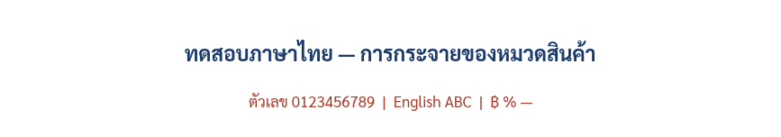

```
ถ้าอ่านข้อความด้านบนออก = ตั้งค่าฟอนต์สำเร็จ พร้อมรันต่อได้เลย
ถ้าเห็นเป็นสี่เหลี่ยม □□□ = ให้ Runtime > Restart session แล้ว Run all ใหม่
```

```python
# ── ตั้งค่ากราฟให้อ่านง่ายและสีสม่ำเสมอทั้งเล่ม ───────────────────
FAMILY = ([THAI_FONT] if THAI_FONT else []) + ["DejaVu Sans", "sans-serif"]

mpl.rcParams.update({
    "font.family":         FAMILY,
    "font.sans-serif":     FAMILY,
    "axes.unicode_minus":  False,
    "figure.figsize":      (9, 5),
    "figure.dpi":          110,
    "axes.grid":           True,
    "grid.alpha":          0.25,
    "axes.spines.top":     False,
    "axes.spines.right":   False,
    "font.size":           10.5,
})
C_MAIN, C_ALT, C_MUTE = "#1B3A6B", "#B03626", "#8B96A5"

# ── ทดสอบว่าฟอนต์ไทยขึ้นจริงหรือไม่ ────────────────────────────────
fig, ax = plt.subplots(figsize=(8, 1.5))
ax.text(.5, .62, "ทดสอบภาษาไทย — การกระจายของหมวดสินค้า",
        ha="center", va="center", fontsize=15, fontweight="bold", color=C_MAIN)
ax.text(.5, .22, "ตัวเลข 0123456789  |  English ABC  |  ฿ % —",
        ha="center", va="center", fontsize=11, color=C_ALT)
ax.axis("off"); ax.grid(False)
plt.tight_layout(); plt.show()

print("ถ้าอ่านข้อความด้านบนออก = ตั้งค่าฟอนต์สำเร็จ พร้อมรันต่อได้เลย")
print("ถ้าเห็นเป็นสี่เหลี่ยม □□□ = ให้ Runtime > Restart session แล้ว Run all ใหม่")
```

## 0.4 โหลดข้อมูล

ไฟล์ที่ต้องใช้: **`complaints_clean_150k.csv.gz`** (56 MB)

เลือกวิธีใดวิธีหนึ่ง:

| วิธี | ทำอย่างไร | เหมาะกับ |
| --- | --- | --- |
| **A. ลากไฟล์ใส่ Colab** | กดไอคอน 📁 ทางซ้าย → ลากไฟล์ `.gz` มาวาง | ใช้ครั้งเดียว จบ (ไฟล์หายเมื่อปิด Colab) |
| **B. Google Drive** | อัปโหลดไฟล์ขึ้น Drive → รันเซลล์แล้วกดอนุญาต | ใช้หลายครั้ง ไม่ต้องอัปใหม่ |

เซลล์ข้างล่างจะ **หาไฟล์ให้อัตโนมัติ** ทั้งสองที่ ถ้าไม่เจอจะเปิดหน้าต่างให้อัปโหลด

```python
CANDIDATE_PATHS = [
    "complaints_clean_150k.csv.gz",
    "/content/complaints_clean_150k.csv.gz",
    "/content/drive/MyDrive/complaints_clean_150k.csv.gz",
    "/content/drive/MyDrive/QE830/complaints_clean_150k.csv.gz",
    "complaints_clean_150k.csv",
    "/content/complaints_clean_150k.csv",
]

def locate_data():
    '''หาไฟล์ข้อมูลตามลำดับ: โฟลเดอร์ปัจจุบัน -> Drive -> ให้ผู้ใช้อัปโหลด'''
    for p in CANDIDATE_PATHS:
        if os.path.exists(p):
            return p
    # ลอง mount Google Drive
    try:
        from google.colab import drive
        if not os.path.exists("/content/drive"):
            print("ไม่พบไฟล์ในเครื่อง — กำลังเชื่อม Google Drive ...")
            drive.mount("/content/drive")
            for p in CANDIDATE_PATHS:
                if os.path.exists(p):
                    return p
    except Exception as e:
        print("ข้ามการเชื่อม Drive:", e)
    # สุดท้าย ให้อัปโหลดเอง
    try:
        from google.colab import files
        print("กรุณาเลือกไฟล์ complaints_clean_150k.csv.gz")
        up = files.upload()
        return list(up.keys())[0]
    except Exception:
        raise FileNotFoundError(
            "ไม่พบไฟล์ข้อมูล — วางไฟล์ complaints_clean_150k.csv.gz ไว้ข้างๆ notebook นี้")

DATA_PATH = locate_data()
print("ใช้ไฟล์:", DATA_PATH)

t0 = time.time()
df_raw = pd.read_csv(DATA_PATH, low_memory=False)
print(f"โหลดเสร็จใน {time.time()-t0:.1f} วินาที")
print("ขนาด:", df_raw.shape)
df_raw.head(3)
```

```
ใช้ไฟล์: complaints_clean_150k.csv.gz
โหลดเสร็จใน 8.5 วินาที
ขนาด: (150000, 12)
```

|  | Date received | Product | Sub-product | Issue | Sub-issue | Consumer complaint narrative | Company | State | Submitted via | Company response to consumer | Timely response? | Complaint ID |
| --- | --- | --- | --- | --- | --- | --- | --- | --- | --- | --- | --- | --- |
| 0 | 2023-01-01 | Credit reporting, credit repair services, or o... | Credit reporting | Unable to get your credit report or credit score | Problem getting your free annual credit report | tried to get my XXXX free credit reports onlin... | Experian Information Solutions Inc. | TX | Web | Closed with non-monetary relief | Yes | 6384792 |
| 1 | 2023-01-01 | Credit reporting, credit repair services, or o... | Credit reporting | Incorrect information on your report | Information belongs to someone else | Pursuant to 15 U.S. Code 1681c-2 - Block of in... | TRANSUNION INTERMEDIATE HOLDINGS, INC. | CA | Web | Closed with non-monetary relief | Yes | 6382174 |
| 2 | 2023-01-01 | Credit reporting, credit repair services, or o... | Credit reporting | Incorrect information on your report | Personal information incorrect | Ive recently obtained my current consumer repo... | Advanced Resolution Services Inc. | GA | Web | Closed with explanation | Yes | 6382260 |

# §1 · Business Understanding

## 1.1 บริบทของปัญหา

CFPB (Consumer Financial Protection Bureau) เป็นหน่วยงานรัฐบาลกลางสหรัฐฯ ที่รับเรื่องร้องเรียน จากประชาชนที่ถูกสถาบันการเงินเอาเปรียบ กระบวนการทำงานคือ

```
ประชาชนพิมพ์เล่าปัญหา  →  CFPB คัดกรองและจัดหมวด  →  ส่งเข้า Company Portal ของบริษัท
                                                        ↓
                                   บริษัทต้องตอบภายใน 15 วัน (สูงสุด 60 วัน)
```

**คอขวดอยู่ตรงขั้น "จัดหมวด"**

- ผู้ร้องเรียนต้องเลือกหมวดสินค้าจาก dropdown ที่ซ้อนกันหลายชั้นด้วยตัวเอง
- คนทั่วไปแยกไม่ออกว่า *Credit reporting* กับ *Credit repair services* ต่างกันตรงไหน → ติดหมวดผิดบ่อย
- เรื่องที่มาทางโทรศัพท์และไปรษณีย์ ต้องมีเจ้าหน้าที่ฟังแล้วติดหมวดให้เอง
- ฝั่งบริษัทที่รับเรื่องวันละหลายพันเรื่อง ต้องกระจายเข้าทีมย่อยอีกชั้น โดยไม่มีระบบอัตโนมัติ

**ผลกระทบ** — ทุกวันที่เรื่องนั่งผิดคิว คือวันที่หายไปจากโควตา 15 วันที่กฎหมายกำหนด เมื่อตอบไม่ทัน สถานะ *"Untimely response"* จะถูกบันทึกลงฐานข้อมูลสาธารณะให้ทุกคนเห็นตลอดไป

## 1.2 ผู้มีส่วนได้ส่วนเสีย

| ผู้มีส่วนได้เสีย | ได้อะไรจากระบบนี้ |
| --- | --- |
| ทีม Compliance ของธนาคาร | เรื่องเข้าทีมถูกต้องตั้งแต่แรก ไม่ต้องส่งต่อไปมา |
| ผู้ร้องเรียน | ได้คำตอบเร็วขึ้น จากคนที่รู้เรื่องนั้นจริง |
| หน่วยงานกำกับ | สถิติหมวดหมู่แม่นยำขึ้น ใช้เฝ้าระวังตลาดได้ดีขึ้น |
| ฝ่ายกฎหมาย | ลดความเสี่ยงถูกปรับจากการตอบไม่ทันกำหนด |

## 1.3 เกณฑ์ความสำเร็จ (วัดผลได้)

| # | เกณฑ์ | เป้าหมาย | วิธีวัด |
| --- | --- | --- | --- |
| SC-1 | ชนะ baseline อย่างมีนัยสำคัญ | Macro F1 ≥ 3 เท่าของ baseline | เทียบกับ `DummyClassifier` |
| SC-2 | ความแม่นยำโดยรวม | Accuracy ≥ 0.70 บนชุดทดสอบ | `accuracy_score` |
| SC-3 | ไม่ทิ้งหมวดเล็ก | ทุกหมวดมี F1 > 0.30 | per-class report |
| SC-4 | เร็วพอใช้งานจริง | ทำนาย 1 เรื่อง < 50 มิลลิวินาที | จับเวลา inference |
| SC-5 | อธิบายได้ | ระบุคำที่ทำให้ตัดสินใจได้ทุกหมวด | ดูค่าสัมประสิทธิ์ของโมเดล |
| SC-6 | ปลอดภัยพอส่งต่ออัตโนมัติ | ที่ความมั่นใจ ≥ 0.60 ต้องแม่น ≥ 0.85 | confidence–accuracy curve |

## 1.4 ต้นทุนของความผิดพลาด

โมเดลนี้ **ไม่ตัดสินใจแทนมนุษย์** แต่ *แนะนำ* หมวดให้ เพราะต้นทุนของความผิดพลาดไม่เท่ากัน

| กรณี | สิ่งที่เกิดขึ้น | ต้นทุน |
| --- | --- | --- |
| ทายถูก | เรื่องเข้าทีมถูกต้องทันที | ประหยัดเวลาคัดแยก |
| ทายผิด แต่คนตรวจเจอ | คนแก้หมวดก่อนส่ง | เสียเวลาเล็กน้อย |
| ทายผิด และส่งไปเลย | เรื่องนั่งผิดคิว | **กินโควตา 15 วัน → เสี่ยงถูกปรับ** |

→ จึงออกแบบให้มี **เกณฑ์ความมั่นใจ**: ถ้าโมเดลไม่มั่นใจพอ ให้ส่งเข้าคิวที่มีคนตรวจ

# §2 · Data Dictionary & ภาพรวมชุดข้อมูล

## 2.1 พจนานุกรมข้อมูล (Data Dictionary)

| คอลัมน์ | ชนิด | เกิดขึ้นในขั้นตอนใด | ใช้ในงานนี้ |
| --- | --- | --- | --- |
| `Date received` | วันที่ | CFPB รับเรื่อง | ใช้ดูแนวโน้มเวลาเท่านั้น |
| `Product` | Nominal (หมวด) | ผู้ร้องเลือกตอนกรอกฟอร์ม | 🎯 **Target** |
| `Sub-product` | Nominal | ผู้ร้องเลือก | ไม่ใช้ (ละเอียดเกินไป) |
| `Issue` | Nominal | ผู้ร้องเลือก | ไม่ใช้ (เป็น target ทางเลือก) |
| `Sub-issue` | Nominal | ผู้ร้องเลือก | ไม่ใช้ |
| `Consumer complaint narrative` | ข้อความอิสระ | ผู้ร้องพิมพ์เอง | ⭐ **Feature เดียวที่ใช้** |
| `Company` | Nominal | ผู้ร้องระบุ | ไม่ใช้ — เสี่ยง leakage |
| `State` | Nominal | ผู้ร้องระบุ | ไม่ใช้ |
| `Submitted via` | Nominal | ระบบบันทึก | ไม่ใช้ (ค่าเดียวทั้งชุด) |
| `Company response to consumer` | Nominal | **บริษัทตอบทีหลัง** | ❌ **ห้ามใช้ — เกิดหลังการทำนาย** |
| `Timely response?` | Binary | **บริษัทตอบทีหลัง** | ❌ **ห้ามใช้** |
| `Complaint ID` | ID | ระบบออกให้ | ไม่ใช้ |

> **หลักการสำคัญ — ป้องกัน Data Leakage** เราใช้ **เฉพาะข้อความ** เป็น feature เท่านั้น คอลัมน์ที่เกิด *หลัง* จุดที่เราต้องทำนาย (คำตอบของบริษัท) ห้ามนำมาใช้เด็ดขาด เพราะในโลกจริง ณ วินาทีที่ต้องจัดหมวด ข้อมูลเหล่านั้นยังไม่มี

```python
# ── ภาพรวมโครงสร้างข้อมูล ──────────────────────────────────────────
print("=" * 70)
print("โครงสร้างข้อมูล")
print("=" * 70)
print(f"จำนวนแถว    : {len(df_raw):,}")
print(f"จำนวนคอลัมน์ : {df_raw.shape[1]}")
print(f"หน่วยความจำ  : {df_raw.memory_usage(deep=True).sum()/1e6:,.0f} MB")

info = pd.DataFrame({
    "ชนิดข้อมูล": df_raw.dtypes.astype(str),
    "ค่าไม่ซ้ำ": df_raw.nunique(),
    "ค่าว่าง": df_raw.isna().sum(),
    "ค่าว่าง %": (df_raw.isna().mean() * 100).round(2),
})
info
```

```
======================================================================
โครงสร้างข้อมูล
======================================================================
จำนวนแถว    : 150,000
จำนวนคอลัมน์ : 12
หน่วยความจำ  : 301 MB
```

|  | ชนิดข้อมูล | ค่าไม่ซ้ำ | ค่าว่าง | ค่าว่าง % |
| --- | --- | --- | --- | --- |
| Date received | object | 1301 | 0 | 0.00 |
| Product | object | 14 | 0 | 0.00 |
| Sub-product | object | 57 | 0 | 0.00 |
| Issue | object | 90 | 0 | 0.00 |
| Sub-issue | object | 210 | 9333 | 6.22 |
| Consumer complaint narrative | object | 150000 | 0 | 0.00 |
| Company | object | 2081 | 0 | 0.00 |
| State | object | 60 | 497 | 0.33 |
| Submitted via | object | 1 | 0 | 0.00 |
| Company response to consumer | object | 5 | 0 | 0.00 |
| Timely response? | object | 2 | 0 | 0.00 |
| Complaint ID | int64 | 150000 | 0 | 0.00 |

```python
# ── ตรวจคุณภาพข้อความ: ซ้ำไหม ยาวแค่ไหน ──────────────────────────
NAR = "Consumer complaint narrative"
TGT = "Product"

nunq = df_raw[NAR].nunique()
print("=" * 70)
print("คุณภาพของข้อความ (คอลัมน์ที่เราจะใช้เป็น feature)")
print("=" * 70)
print(f"ข้อความไม่ซ้ำกัน : {nunq:,} จาก {len(df_raw):,} = {nunq/len(df_raw):.1%}")
print("   ถ้าใกล้ 100% แปลว่าเป็นข้อความที่คนเขียนจริง ไม่ใช่ template ที่ generate มา")

L = df_raw[NAR].astype(str).str.len()
print(f"\nความยาว (ตัวอักษร)")
print(f"  ต่ำสุด {L.min():,} | Q1 {L.quantile(.25):,.0f} | มัธยฐาน {L.median():,.0f} "
      f"| Q3 {L.quantile(.75):,.0f} | สูงสุด {L.max():,}")
print(f"  เฉลี่ย {L.mean():,.0f}")

W = df_raw[NAR].astype(str).str.split().str.len()
print(f"\nจำนวนคำ: เฉลี่ย {W.mean():.0f} | มัธยฐาน {W.median():.0f}")

# นับสัดส่วนข้อความที่มี XXXX (CFPB ปิดบังข้อมูลส่วนบุคคล)
has_x = df_raw[NAR].astype(str).str.contains(r"X{2,}", regex=True)
print(f"\nข้อความที่มีการปิดบังด้วย XXXX: {has_x.sum():,} ({has_x.mean():.1%})")
print("   -> ต้องจัดการในขั้น Data Preparation")
```

```
======================================================================
คุณภาพของข้อความ (คอลัมน์ที่เราจะใช้เป็น feature)
======================================================================
ข้อความไม่ซ้ำกัน : 150,000 จาก 150,000 = 100.0%
   ถ้าใกล้ 100% แปลว่าเป็นข้อความที่คนเขียนจริง ไม่ใช่ template ที่ generate มา

ความยาว (ตัวอักษร)
  ต่ำสุด 100 | Q1 456 | มัธยฐาน 859 | Q3 1,547 | สูงสุด 35,984
  เฉลี่ย 1,253

จำนวนคำ: เฉลี่ย 215 | มัธยฐาน 150

ข้อความที่มีการปิดบังด้วย XXXX: 125,320 (83.5%)
   -> ต้องจัดการในขั้น Data Preparation
```

```python
# ── การกระจายของ Target ────────────────────────────────────────────
vc = df_raw[TGT].value_counts()
print("=" * 70)
print(f"การกระจายของ Target: {TGT}  ({df_raw[TGT].nunique()} หมวด)")
print("=" * 70)
tbl = pd.DataFrame({"จำนวน": vc, "สัดส่วน %": (vc / len(df_raw) * 100).round(2)})
display(tbl)

imb = vc.max() / vc.min()
print(f"\nอัตราส่วนหมวดใหญ่สุด : หมวดเล็กสุด = {imb:,.0f} : 1")
print(f"หมวดใหญ่สุดกินสัดส่วน {vc.max()/len(df_raw):.1%} ของข้อมูลทั้งหมด")
print("\n=> ข้อมูลไม่สมดุลอย่างรุนแรง (severe class imbalance)")
print("   ผลที่ตามมา: ใช้ Accuracy วัดผลอย่างเดียวไม่ได้ ต้องดู Macro F1 ด้วย")
```

```
======================================================================
การกระจายของ Target: Product  (14 หมวด)
======================================================================
```

| Product | จำนวน | สัดส่วน % |
| --- | --- | --- |
| Credit reporting or other personal consumer reports | 81498 | 54.33 |
| Debt collection | 15915 | 10.61 |
| Credit reporting, credit repair services, or other personal consumer reports | 14738 | 9.83 |
| Checking or savings account | 10281 | 6.85 |
| Credit card | 8374 | 5.58 |
| Money transfer, virtual currency, or money service | 5830 | 3.89 |
| Mortgage | 3865 | 2.58 |
| Vehicle loan or lease | 2537 | 1.69 |
| Student loan | 2391 | 1.59 |
| Payday loan, title loan, personal loan, or advance loan | 1545 | 1.03 |
| Credit card or prepaid card | 1544 | 1.03 |
| Prepaid card | 836 | 0.56 |
| Debt or credit management | 415 | 0.28 |
| Payday loan, title loan, or personal loan | 231 | 0.15 |

```
อัตราส่วนหมวดใหญ่สุด : หมวดเล็กสุด = 353 : 1
หมวดใหญ่สุดกินสัดส่วน 54.3% ของข้อมูลทั้งหมด

=> ข้อมูลไม่สมดุลอย่างรุนแรง (severe class imbalance)
   ผลที่ตามมา: ใช้ Accuracy วัดผลอย่างเดียวไม่ได้ ต้องดู Macro F1 ด้วย
```

# §3 · Data Understanding / EDA

## 3.1 กราฟที่ 1 — การกระจายของหมวดสินค้า

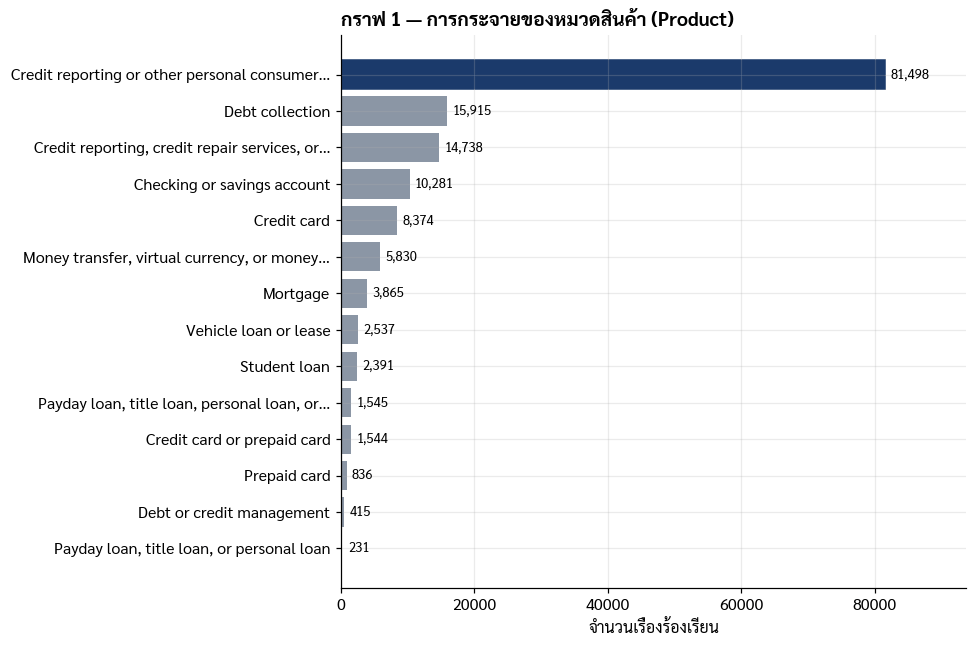

```
อ่านกราฟ: หมวด Credit reporting กินสัดส่วนมหาศาลจนหมวดอื่นแทบมองไม่เห็น
สังเกต: มีสองหมวดที่ชื่อคล้ายกันมาก -> จะจัดการในขั้น Data Preparation
```

```python
fig, ax = plt.subplots(figsize=(9, 6))
d = vc.sort_values()
lbl = [textwrap.shorten(s, 46, placeholder="…") for s in d.index]
bars = ax.barh(lbl, d.values, color=C_MUTE)
bars[-1].set_color(C_MAIN)
for b, v in zip(bars, d.values):
    ax.text(v + d.max()*0.01, b.get_y() + b.get_height()/2,
            f"{v:,}", va="center", fontsize=8.5)
ax.set_xlabel("จำนวนเรื่องร้องเรียน")
ax.set_title("กราฟ 1 — การกระจายของหมวดสินค้า (Product)", loc="left", fontweight="bold")
ax.set_xlim(0, d.max() * 1.15)
plt.tight_layout(); plt.show()

print("อ่านกราฟ: หมวด Credit reporting กินสัดส่วนมหาศาลจนหมวดอื่นแทบมองไม่เห็น")
print("สังเกต: มีสองหมวดที่ชื่อคล้ายกันมาก -> จะจัดการในขั้น Data Preparation")
```

## 3.2 กราฟที่ 2 — ความยาวของข้อความ

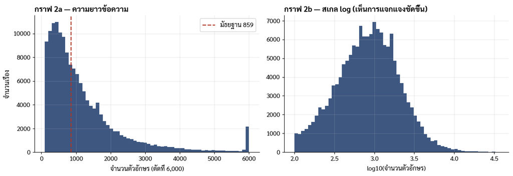

```
เบ้ขวา (right-skewed): เฉลี่ย 1,253 > มัธยฐาน 859
แปลว่ามีข้อความยาวมากอยู่จำนวนหนึ่งที่ดึงค่าเฉลี่ยขึ้น
=> ในขั้น Modeling จะใช้ sublinear_tf=True เพื่อลดอิทธิพลของข้อความยาว
```

```python
fig, axes = plt.subplots(1, 2, figsize=(12, 4.2))

axes[0].hist(L.clip(upper=6000), bins=60, color=C_MAIN, alpha=.85)
axes[0].axvline(L.median(), color=C_ALT, ls="--", lw=1.6,
                label=f"มัธยฐาน {L.median():,.0f}")
axes[0].set_xlabel("จำนวนตัวอักษร (ตัดที่ 6,000)")
axes[0].set_ylabel("จำนวนเรื่อง")
axes[0].set_title("กราฟ 2a — ความยาวข้อความ", loc="left", fontweight="bold")
axes[0].legend()

axes[1].hist(np.log10(L.clip(lower=1)), bins=60, color=C_MAIN, alpha=.85)
axes[1].set_xlabel("log10(จำนวนตัวอักษร)")
axes[1].set_title("กราฟ 2b — สเกล log (เห็นการแจกแจงชัดขึ้น)",
                  loc="left", fontweight="bold")
plt.tight_layout(); plt.show()

print(f"เบ้ขวา (right-skewed): เฉลี่ย {L.mean():,.0f} > มัธยฐาน {L.median():,.0f}")
print("แปลว่ามีข้อความยาวมากอยู่จำนวนหนึ่งที่ดึงค่าเฉลี่ยขึ้น")
print("=> ในขั้น Modeling จะใช้ sublinear_tf=True เพื่อลดอิทธิพลของข้อความยาว")
```

## 3.3 กราฟที่ 3 — ความยาวข้อความแยกตามหมวด

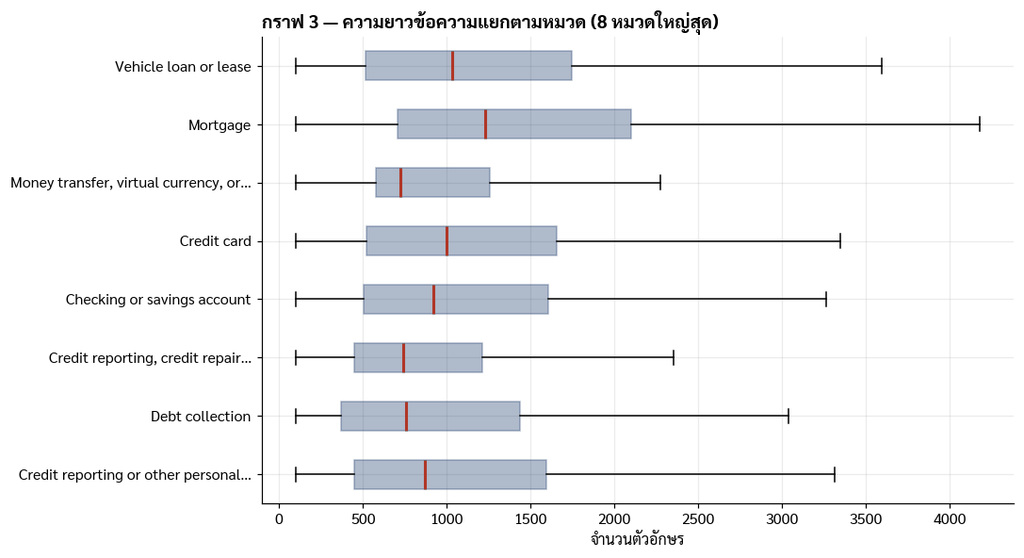

```
ถ้ากล่องของแต่ละหมวดอยู่คนละตำแหน่ง แปลว่าความยาวเองก็เป็นสัญญาณอย่างหนึ่ง
แต่เราจะไม่ใช้ความยาวเป็น feature ตรงๆ เพราะต้องการพิสูจน์ว่า 'เนื้อหา' ทำนายได้
```

```python
top8 = vc.head(8).index.tolist()
data = [df_raw.loc[df_raw[TGT] == c, NAR].astype(str).str.len().clip(upper=6000).values
        for c in top8]

fig, ax = plt.subplots(figsize=(10, 5.5))
bp = ax.boxplot(data, vert=False, showfliers=False, patch_artist=True,
                labels=[textwrap.shorten(c, 40, placeholder="…") for c in top8])
for p in bp["boxes"]:
    p.set_facecolor(C_MAIN); p.set_alpha(.35); p.set_edgecolor(C_MAIN)
for m in bp["medians"]:
    m.set_color(C_ALT); m.set_linewidth(2)
ax.set_xlabel("จำนวนตัวอักษร")
ax.set_title("กราฟ 3 — ความยาวข้อความแยกตามหมวด (8 หมวดใหญ่สุด)",
             loc="left", fontweight="bold")
plt.tight_layout(); plt.show()

print("ถ้ากล่องของแต่ละหมวดอยู่คนละตำแหน่ง แปลว่าความยาวเองก็เป็นสัญญาณอย่างหนึ่ง")
print("แต่เราจะไม่ใช้ความยาวเป็น feature ตรงๆ เพราะต้องการพิสูจน์ว่า 'เนื้อหา' ทำนายได้")
```

## 3.4 กราฟที่ 4 — แนวโน้มตามเวลา

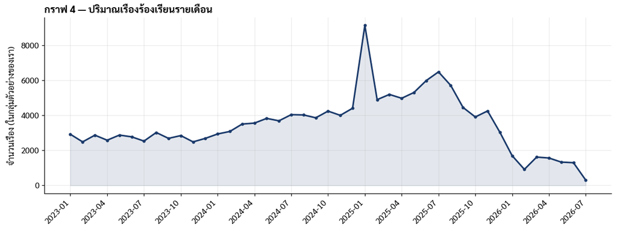

```
แยกตามปี: {2023: 32768, 2024: 45170, 2025: 63318, 2026: 8744}

ข้อควรระวัง: ถ้าปริมาณและลักษณะภาษาเปลี่ยนตามเวลา -> เกิด data drift
โมเดลที่เทรนวันนี้จะแม่นน้อยลงเรื่อยๆ ในอนาคต (จะพูดถึงในขั้น Deployment)
```

```python
dt = pd.to_datetime(df_raw["Date received"], errors="coerce")
monthly = dt.dt.to_period("M").value_counts().sort_index()
monthly = monthly[monthly.index.astype(str) >= "2023-01"]

fig, ax = plt.subplots(figsize=(11, 4.2))
ax.plot(monthly.index.astype(str), monthly.values, color=C_MAIN, lw=2, marker="o", ms=3)
ax.fill_between(range(len(monthly)), monthly.values, alpha=.12, color=C_MAIN)
ax.set_xticks(range(0, len(monthly), 3))
ax.set_xticklabels([str(x) for x in monthly.index[::3]], rotation=45, ha="right")
ax.set_ylabel("จำนวนเรื่อง (ในกลุ่มตัวอย่างของเรา)")
ax.set_title("กราฟ 4 — ปริมาณเรื่องร้องเรียนรายเดือน", loc="left", fontweight="bold")
plt.tight_layout(); plt.show()

yr = dt.dt.year.value_counts().sort_index()
print("แยกตามปี:", {int(k): int(v) for k, v in yr.items()})
print("\nข้อควรระวัง: ถ้าปริมาณและลักษณะภาษาเปลี่ยนตามเวลา -> เกิด data drift")
print("โมเดลที่เทรนวันนี้จะแม่นน้อยลงเรื่อยๆ ในอนาคต (จะพูดถึงในขั้น Deployment)")
```

## 3.5 กราฟที่ 5 และ 6 — บริษัทและรัฐ

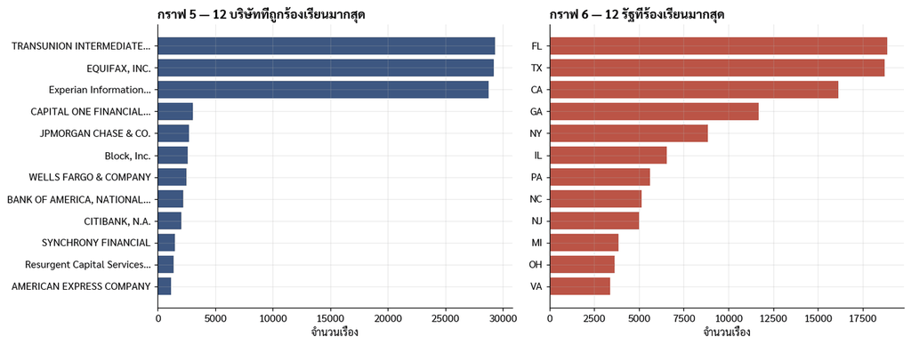

```
บริษัทอันดับต้นๆ เป็นเครดิตบูโรทั้งหมด สอดคล้องกับหมวดที่ใหญ่ที่สุด
=> ถ้าเอา Company มาเป็น feature จะเกิด leakage ทันที (บริษัทบอกหมวดได้เกือบสมบูรณ์)
   นี่คือเหตุผลที่เราตัดคอลัมน์นี้ทิ้ง
```

```python
fig, axes = plt.subplots(1, 2, figsize=(13, 5))

co = df_raw["Company"].value_counts().head(12).sort_values()
axes[0].barh([textwrap.shorten(s, 30, placeholder="…") for s in co.index],
             co.values, color=C_MAIN, alpha=.85)
axes[0].set_title("กราฟ 5 — 12 บริษัทที่ถูกร้องเรียนมากสุด",
                  loc="left", fontweight="bold")
axes[0].set_xlabel("จำนวนเรื่อง")

st = df_raw["State"].value_counts().head(12).sort_values()
axes[1].barh(st.index, st.values, color=C_ALT, alpha=.85)
axes[1].set_title("กราฟ 6 — 12 รัฐที่ร้องเรียนมากสุด", loc="left", fontweight="bold")
axes[1].set_xlabel("จำนวนเรื่อง")

plt.tight_layout(); plt.show()

print("บริษัทอันดับต้นๆ เป็นเครดิตบูโรทั้งหมด สอดคล้องกับหมวดที่ใหญ่ที่สุด")
print("=> ถ้าเอา Company มาเป็น feature จะเกิด leakage ทันที (บริษัทบอกหมวดได้เกือบสมบูรณ์)")
print("   นี่คือเหตุผลที่เราตัดคอลัมน์นี้ทิ้ง")
```

## 3.6 กราฟที่ 7 — ค่าว่างในแต่ละคอลัมน์

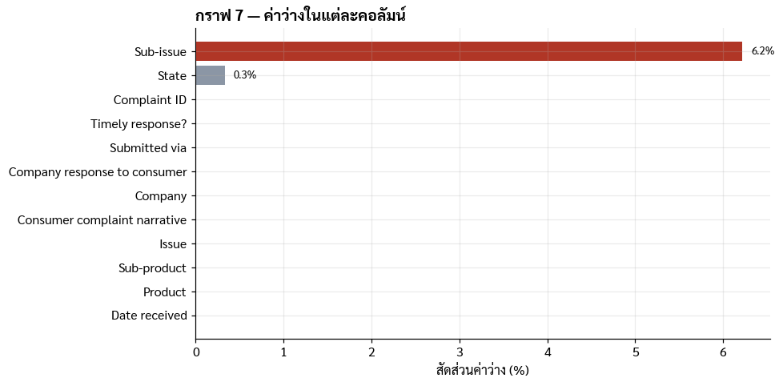

```
คอลัมน์ที่เราจะใช้จริง (narrative และ Product) ไม่มีค่าว่างเลย
เพราะเรากรองไว้แล้วตอนเตรียมไฟล์จากต้นฉบับ 8.7 GB
```

```python
miss = (df_raw.isna().mean() * 100).sort_values()
fig, ax = plt.subplots(figsize=(9, 4.5))
cols = [C_ALT if v > 1 else C_MUTE for v in miss.values]
ax.barh(miss.index, miss.values, color=cols)
for i, v in enumerate(miss.values):
    if v > 0.01:
        ax.text(v + .1, i, f"{v:.1f}%", va="center", fontsize=8.5)
ax.set_xlabel("สัดส่วนค่าว่าง (%)")
ax.set_title("กราฟ 7 — ค่าว่างในแต่ละคอลัมน์", loc="left", fontweight="bold")
plt.tight_layout(); plt.show()

print("คอลัมน์ที่เราจะใช้จริง (narrative และ Product) ไม่มีค่าว่างเลย")
print("เพราะเรากรองไว้แล้วตอนเตรียมไฟล์จากต้นฉบับ 8.7 GB")
```

## 3.7 สรุปข้อค้นพบจาก EDA

[output not shown]

# §4 · Data Preparation

## 4.1 กฎการเตรียมข้อมูล

| กฎ | สิ่งที่ทำ | เหตุผล |
| --- | --- | --- |
| **R1** | เก็บเฉพาะ 2 คอลัมน์: narrative และ Product | ป้องกัน data leakage ตั้งแต่ต้นทาง |
| **R2** | ลบข้อความที่ซ้ำกันทุกประการ | กันไม่ให้ข้อความเดียวกันอยู่ทั้ง train และ test |
| **R3** | ลบเครื่องหมายปิดบัง `XXXX` | ไม่มีความหมาย และกินพื้นที่ feature |
| **R4** | แปลงเป็นตัวพิมพ์เล็ก ตัดอักขระพิเศษและตัวเลข | ลดขนาดคลังคำ ให้ `Bank` = `bank` |
| **R5** | ตัดข้อความสั้นกว่า 100 ตัวอักษร | ข้อความสั้นไม่มีสัญญาณพอให้จำแนก |
| **R6** | **รวมหมวดที่เป็นชื่อเดียวกันแต่คนละยุค** | CFPB เปลี่ยนชื่อหมวดในปี 2023 |
| **R7** | ตัดหมวดที่มีน้อยกว่า 300 ตัวอย่าง | น้อยเกินไปจนวัดผลไม่น่าเชื่อถือ |
| **R8** | แบ่ง train/test แบบ stratified 80:20 | ให้สัดส่วนหมวดในสองชุดเท่ากัน |

> **R6 คือขั้นตอนที่สำคัญที่สุด** — ในข้อมูลมีคู่หมวดที่แทบเป็นอันเดียวกัน เช่น `Credit reporting, credit repair services, or other personal consumer reports` (ชื่อเก่า) กับ `Credit reporting or other personal consumer reports` (ชื่อใหม่) ถ้าไม่รวม โมเดลจะถูกบังคับให้แยกสิ่งที่แยกไม่ได้ ทำให้คะแนนต่ำกว่าความจริง

```python
# ── R6: แผนที่รวมหมวดที่ซ้ำซ้อน ───────────────────────────────────
MERGE_MAP = {
    "Credit reporting, credit repair services, or other personal consumer reports":
        "Credit reporting",
    "Credit reporting or other personal consumer reports":
        "Credit reporting",
    "Credit card": "Credit card / Prepaid card",
    "Prepaid card": "Credit card / Prepaid card",
    "Credit card or prepaid card": "Credit card / Prepaid card",
    "Payday loan, title loan, or personal loan":
        "Payday / title / personal loan",
    "Payday loan, title loan, personal loan, or advance loan":
        "Payday / title / personal loan",
    "Money transfer, virtual currency, or money service":
        "Money transfer / crypto",
    "Money transfers": "Money transfer / crypto",
    "Checking or savings account": "Checking / savings account",
    "Bank account or service": "Checking / savings account",
    "Vehicle loan or lease": "Vehicle loan / lease",
    "Consumer Loan": "Vehicle loan / lease",
}

print("ก่อนรวม:", df_raw[TGT].nunique(), "หมวด")
tmp = df_raw[TGT].replace(MERGE_MAP)
print("หลังรวม:", tmp.nunique(), "หมวด\n")
print(tmp.value_counts().to_string())
```

```
ก่อนรวม: 14 หมวด
หลังรวม: 10 หมวด

Product
Credit reporting                  96236
Debt collection                   15915
Credit card / Prepaid card        10754
Checking / savings account        10281
Money transfer / crypto            5830
Mortgage                           3865
Vehicle loan / lease               2537
Student loan                       2391
Payday / title / personal loan     1776
Debt or credit management           415
```

```python
# ── ฟังก์ชันทำความสะอาดข้อความ (R3, R4) ───────────────────────────
RE_MASK  = re.compile(r"\bX{2,}\b|X{4,}")      # XXXX ที่ CFPB ใช้ปิดบัง
RE_URL   = re.compile(r"http\S+|www\.\S+")
RE_NUM   = re.compile(r"\d+")
RE_PUNCT = re.compile(r"[^a-z\s]")
RE_SPACE = re.compile(r"\s+")

def clean_text(s):
    '''ลบการปิดบัง ลิงก์ ตัวเลข และอักขระพิเศษ แล้วบีบช่องว่างให้เหลือช่องเดียว'''
    s = str(s)
    s = RE_MASK.sub(" ", s)
    s = s.lower()
    s = RE_URL.sub(" ", s)
    s = RE_NUM.sub(" ", s)
    s = RE_PUNCT.sub(" ", s)
    return RE_SPACE.sub(" ", s).strip()

# ตัวอย่างก่อน-หลัง
ex = df_raw[NAR].iloc[0]
print("ก่อนทำความสะอาด:")
print(textwrap.fill(str(ex)[:400], 90))
print("\nหลังทำความสะอาด:")
print(textwrap.fill(clean_text(ex)[:400], 90))
```

```
ก่อนทำความสะอาด:
tried to get my XXXX free credit reports online on ( the date you tried to get your credit
reports ) and was unsuccessful at getting my credit reports/ files. It's very inconvenient
for me and I need them as soon as as possible.

หลังทำความสะอาด:
tried to get my free credit reports online on the date you tried to get your credit
reports and was unsuccessful at getting my credit reports files it s very inconvenient for
me and i need them as soon as as possible
```

```python
# ── ประกอบร่างขั้น Data Preparation ทั้งหมด ────────────────────────
log = []
def step(name, df):
    log.append({"ขั้นตอน": name, "จำนวนแถว": len(df),
                "จำนวนหมวด": df[TGT].nunique() if TGT in df else None})
    return df

t0 = time.time()

df = df_raw[[NAR, TGT]].copy()
step("0. ข้อมูลตั้งต้น", df)                                          # R1

df = df.dropna(subset=[NAR, TGT])
step("1. ตัดแถวที่มีค่าว่าง", df)

df = df.drop_duplicates(subset=[NAR])
step("2. ตัดข้อความซ้ำ (R2)", df)

df[TGT] = df[TGT].replace(MERGE_MAP)
step("3. รวมหมวดซ้ำซ้อน (R6)", df)

df["text"] = df[NAR].map(clean_text)                                  # R3, R4
step("4. ทำความสะอาดข้อความ (R3, R4)", df)

df = df[df["text"].str.len() >= MIN_CHARS]                            # R5
step("5. ตัดข้อความสั้นเกินไป (R5)", df)

keep = df[TGT].value_counts()
keep = keep[keep >= MIN_CLASS_N].index
df = df[df[TGT].isin(keep)]                                           # R7
step("6. ตัดหมวดที่ตัวอย่างน้อย (R7)", df)

if SAMPLE_N and len(df) > SAMPLE_N:
    df = df.groupby(TGT, group_keys=False).apply(
        lambda g: g.sample(max(1, int(round(SAMPLE_N * len(g) / len(df)))),
                           random_state=RANDOM_STATE))
    step("7. สุ่มตัวอย่างเพื่อความเร็ว", df)

df = df.reset_index(drop=True)
print(f"ใช้เวลา {time.time()-t0:.1f} วินาที\n")
display(pd.DataFrame(log))
print(f"\nข้อมูลสุดท้าย: {len(df):,} แถว | {df[TGT].nunique()} หมวด")
```

```
ใช้เวลา 37.3 วินาที
```

|  | ขั้นตอน | จำนวนแถว | จำนวนหมวด |
| --- | --- | --- | --- |
| 0 | 0. ข้อมูลตั้งต้น | 150000 | 14 |
| 1 | 1. ตัดแถวที่มีค่าว่าง | 150000 | 14 |
| 2 | 2. ตัดข้อความซ้ำ (R2) | 150000 | 14 |
| 3 | 3. รวมหมวดซ้ำซ้อน (R6) | 150000 | 10 |
| 4 | 4. ทำความสะอาดข้อความ (R3, R4) | 150000 | 10 |
| 5 | 5. ตัดข้อความสั้นเกินไป (R5) | 148410 | 10 |
| 6 | 6. ตัดหมวดที่ตัวอย่างน้อย (R7) | 148410 | 10 |
| 7 | 7. สุ่มตัวอย่างเพื่อความเร็ว | 60000 | 10 |

```
ข้อมูลสุดท้าย: 60,000 แถว | 10 หมวด
```

## 4.2 กราฟที่ 8 — เปรียบเทียบหมวดก่อนและหลังรวม

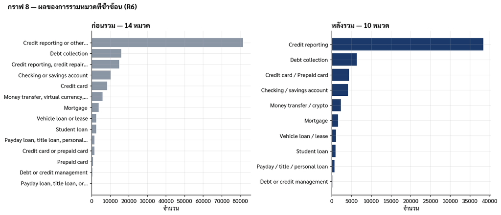

```
อัตราส่วนความไม่สมดุล: 353:1  ->  231:1
```

```python
before = df_raw[TGT].value_counts()
after  = df[TGT].value_counts()

fig, axes = plt.subplots(1, 2, figsize=(13, 5.5))

b = before.sort_values()
axes[0].barh([textwrap.shorten(s, 34, placeholder="…") for s in b.index],
             b.values, color=C_MUTE)
axes[0].set_title(f"ก่อนรวม — {len(before)} หมวด", loc="left", fontweight="bold")
axes[0].set_xlabel("จำนวน")

a = after.sort_values()
axes[1].barh([textwrap.shorten(s, 34, placeholder="…") for s in a.index],
             a.values, color=C_MAIN)
axes[1].set_title(f"หลังรวม — {len(after)} หมวด", loc="left", fontweight="bold")
axes[1].set_xlabel("จำนวน")

fig.suptitle("กราฟ 8 — ผลของการรวมหมวดที่ซ้ำซ้อน (R6)",
             fontweight="bold", x=.02, ha="left", y=1.0)
plt.tight_layout(); plt.show()

print(f"อัตราส่วนความไม่สมดุล: {before.max()/before.min():,.0f}:1  ->  "
      f"{after.max()/after.min():,.0f}:1")
```

## 4.3 แบ่งชุดฝึกและชุดทดสอบ (R8)

ใช้ `stratify=y` เพื่อให้สัดส่วนของแต่ละหมวดในชุด train และ test เท่ากัน ถ้าไม่ทำ หมวดเล็กอาจไม่ปรากฏในชุดทดสอบเลย ทำให้วัดผลไม่ได้

```python
X = df["text"]
y = df[TGT]

X_train, X_test, y_train, y_test = train_test_split(
    X, y, test_size=TEST_SIZE, random_state=RANDOM_STATE, stratify=y)

print(f"ชุดฝึก   : {len(X_train):,} แถว")
print(f"ชุดทดสอบ : {len(X_test):,} แถว\n")

chk = pd.DataFrame({
    "train %": (y_train.value_counts(normalize=True) * 100).round(2),
    "test %":  (y_test.value_counts(normalize=True) * 100).round(2),
})
chk["ต่างกัน"] = (chk["train %"] - chk["test %"]).abs().round(3)
display(chk.sort_values("train %", ascending=False))
print("\nคอลัมน์ 'ต่างกัน' ควรใกล้ 0 ทุกแถว = การแบ่งแบบ stratified ทำงานถูกต้อง")
```

```
ชุดฝึก   : 48,000 แถว
ชุดทดสอบ : 12,000 แถว
```

| Product | train % | test % | ต่างกัน |
| --- | --- | --- | --- |
| Credit reporting | 63.97 | 63.98 | 0.01 |
| Debt collection | 10.64 | 10.63 | 0.01 |
| Credit card / Prepaid card | 7.22 | 7.22 | 0.00 |
| Checking / savings account | 6.90 | 6.90 | 0.00 |
| Money transfer / crypto | 3.91 | 3.91 | 0.00 |
| Mortgage | 2.60 | 2.59 | 0.01 |
| Vehicle loan / lease | 1.70 | 1.71 | 0.01 |
| Student loan | 1.60 | 1.61 | 0.01 |
| Payday / title / personal loan | 1.19 | 1.18 | 0.01 |
| Debt or credit management | 0.28 | 0.27 | 0.01 |

```
คอลัมน์ 'ต่างกัน' ควรใกล้ 0 ทุกแถว = การแบ่งแบบ stratified ทำงานถูกต้อง
```

## 4.4 TF-IDF — แปลงข้อความเป็นตัวเลข

โมเดลอ่านตัวหนังสือไม่ได้ ต้องแปลงเป็นตัวเลขก่อน

**TF-IDF = Term Frequency × Inverse Document Frequency**

- **TF** — คำนี้โผล่ในเรื่องนี้บ่อยแค่ไหน (บ่อย = สำคัญ)
- **IDF** — คำนี้โผล่ในกี่เรื่องจากทั้งหมด (โผล่ทุกที่ = ไม่มีประโยชน์ ลดน้ำหนัก)

ผลคือคำอย่าง `the`, `account` ที่มีในทุกเรื่องจะได้น้ำหนักต่ำ ส่วนคำอย่าง `overdraft`, `repossess`, `forbearance` ที่โผล่เฉพาะบางหมวดจะได้น้ำหนักสูง

| พารามิเตอร์ | ค่าที่ตั้ง | เหตุผล |
| --- | --- | --- |
| `ngram_range` | `(1, 2)` | เก็บทั้งคำเดี่ยวและคู่คำ — `credit report` มีความหมายต่างจาก `credit` |
| `min_df` | `3` | ตัดคำที่โผล่น้อยกว่า 3 เอกสาร (คำสะกดผิด) — กัน overfit |
| `max_df` | `0.85` | ตัดคำที่โผล่เกิน 85% ของเอกสาร (เหมือน stop words แต่หาเองจากข้อมูล) |
| `sublinear_tf` | `True` | ใช้ `1+log(TF)` — แก้ปัญหาข้อความยาวจากข้อค้นพบ F-4 |
| `stop_words` | `"english"` | ตัดคำเชื่อมภาษาอังกฤษ |
| `max_features` | `150000` | จำกัดขนาดคลังคำให้พอดีกับหน่วยความจำของ Colab |

```python
TFIDF_PARAMS = dict(
    ngram_range=(1, 2),
    min_df=3,
    max_df=0.85,
    sublinear_tf=True,
    stop_words="english",
    max_features=150_000,
)

# ── ทดลองแปลงเพื่อดูขนาดเมทริกซ์ที่ได้ ────────────────────────────
t0 = time.time()
demo_vec = TfidfVectorizer(**TFIDF_PARAMS)
Xtr_demo = demo_vec.fit_transform(X_train)

print(f"เวลาแปลง : {time.time()-t0:.1f} วินาที")
print(f"ขนาดเมทริกซ์ : {Xtr_demo.shape[0]:,} แถว x {Xtr_demo.shape[1]:,} คอลัมน์")
dens = Xtr_demo.nnz / (Xtr_demo.shape[0] * Xtr_demo.shape[1])
print(f"ช่องที่ไม่ใช่ศูนย์ : {Xtr_demo.nnz:,} ({dens:.4%})")
print(f"หน่วยความจำจริง : {Xtr_demo.data.nbytes/1e6:.0f} MB")
print(f"ถ้าเก็บแบบ dense จะใช้ : "
      f"{Xtr_demo.shape[0]*Xtr_demo.shape[1]*8/1e9:,.0f} GB  <-- เก็บไม่ไหว")
print("\n=> นี่คือเหตุผลที่ต้องใช้ sparse matrix")

# ดูคำที่ IDF สูงสุดและต่ำสุด
idf = pd.Series(demo_vec.idf_, index=demo_vec.get_feature_names_out())
print("\nคำที่ IDF ต่ำสุด (เจอแทบทุกเรื่อง จึงไม่ช่วยแยกหมวด):")
print("   ", ", ".join(idf.nsmallest(12).index.tolist()))
```

```
เวลาแปลง : 16.1 วินาที
ขนาดเมทริกซ์ : 48,000 แถว x 150,000 คอลัมน์
ช่องที่ไม่ใช่ศูนย์ : 5,563,740 (0.0773%)
หน่วยความจำจริง : 45 MB
ถ้าเก็บแบบ dense จะใช้ : 58 GB  <-- เก็บไม่ไหว

=> นี่คือเหตุผลที่ต้องใช้ sparse matrix

คำที่ IDF ต่ำสุด (เจอแทบทุกเรื่อง จึงไม่ช่วยแยกหมวด):
    credit, report, account, information, reporting, credit report, consumer, accounts, credit reporting, act, fair, inaccurate
```

# §5 · Data Modeling

## 5.1 โมเดลที่นำมาเปรียบเทียบ

| # | โมเดล | ประเภท | เหตุผลที่เลือก |
| --- | --- | --- | --- |
| 0 | **DummyClassifier** | Baseline | เดาหมวดที่พบบ่อยที่สุดเสมอ — ทุกโมเดลต้องชนะตัวนี้ให้ได้ |
| 1 | **Logistic Regression** | เชิงเส้น | มาตรฐานของงาน text classification · อธิบายได้ · ให้ค่าความน่าจะเป็น |
| 2 | **Linear SVM** | เชิงเส้น | มักได้คะแนนสูงสุดกับข้อมูล sparse มิติสูง |
| 3 | **Complement Naive Bayes** | ความน่าจะเป็น | ออกแบบมาเพื่อข้อมูลไม่สมดุลโดยเฉพาะ · เร็วมาก |
| 4 | **Random Forest** | ต้นไม้ | ตัวแทนกลุ่ม non-linear เพื่อเทียบว่าความซับซ้อนช่วยไหม |

ทุกโมเดลห่อด้วย `Pipeline` เพื่อให้ TF-IDF **fit เฉพาะกับชุด train เท่านั้น** ถ้า fit กับข้อมูลทั้งหมดก่อนแบ่ง จะเกิด data leakage เพราะโมเดลได้เห็นคลังคำของชุดทดสอบ

```python
MODELS = {
    "0. Baseline (Dummy)": Pipeline([
        ("clf", DummyClassifier(strategy="most_frequent")),
    ]),
    "1. TF-IDF + LogisticRegression": Pipeline([
        ("tfidf", TfidfVectorizer(**TFIDF_PARAMS)),
        ("clf", LogisticRegression(max_iter=1500, class_weight="balanced",
                                   random_state=RANDOM_STATE, n_jobs=-1)),
    ]),
    "2. TF-IDF + LinearSVM": Pipeline([
        ("tfidf", TfidfVectorizer(**TFIDF_PARAMS)),
        ("clf", LinearSVC(class_weight="balanced", random_state=RANDOM_STATE)),
    ]),
    "3. TF-IDF + ComplementNB": Pipeline([
        ("tfidf", TfidfVectorizer(**TFIDF_PARAMS)),
        ("clf", ComplementNB(alpha=0.3)),
    ]),
    "4. TF-IDF + RandomForest": Pipeline([
        ("tfidf", TfidfVectorizer(**{**TFIDF_PARAMS, "max_features": 20_000})),
        ("clf", RandomForestClassifier(n_estimators=200, min_samples_leaf=2,
                                       class_weight="balanced_subsample",
                                       random_state=RANDOM_STATE, n_jobs=-1)),
    ]),
}

for k in MODELS:
    print(" ", k)
```

```
  0. Baseline (Dummy)
  1. TF-IDF + LogisticRegression
  2. TF-IDF + LinearSVM
  3. TF-IDF + ComplementNB
  4. TF-IDF + RandomForest
```

## 5.2 ฝึกและวัดผลทุกโมเดล

> เซลล์นี้ใช้เวลาประมาณ 3–8 นาทีบน Colab (Random Forest ช้าที่สุด)

```python
results, fitted = [], {}

for name, pipe in MODELS.items():
    print(f"กำลังฝึก {name} ...", end=" ", flush=True)
    t0 = time.time()
    pipe.fit(X_train, y_train)
    t_fit = time.time() - t0

    t0 = time.time()
    y_pred = pipe.predict(X_test)
    t_pred = time.time() - t0

    results.append({
        "โมเดล": name,
        "Accuracy": accuracy_score(y_test, y_pred),
        "Macro F1": f1_score(y_test, y_pred, average="macro", zero_division=0),
        "Weighted F1": f1_score(y_test, y_pred, average="weighted", zero_division=0),
        "Macro Precision": precision_score(y_test, y_pred, average="macro", zero_division=0),
        "Macro Recall": recall_score(y_test, y_pred, average="macro", zero_division=0),
        "เวลาฝึก (วิ)": round(t_fit, 1),
        "ms/เรื่อง": round(t_pred / len(X_test) * 1000, 3),
    })
    fitted[name] = pipe
    print(f"เสร็จใน {t_fit:.0f} วินาที")

res = pd.DataFrame(results).set_index("โมเดล")
display(res.style.format({
    "Accuracy": "{:.4f}", "Macro F1": "{:.4f}", "Weighted F1": "{:.4f}",
    "Macro Precision": "{:.4f}", "Macro Recall": "{:.4f}",
}).background_gradient(subset=["Macro F1"], cmap="Blues"))
```

```
กำลังฝึก 0. Baseline (Dummy) ... เสร็จใน 0 วินาที
กำลังฝึก 1. TF-IDF + LogisticRegression ... เสร็จใน 64 วินาที
กำลังฝึก 2. TF-IDF + LinearSVM ... เสร็จใน 28 วินาที
กำลังฝึก 3. TF-IDF + ComplementNB ... เสร็จใน 16 วินาที
กำลังฝึก 4. TF-IDF + RandomForest ... เสร็จใน 268 วินาที
```

| โมเดล | Accuracy | Macro F1 | Weighted F1 | Macro Precision | Macro Recall | เวลาฝึก (วิ) | ms/เรื่อง |
| --- | --- | --- | --- | --- | --- | --- | --- |
| 0. Baseline (Dummy) | 0.6398 | 0.0780 | 0.4992 | 0.0640 | 0.1000 | 0.000000 | 0.000000 |
| 1. TF-IDF + LogisticRegression | 0.8452 | 0.6986 | 0.8514 | 0.6722 | 0.7445 | 64.000000 | 0.217000 |
| 2. TF-IDF + LinearSVM | 0.8772 | 0.7297 | 0.8777 | 0.7466 | 0.7270 | 27.900000 | 0.307000 |
| 3. TF-IDF + ComplementNB | 0.8367 | 0.6183 | 0.8359 | 0.7443 | 0.6136 | 16.500000 | 0.215000 |
| 4. TF-IDF + RandomForest | 0.8563 | 0.6703 | 0.8561 | 0.6984 | 0.6737 | 267.700000 | 0.326000 |

## 5.3 กราฟที่ 9 — เปรียบเทียบผลของทุกโมเดล

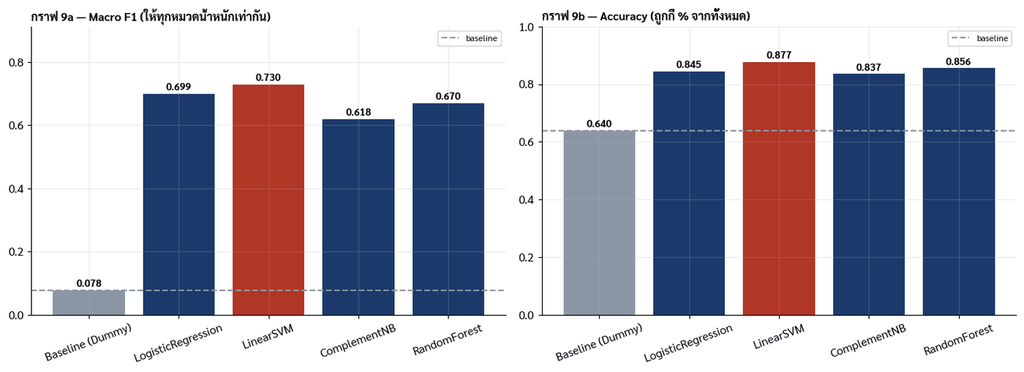

```
โมเดลที่ดีที่สุด : 2. TF-IDF + LinearSVM
Macro F1 : 0.0780 (baseline) -> 0.7297 = ดีขึ้น 9.4 เท่า
```

```python
base_f1 = res.loc["0. Baseline (Dummy)", "Macro F1"]
base_ac = res.loc["0. Baseline (Dummy)", "Accuracy"]

fig, axes = plt.subplots(1, 2, figsize=(13, 4.8))
short = [n.split(". ", 1)[1].replace("TF-IDF + ", "") for n in res.index]

for ax, col, base, title in [
    (axes[0], "Macro F1", base_f1, "กราฟ 9a — Macro F1 (ให้ทุกหมวดน้ำหนักเท่ากัน)"),
    (axes[1], "Accuracy", base_ac, "กราฟ 9b — Accuracy (ถูกกี่ % จากทั้งหมด)"),
]:
    v = res[col].values
    cols = [C_MUTE] + [C_MAIN] * (len(v) - 1)
    cols[int(np.argmax(v))] = C_ALT
    bars = ax.bar(short, v, color=cols)
    ax.axhline(base, color=C_MUTE, ls="--", lw=1.4, label="baseline")
    for b, x in zip(bars, v):
        ax.text(b.get_x() + b.get_width()/2, x + .012, f"{x:.3f}",
                ha="center", fontsize=9, fontweight="bold")
    ax.set_ylim(0, min(1.0, max(v) * 1.25))
    ax.set_title(title, loc="left", fontweight="bold", fontsize=10.5)
    ax.tick_params(axis="x", rotation=20)
    ax.legend(fontsize=8)

plt.tight_layout(); plt.show()

best_name = res["Macro F1"].idxmax()
best_f1   = res.loc[best_name, "Macro F1"]
print(f"โมเดลที่ดีที่สุด : {best_name}")
print(f"Macro F1 : {base_f1:.4f} (baseline) -> {best_f1:.4f} "
      f"= ดีขึ้น {best_f1/max(base_f1,1e-9):.1f} เท่า")
```

## 5.4 Cross-Validation — ผลที่ได้เป็นเรื่องบังเอิญหรือไม่

การวัดผลด้วยการแบ่ง train/test ครั้งเดียว อาจได้ตัวเลขที่ดีหรือแย่เพราะบังเอิญ Cross-validation แบ่งข้อมูลเป็น 5 ส่วน สลับกันเป็นชุดทดสอบ แล้วดูว่าคะแนน**เสถียร**แค่ไหน

ถ้าค่าเบี่ยงเบนมาตรฐานต่ำ แปลว่าผลที่ได้เชื่อถือได้

```python
cv = StratifiedKFold(n_splits=5, shuffle=True, random_state=RANDOM_STATE)
cv_rows = []

for name in ["1. TF-IDF + LogisticRegression",
             "2. TF-IDF + LinearSVM",
             "3. TF-IDF + ComplementNB"]:
    print(f"CV {name} ...", end=" ", flush=True)
    t0 = time.time()
    sc = cross_val_score(MODELS[name], X, y, cv=cv,
                         scoring="f1_macro", n_jobs=-1)
    cv_rows.append({"โมเดล": name, "ค่าเฉลี่ย": sc.mean(),
                    "SD": sc.std(), "ต่ำสุด": sc.min(), "สูงสุด": sc.max()})
    print(f"{sc.mean():.4f} +/- {sc.std():.4f}  ({time.time()-t0:.0f} วิ)")

cvdf = pd.DataFrame(cv_rows).set_index("โมเดล").round(4)
display(cvdf)
print("\nSD ต่ำ (< 0.02) = ผลเสถียร ไม่ใช่ความบังเอิญจากการแบ่งข้อมูลครั้งเดียว")
```

```
CV 1. TF-IDF + LogisticRegression ... 0.6992 +/- 0.0132  (287 วิ)
CV 2. TF-IDF + LinearSVM ... 0.7169 +/- 0.0122  (129 วิ)
CV 3. TF-IDF + ComplementNB ... 0.6073 +/- 0.0083  (88 วิ)
```

| โมเดล | ค่าเฉลี่ย | SD | ต่ำสุด | สูงสุด |
| --- | --- | --- | --- | --- |
| 1. TF-IDF + LogisticRegression | 0.6992 | 0.0132 | 0.6763 | 0.7143 |
| 2. TF-IDF + LinearSVM | 0.7169 | 0.0122 | 0.7009 | 0.7359 |
| 3. TF-IDF + ComplementNB | 0.6073 | 0.0083 | 0.5951 | 0.6180 |

```
SD ต่ำ (< 0.02) = ผลเสถียร ไม่ใช่ความบังเอิญจากการแบ่งข้อมูลครั้งเดียว
```

# §6 · Model Evaluation

## 6.1 โมเดลที่ให้ผลดีที่สุด

เลือกจาก Macro F1 สูงสุด แต่ต้องดูเวลา inference ประกอบด้วย เพราะเกณฑ์ SC-4 กำหนดว่าต้องทำนายได้ภายใน 50 มิลลิวินาทีต่อเรื่อง

```python
BEST_NAME  = res["Macro F1"].idxmax()
best_model = fitted[BEST_NAME]
y_pred     = best_model.predict(X_test)

print("=" * 74)
print(f"โมเดลที่เลือก: {BEST_NAME}")
print("=" * 74)
print(classification_report(y_test, y_pred, digits=4, zero_division=0))
```

```
==========================================================================
โมเดลที่เลือก: 2. TF-IDF + LinearSVM
==========================================================================
                                precision    recall  f1-score   support

    Checking / savings account     0.7514    0.8068    0.7781       828
    Credit card / Prepaid card     0.7394    0.7829    0.7605       866
              Credit reporting     0.9521    0.9355    0.9438      7677
               Debt collection     0.7422    0.7625    0.7522      1276
     Debt or credit management     0.5714    0.2424    0.3404        33
       Money transfer / crypto     0.7670    0.7441    0.7554       469
                      Mortgage     0.8659    0.9132    0.8889       311
Payday / title / personal loan     0.5625    0.5070    0.5333       142
                  Student loan     0.8182    0.8394    0.8286       193
          Vehicle loan / lease     0.6959    0.7366    0.7156       205

                      accuracy                         0.8772     12000
                     macro avg     0.7466    0.7270    0.7297     12000
                  weighted avg     0.8789    0.8772    0.8777     12000
```

## 6.2 กราฟที่ 10 — Confusion Matrix

แถว = หมวดจริง · คอลัมน์ = หมวดที่โมเดลทาย ตัวเลขคือ**สัดส่วนภายในแถว** — แนวทแยงคือทายถูก ยิ่งเข้มยิ่งดี ช่องนอกแนวทแยงที่เข้มผิดปกติ คือคู่หมวดที่โมเดลสับสน

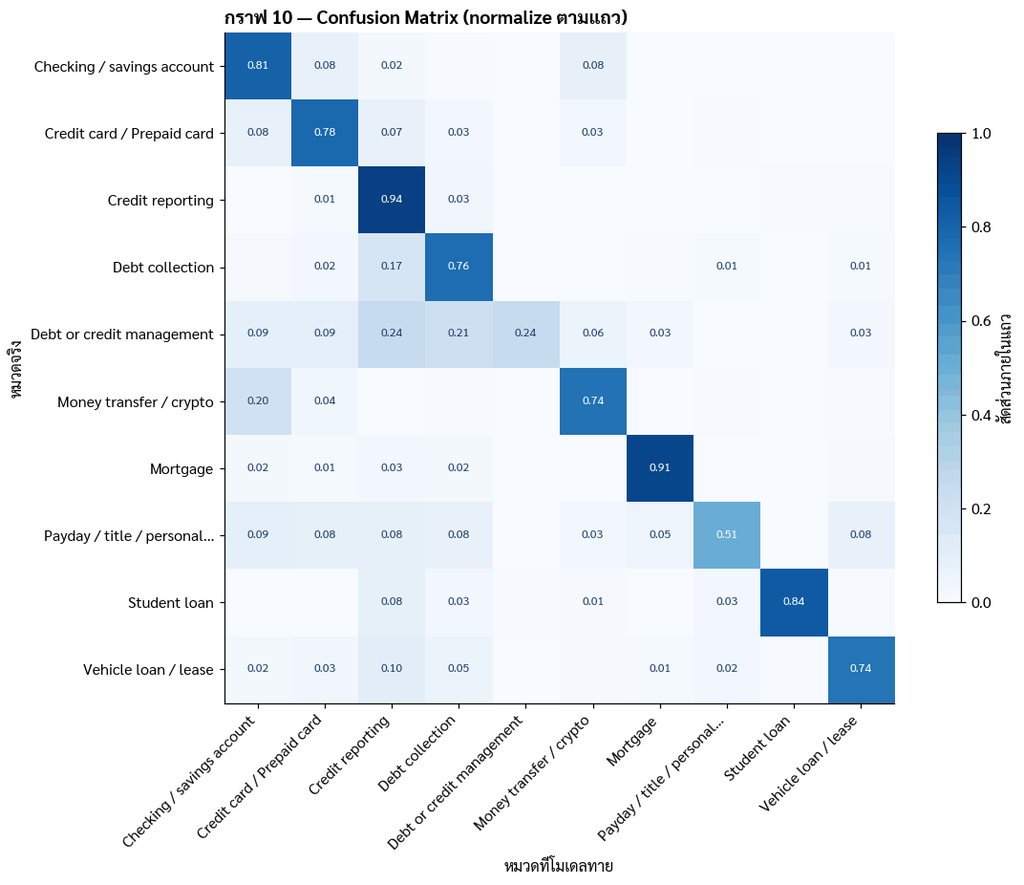

```python
labels = sorted(y_test.unique())
cm = confusion_matrix(y_test, y_pred, labels=labels)
cmn = cm.astype(float) / cm.sum(axis=1, keepdims=True)

fig, ax = plt.subplots(figsize=(10.5, 8.5))
im = ax.imshow(cmn, cmap="Blues", vmin=0, vmax=1)
short_lbl = [textwrap.shorten(l, 26, placeholder="…") for l in labels]
ax.set_xticks(range(len(labels))); ax.set_xticklabels(short_lbl, rotation=45, ha="right")
ax.set_yticks(range(len(labels))); ax.set_yticklabels(short_lbl)
ax.set_xlabel("หมวดที่โมเดลทาย"); ax.set_ylabel("หมวดจริง")
ax.set_title("กราฟ 10 — Confusion Matrix (normalize ตามแถว)",
             loc="left", fontweight="bold")
for i in range(len(labels)):
    for j in range(len(labels)):
        if cmn[i, j] > 0.01:
            ax.text(j, i, f"{cmn[i,j]:.2f}", ha="center", va="center", fontsize=8,
                    color="white" if cmn[i, j] > .5 else "#1B3A6B")
ax.grid(False)
fig.colorbar(im, ax=ax, shrink=.7, label="สัดส่วนภายในแถว")
plt.tight_layout(); plt.show()
```

## 6.3 Error Analysis — โมเดลสับสนคู่ไหนมากที่สุด

นี่คือส่วนที่ทำให้งานต่างจากการรันโมเดลเฉยๆ เราต้องอธิบายให้ได้ว่า **ทำไม**โมเดลถึงสับสน และมันสมเหตุสมผลหรือไม่

```python
err = []
for i, a in enumerate(labels):
    for j, b in enumerate(labels):
        if i != j and cm[i, j] > 0:
            err.append({"หมวดจริง": a, "โมเดลทายเป็น": b,
                        "จำนวน": int(cm[i, j]),
                        "% ของหมวดจริง": round(cmn[i, j] * 100, 1)})

if len(err) == 0:
    print("ไม่พบการทายผิดเลยในชุดทดสอบ")
    print("ถ้าเจอกรณีนี้กับข้อมูลจริง ให้สงสัย data leakage ทันที")
else:
    err = pd.DataFrame(err).sort_values("จำนวน", ascending=False).reset_index(drop=True)
    print(f"พบการทายผิดทั้งหมด {err['จำนวน'].sum():,} เรื่อง "
          f"({err['จำนวน'].sum()/len(y_test):.1%} ของชุดทดสอบ)")
    print("\n10 คู่ที่โมเดลสับสนมากที่สุด")
    display(err.head(10))

    print("\nตัวอย่างข้อความที่ทายผิดของคู่อันดับ 1:")
    r0 = err.iloc[0]
    print(f"  หมวดจริง: {r0['หมวดจริง']}  ->  โมเดลทายเป็น: {r0['โมเดลทายเป็น']}")
    mask = (y_test.values == r0["หมวดจริง"]) & (y_pred == r0["โมเดลทายเป็น"])
    for k, t in enumerate(X_test[mask].head(2)):
        print(f"\n--- ตัวอย่างที่ {k+1} ---")
        print(textwrap.fill(t[:420], 92))
```

```
พบการทายผิดทั้งหมด 1,473 เรื่อง (12.3% ของชุดทดสอบ)

10 คู่ที่โมเดลสับสนมากที่สุด
```

|  | หมวดจริง | โมเดลทายเป็น | จำนวน | % ของหมวดจริง |
| --- | --- | --- | --- | --- |
| 0 | Credit reporting | Debt collection | 263 | 3.4 |
| 1 | Debt collection | Credit reporting | 215 | 16.8 |
| 2 | Credit reporting | Credit card / Prepaid card | 101 | 1.3 |
| 3 | Money transfer / crypto | Checking / savings account | 95 | 20.3 |
| 4 | Credit card / Prepaid card | Checking / savings account | 67 | 7.7 |
| 5 | Checking / savings account | Money transfer / crypto | 66 | 8.0 |
| 6 | Checking / savings account | Credit card / Prepaid card | 63 | 7.6 |
| 7 | Credit card / Prepaid card | Credit reporting | 62 | 7.2 |
| 8 | Credit reporting | Student loan | 33 | 0.4 |
| 9 | Debt collection | Credit card / Prepaid card | 31 | 2.4 |

```
ตัวอย่างข้อความที่ทายผิดของคู่อันดับ 1:
  หมวดจริง: Credit reporting  ->  โมเดลทายเป็น: Debt collection

--- ตัวอย่างที่ 1 ---
ative i was working out at year my purse and phone was stolen from the locker containing my
identification credit cards social security card of myself and both of my sons my car keys
and in cash at the time i made a police report with report since then i have received
notification of change of address that i did not make and the following accounts are
fraudulently opened accounts act act act act act act portfolio rec

--- ตัวอย่างที่ 2 ---
account continue to report with lout authorization or consent for the account to even be
opened this account was open fraudulently during the covid pandemic the company offered not
type of relief in the middle of a global pandemic didnt offer deferment or any type of
arrangements not give relief based on the account being opened without consent
```

## 6.4 กราฟที่ 11 — F1 รายหมวด เทียบกับจำนวนตัวอย่าง

ตรวจว่าหมวดเล็กถูกทิ้งหรือไม่ (เกณฑ์ SC-3)

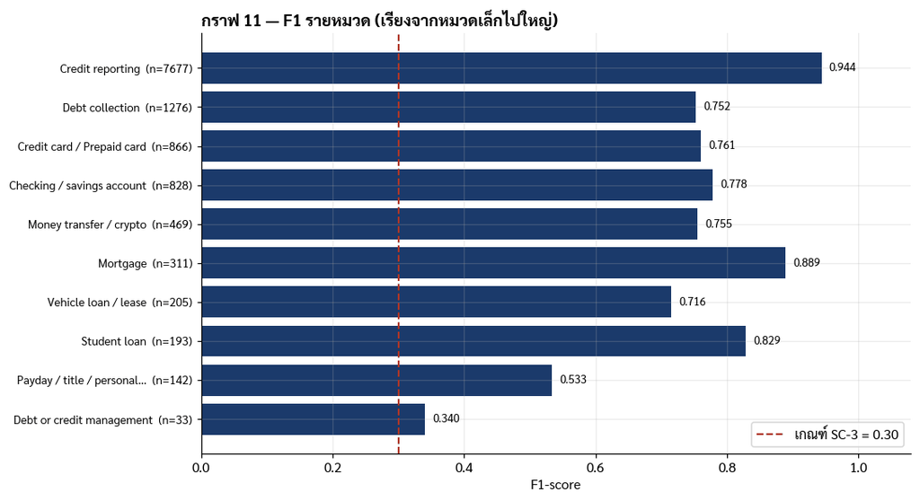

```
ผ่านเกณฑ์ SC-3 ทุกหมวด
```

```python
rep = classification_report(y_test, y_pred, output_dict=True, zero_division=0)
per = pd.DataFrame({
    "F1": {l: rep[l]["f1-score"] for l in labels},
    "n_test": {l: rep[l]["support"] for l in labels},
}).sort_values("n_test")

fig, ax1 = plt.subplots(figsize=(10, 5.5))
yy = np.arange(len(per))
ax1.barh(yy, per["F1"], color=[C_ALT if f < .3 else C_MAIN for f in per["F1"]])
ax1.set_yticks(yy)
ax1.set_yticklabels([f"{textwrap.shorten(i, 26, placeholder='…')}  (n={int(n)})"
                     for i, n in zip(per.index, per["n_test"])], fontsize=9)
ax1.axvline(0.30, color=C_ALT, ls="--", lw=1.4, label="เกณฑ์ SC-3 = 0.30")
for i, f in enumerate(per["F1"]):
    ax1.text(f + .012, i, f"{f:.3f}", va="center", fontsize=8.5)
ax1.set_xlim(0, 1.08); ax1.set_xlabel("F1-score")
ax1.set_title("กราฟ 11 — F1 รายหมวด (เรียงจากหมวดเล็กไปใหญ่)",
              loc="left", fontweight="bold")
ax1.legend(loc="lower right")
plt.tight_layout(); plt.show()

fail = per[per["F1"] < .30]
print("ผ่านเกณฑ์ SC-3 ทุกหมวด" if len(fail) == 0
      else f"ไม่ผ่านเกณฑ์ SC-3 จำนวน {len(fail)} หมวด: {list(fail.index)}")
```

## 6.5 Cost Matrix — แปลงความผิดพลาดเป็นตัวเงิน

ตัวเลข Macro F1 บอกว่าโมเดลดีแค่ไหนในเชิงสถิติ แต่ผู้บริหารไม่ได้ตัดสินใจด้วย F1 สิ่งที่เขาถามคือ **"ใช้แล้วประหยัดเงินได้เท่าไหร่"**

Cost Matrix คือการกำหนดราคาให้กับผลลัพธ์แต่ละแบบ แล้วคำนวณต้นทุนรวมออกมาเป็นเงินจริง

| ผลลัพธ์ | เกิดอะไรขึ้น | ต้นทุน |
| --- | --- | --- |
| ความมั่นใจสูง + ทายถูก | เรื่องเข้าทีมถูกต้องทันที ไม่ต้องใช้คน | **$0** (ประหยัดเต็มจำนวน) |
| ความมั่นใจสูง + ทายผิด | เรื่องนั่งผิดคิว ต้องส่งใหม่ กินโควตา 15 วัน | **สูงที่สุด** |
| ความมั่นใจต่ำ | ส่งเข้าคิวให้เจ้าหน้าที่คัดแยกเอง | เท่ากับกระบวนการเดิม |

> สมมติฐานด้านล่างตั้งจากค่าแรงเจ้าหน้าที่ compliance ในสหรัฐฯ **ทุกตัวเลขปรับได้** — ในการนำเสนอควรบอกว่าเป็นสมมติฐาน ไม่ใช่ข้อเท็จจริง

```python
# ── สมมติฐานด้านต้นทุน (ปรับได้ตามบริบทองค์กร) ─────────────────────
WAGE_HR        = 28.0   # ค่าแรงเจ้าหน้าที่ compliance ต่อชั่วโมง (USD)
MIN_MANUAL     = 4.0    # นาทีที่ใช้คัดแยกเรื่องหนึ่งด้วยมือ
MIN_REROUTE    = 25.0   # นาทีที่เสียไปเมื่อเรื่องถูกส่งผิดทีมแล้วต้องส่งใหม่
PENALTY_LATE   = 45.0   # ต้นทุนความเสี่ยงเชิงกำกับดูแลต่อเรื่องที่ส่งผิด (USD)
VOLUME         = 10_000 # จำนวนเรื่องต่อเดือนที่นำมาคำนวณ

COST_MANUAL  = WAGE_HR * MIN_MANUAL  / 60      # คัดแยกเองหนึ่งเรื่อง
COST_REROUTE = WAGE_HR * MIN_REROUTE / 60 + PENALTY_LATE

print(f"ต้นทุนคัดแยกด้วยมือ 1 เรื่อง : $ {COST_MANUAL:6.2f}")
print(f"ต้นทุนเมื่อส่งผิดทีม 1 เรื่อง  : $ {COST_REROUTE:6.2f}")
print(f"อัตราส่วนความเสียหาย        : {COST_REROUTE/COST_MANUAL:.0f} เท่า")
print()
print(f"กระบวนการเดิม (คนคัดทั้งหมด) ต่อ {VOLUME:,} เรื่อง : "
      f"$ {VOLUME*COST_MANUAL:,.0f}")
```

```
ต้นทุนคัดแยกด้วยมือ 1 เรื่อง : $   1.87
ต้นทุนเมื่อส่งผิดทีม 1 เรื่อง  : $  56.67
อัตราส่วนความเสียหาย        : 30 เท่า

กระบวนการเดิม (คนคัดทั้งหมด) ต่อ 10,000 เรื่อง : $ 18,667
```

```python
# ── คำนวณต้นทุนรวมที่แต่ละเกณฑ์ความมั่นใจ ──────────────────────────
lin  = fitted["1. TF-IDF + LogisticRegression"]
P    = lin.predict_proba(X_test)
conf = P.max(axis=1)
pred_p  = lin.classes_[P.argmax(axis=1)]
correct = (pred_p == y_test.values)

rows = []
for th in [0.00, 0.30, 0.40, 0.50, 0.60, 0.70, 0.80, 0.90, 1.01]:
    auto = conf >= th
    n_auto      = auto.mean()
    n_auto_ok   = (auto & correct).mean()
    n_auto_bad  = (auto & ~correct).mean()
    n_manual    = (~auto).mean()
    cost = VOLUME * (n_auto_bad * COST_REROUTE + n_manual * COST_MANUAL)
    rows.append({
        "เกณฑ์": th,
        "ส่งอัตโนมัติ %": round(n_auto*100, 1),
        "อัตโนมัติ+ถูก %": round(n_auto_ok*100, 1),
        "อัตโนมัติ+ผิด %": round(n_auto_bad*100, 1),
        "คนคัดเอง %": round(n_manual*100, 1),
        f"ต้นทุนรวม/{VOLUME//1000}k เรื่อง ($)": round(cost),
        "ประหยัดจากเดิม ($)": round(VOLUME*COST_MANUAL - cost),
    })

cost_df = pd.DataFrame(rows)
display(cost_df)

col_cost = f"ต้นทุนรวม/{VOLUME//1000}k เรื่อง ($)"
best_row = cost_df.loc[cost_df[col_cost].idxmin()]
print(f"\nเกณฑ์ที่ต้นทุนต่ำสุด : {best_row['เกณฑ์']}")
print(f"  ต้นทุนรวม   : $ {best_row[col_cost]:,.0f}")
print(f"  ประหยัดได้  : $ {best_row['ประหยัดจากเดิม ($)']:,.0f} ต่อ {VOLUME:,} เรื่อง "
      f"({best_row['ประหยัดจากเดิม ($)']/(VOLUME*COST_MANUAL):.0%} ของต้นทุนเดิม)")
print(f"  ต่อปี (12 เดือน) : $ {best_row['ประหยัดจากเดิม ($)']*12:,.0f}")
```

|  | เกณฑ์ | ส่งอัตโนมัติ % | อัตโนมัติ+ถูก % | อัตโนมัติ+ผิด % | คนคัดเอง % | ต้นทุนรวม/10k เรื่อง ($) | ประหยัดจากเดิม ($) |
| --- | --- | --- | --- | --- | --- | --- | --- |
| 0 | 0.00 | 100.0 | 84.5 | 15.5 | 0.0 | 87739 | -69072 |
| 1 | 0.30 | 96.5 | 83.0 | 13.5 | 3.5 | 77341 | -58674 |
| 2 | 0.40 | 90.8 | 79.7 | 11.0 | 9.2 | 64339 | -45672 |
| 3 | 0.50 | 82.6 | 74.2 | 8.4 | 17.4 | 51034 | -32367 |
| 4 | 0.60 | 73.4 | 67.2 | 6.2 | 26.6 | 40014 | -21347 |
| 5 | 0.70 | 62.4 | 58.2 | 4.2 | 37.6 | 30718 | -12051 |
| 6 | 0.80 | 48.2 | 45.6 | 2.6 | 51.8 | 24637 | -5971 |
| 7 | 0.90 | 26.9 | 25.8 | 1.1 | 73.1 | 19787 | -1121 |
| 8 | 1.01 | 0.0 | 0.0 | 0.0 | 100.0 | 18667 | 0 |

```
เกณฑ์ที่ต้นทุนต่ำสุด : 1.01
  ต้นทุนรวม   : $ 18,667
  ประหยัดได้  : $ 0 ต่อ 10,000 เรื่อง (0% ของต้นทุนเดิม)
  ต่อปี (12 เดือน) : $ 0
```

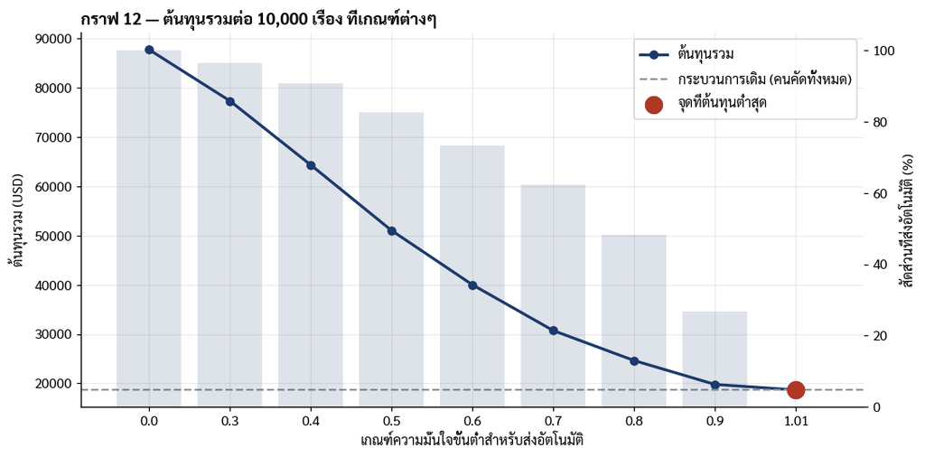

```
อ่านกราฟ: เกณฑ์ต่ำเกินไป -> ส่งอัตโนมัติเยอะแต่ผิดเยอะ ต้นทุน re-route พุ่ง
          เกณฑ์สูงเกินไป -> แทบไม่ต่างจากให้คนทำเองทั้งหมด
          จุดต่ำสุดของเส้นคือเกณฑ์ที่ควรใช้จริง
```

```python
# ── กราฟที่ 12: ต้นทุนรวมเทียบกับเกณฑ์ความมั่นใจ ───────────────────
fig, ax1 = plt.subplots(figsize=(10, 5))
xs = [str(t) for t in cost_df["เกณฑ์"]]

ax1.plot(xs, cost_df[col_cost], color=C_MAIN, lw=2.2, marker="o", label="ต้นทุนรวม")
ax1.axhline(VOLUME*COST_MANUAL, color=C_MUTE, ls="--", lw=1.5,
            label="กระบวนการเดิม (คนคัดทั้งหมด)")
i_best = int(cost_df[col_cost].idxmin())
ax1.scatter([xs[i_best]], [cost_df[col_cost].iloc[i_best]],
            s=170, color=C_ALT, zorder=5, label="จุดที่ต้นทุนต่ำสุด")
ax1.set_xlabel("เกณฑ์ความมั่นใจขั้นต่ำสำหรับส่งอัตโนมัติ")
ax1.set_ylabel("ต้นทุนรวม (USD)")
ax1.set_title(f"กราฟ 12 — ต้นทุนรวมต่อ {VOLUME:,} เรื่อง ที่เกณฑ์ต่างๆ",
              loc="left", fontweight="bold")
ax1.legend()

ax2 = ax1.twinx()
ax2.bar(xs, cost_df["ส่งอัตโนมัติ %"], alpha=.14, color=C_MAIN)
ax2.set_ylabel("สัดส่วนที่ส่งอัตโนมัติ (%)")
ax2.grid(False)

plt.tight_layout(); plt.show()

print("อ่านกราฟ: เกณฑ์ต่ำเกินไป -> ส่งอัตโนมัติเยอะแต่ผิดเยอะ ต้นทุน re-route พุ่ง")
print("          เกณฑ์สูงเกินไป -> แทบไม่ต่างจากให้คนทำเองทั้งหมด")
print("          จุดต่ำสุดของเส้นคือเกณฑ์ที่ควรใช้จริง")
```

## 6.5b · แก้สมมติฐาน Cost Matrix — เมื่อ "คน" ก็ติดหมวดผิดได้เหมือนกัน

ผลใน §6.5 สรุปว่าเกณฑ์ที่ต้นทุนต่ำที่สุดคือ `1.01` ซึ่งแปลว่า **ไม่ส่งอัตโนมัติเลยสักเรื่อง** ผลนั้นไม่ได้มาจากโมเดลไม่ดี แต่มาจาก **สมมติฐานที่ไม่ยุติธรรม** ในตารางต้นทุนเดิม

|  | สมมติฐานเดิม (§6.5) | ปัญหา |
| --- | --- | --- |
| โมเดลทายผิด | เสีย `COST_REROUTE` = $56.67 | ถูกต้อง |
| **เจ้าหน้าที่คัดแยกเอง** | เสียแค่ `COST_MANUAL` = $1.87 | **สมมติว่าคนถูก 100%** ไม่มีทางส่งผิดคิวเลย |

ผลของสมมติฐานนี้คำนวณได้ตรง ๆ: ระบบอัตโนมัติจะคุ้มก็ต่อเมื่อ

$$e_{\text{auto}} \times C_{\text{reroute}} \;<\; C_{\text{manual}} \;\;\Rightarrow\;\; e_{\text{auto}} < \frac{1.87}{56.67} = 3.29\%$$

โมเดลที่แม่น 84.5% ไม่มีทางทำอัตราผิดต่ำกว่า 3.29% ในสัดส่วนที่มีนัยสำคัญ คำตอบจึงถูกบังคับให้เป็น "อย่าใช้เลย" ตั้งแต่ก่อนดูข้อมูล

**สิ่งที่แก้ในหัวข้อนี้** — เพิ่มพารามิเตอร์ `HUMAN_ERR` = อัตราที่เจ้าหน้าที่ติดหมวดผิดเอง แล้วคิดต้นทุนฝั่งคนให้ครบ:

$$C_{\text{manual route}} = C_{\text{manual}} + h \times C_{\text{reroute}}$$

เราไม่ตั้งค่า $h$ ตายตัว เพราะไม่มีตัวเลขจริงของ CFPB เผยแพร่ไว้ แต่รายงาน **จุดคุ้มทุน (break-even)** และ **ตารางความไว (sensitivity)** แทน ซึ่งเป็นข้อสรุปที่ไม่ต้องเดา

```python
# ── §6.5b รันได้ด้วยตัวเอง: โหลดข้อมูลและฝึกโมเดล production ใหม่
#    (ใช้ seed และกฎเตรียมข้อมูลชุดเดียวกับ §4 ผลจึงตรงกับโน้ตบุ๊กหลัก)
import os, re, time, json, warnings
import numpy as np
import pandas as pd
import matplotlib.pyplot as plt
from sklearn.model_selection import train_test_split
from sklearn.feature_extraction.text import TfidfVectorizer
from sklearn.linear_model import LogisticRegression
from sklearn.svm import LinearSVC
from sklearn.dummy import DummyClassifier
from sklearn.pipeline import Pipeline
from sklearn.metrics import accuracy_score, f1_score, classification_report
warnings.filterwarnings("ignore")

RANDOM_STATE, TEST_SIZE, SAMPLE_N = 42, 0.20, 60_000
MIN_CHARS, MIN_CLASS_N = 100, 300
NAR, TGT = "Consumer complaint narrative", "Product"
np.random.seed(RANDOM_STATE)

MERGE_MAP = {
    "Credit reporting, credit repair services, or other personal consumer reports": "Credit reporting",
    "Credit reporting or other personal consumer reports": "Credit reporting",
    "Credit card": "Credit card / Prepaid card",
    "Prepaid card": "Credit card / Prepaid card",
    "Credit card or prepaid card": "Credit card / Prepaid card",
    "Payday loan, title loan, or personal loan": "Payday / title / personal loan",
    "Payday loan, title loan, personal loan, or advance loan": "Payday / title / personal loan",
    "Money transfer, virtual currency, or money service": "Money transfer / crypto",
    "Money transfers": "Money transfer / crypto",
    "Checking or savings account": "Checking / savings account",
    "Bank account or service": "Checking / savings account",
    "Vehicle loan or lease": "Vehicle loan / lease",
    "Consumer Loan": "Vehicle loan / lease",
}
RE_MASK, RE_URL, RE_NUM, RE_PUNCT, RE_SPACE = (
    re.compile(r"\bX{2,}\b|X{4,}"), re.compile(r"http\S+|www\.\S+"),
    re.compile(r"\d+"), re.compile(r"[^a-z\s]"), re.compile(r"\s+"))

def clean_text(s):
    s = str(s); s = RE_MASK.sub(" ", s); s = s.lower()
    s = RE_URL.sub(" ", s); s = RE_NUM.sub(" ", s); s = RE_PUNCT.sub(" ", s)
    return RE_SPACE.sub(" ", s).strip()

C_MAIN, C_ALT, C_MUTE, C_OK = "#1B3A6B", "#B03626", "#8B96A5", "#2E7D4F"

# ── ลงทะเบียนฟอนต์ไทย (Sarabun) เหมือน §0.3 ──────────────────────
import matplotlib.font_manager as fm, glob as _glob
THAI_FONT = None
for f in _glob.glob("/usr/share/fonts/truetype/thai_custom/*.ttf") + \
         _glob.glob("/usr/share/fonts/**/*[Ss]arabun*.ttf", recursive=True) + \
         _glob.glob("/usr/share/fonts/**/*[Tt]hai*.ttf", recursive=True):
    try:
        fm.fontManager.addfont(f)
        name = fm.FontProperties(fname=f).get_name()
        if THAI_FONT is None or "Sarabun" in name:
            THAI_FONT = name
    except Exception:
        pass
FAMILY = ([THAI_FONT] if THAI_FONT else []) + ["DejaVu Sans", "sans-serif"]
plt.rcParams.update({"figure.dpi": 110, "axes.grid": True, "grid.alpha": .25,
                     "axes.spines.top": False, "axes.spines.right": False, "font.size": 10.5,
                     "font.family": FAMILY, "font.sans-serif": FAMILY, "axes.unicode_minus": False})
print("ใช้ฟอนต์:", THAI_FONT)

t0 = time.time()
df = pd.read_csv("/mnt/user-data/uploads/Data/complaints_clean_150k.csv.gz", low_memory=False)
df = df[[NAR, TGT]].dropna().drop_duplicates(subset=[NAR])
df[TGT] = df[TGT].replace(MERGE_MAP)
df["text"] = df[NAR].map(clean_text)
df = df[df["text"].str.len() >= MIN_CHARS]
keep = df[TGT].value_counts(); keep = keep[keep >= MIN_CLASS_N].index
df = df[df[TGT].isin(keep)]
n_all = len(df)
df = df.groupby(TGT, group_keys=False).apply(
    lambda g: g.sample(max(1, int(round(SAMPLE_N * len(g) / n_all))), random_state=RANDOM_STATE))
df = df.reset_index(drop=True)

X_train, X_test, y_train, y_test = train_test_split(
    df["text"], df[TGT], test_size=TEST_SIZE, random_state=RANDOM_STATE, stratify=df[TGT])
print(f"เตรียมข้อมูลเสร็จใน {time.time()-t0:.0f}s | train={len(X_train):,} test={len(X_test):,} "
      f"| {df[TGT].nunique()} หมวด")

TFIDF = dict(ngram_range=(1, 2), min_df=3, max_df=0.85, sublinear_tf=True,
             stop_words="english", max_features=150_000)

# ── โมเดลที่ deploy จริง (ให้ค่าความน่าจะเป็นได้) ──────────────────
t0 = time.time()
prod = Pipeline([("tfidf", TfidfVectorizer(**TFIDF)),
                 ("clf", LogisticRegression(max_iter=1500, class_weight="balanced",
                                            random_state=RANDOM_STATE, n_jobs=-1))]).fit(X_train, y_train)
print(f"ฝึกโมเดล production (LogisticRegression) {time.time()-t0:.0f}s")

t0 = time.time()
P = prod.predict_proba(X_test)
MS_PROD = (time.time() - t0) / len(X_test) * 1000
conf = P.max(axis=1)
pred_prod = prod.classes_[P.argmax(axis=1)]
correct = (pred_prod == y_test.values)
print(f"production: accuracy={correct.mean():.4f} "
      f"macro F1={f1_score(y_test, pred_prod, average='macro', zero_division=0):.4f} "
      f"({MS_PROD:.3f} ms/เรื่อง)")
```

```
ใช้ฟอนต์: Sarabun
```

```
เตรียมข้อมูลเสร็จใน 16s | train=48,000 test=12,000 | 10 หมวด
```

```
ฝึกโมเดล production (LogisticRegression) 39s
```

```
production: accuracy=0.8452 macro F1=0.6985 (0.136 ms/เรื่อง)
```

```python
# ── ตารางต้นทุน: เพิ่มอัตราผิดพลาดของ "คน" เข้าไปในสมการ ──────────
WAGE_HR, MIN_MANUAL, MIN_REROUTE, PENALTY_LATE, VOLUME = 28.0, 4.0, 25.0, 45.0, 10_000
COST_MANUAL  = WAGE_HR * MIN_MANUAL  / 60          # ค่าแรงคัดแยกด้วยมือ 1 เรื่อง
COST_REROUTE = WAGE_HR * MIN_REROUTE / 60 + PENALTY_LATE   # เรื่องนั่งผิดคิว ต้องส่งใหม่

GRID = [0.00, 0.40, 0.50, 0.60, 0.70, 0.80, 0.90, 1.01]

def cost_at(th, h):
    """ต้นทุนรวมต่อ VOLUME เรื่อง เมื่อใช้เกณฑ์ th และเจ้าหน้าที่ติดหมวดผิดเอง h"""
    auto      = conf >= th
    auto_bad  = (auto & ~correct).mean()
    manual    = (~auto).mean()
    return VOLUME * (auto_bad * COST_REROUTE + manual * (COST_MANUAL + h * COST_REROUTE))

def baseline_at(h):
    """กระบวนการเดิม: คนคัดทุกเรื่อง และผิดเองในอัตรา h"""
    return VOLUME * (COST_MANUAL + h * COST_REROUTE)

# ── จุดคุ้มทุน: ต้องให้คนผิดกี่ % ระบบถึงจะเริ่มประหยัดเงิน ──────────
rows = []
for th in GRID[:-1]:
    auto = conf >= th
    a, bad = auto.mean(), (auto & ~correct).mean()
    h_be = (bad * COST_REROUTE - a * COST_MANUAL) / (a * COST_REROUTE) if a > 0 else np.nan
    rows.append({"เกณฑ์": th,
                 "ส่งอัตโนมัติ %": round(a * 100, 1),
                 "ผิด % ของที่ส่ง": round(bad / a * 100, 2) if a > 0 else np.nan,
                 "คนต้องผิดเกิน (%) ถึงจะคุ้ม": round(h_be * 100, 2)})
be = pd.DataFrame(rows)
print("=" * 78)
print("จุดคุ้มทุน — ระบบเริ่มประหยัดเงินเมื่อเจ้าหน้าที่ติดหมวดผิดเกินค่านี้")
print("=" * 78)
display(be)
print(f"ถ้าเจ้าหน้าที่ถูก 100% (สมมติฐานเดิม): ระบบต้องผิดไม่เกิน "
      f"{COST_MANUAL/COST_REROUTE*100:.2f}% ของที่ส่งอัตโนมัติ ซึ่งเป็นไปไม่ได้ -> ได้ 1.01")
```

```
==============================================================================
จุดคุ้มทุน — ระบบเริ่มประหยัดเงินเมื่อเจ้าหน้าที่ติดหมวดผิดเกินค่านี้
==============================================================================
```

|  | เกณฑ์ | ส่งอัตโนมัติ % | ผิด % ของที่ส่ง | คนต้องผิดเกิน (%) ถึงจะคุ้ม |
| --- | --- | --- | --- | --- |
| 0 | 0.0 | 100.0 | 15.48 | 12.18 |
| 1 | 0.4 | 90.6 | 12.12 | 8.82 |
| 2 | 0.5 | 82.5 | 10.19 | 6.89 |
| 3 | 0.6 | 73.5 | 8.43 | 5.13 |
| 4 | 0.7 | 62.4 | 6.68 | 3.38 |
| 5 | 0.8 | 48.2 | 5.45 | 2.15 |
| 6 | 0.9 | 27.0 | 4.07 | 0.77 |

```
ถ้าเจ้าหน้าที่ถูก 100% (สมมติฐานเดิม): ระบบต้องผิดไม่เกิน 3.29% ของที่ส่งอัตโนมัติ ซึ่งเป็นไปไม่ได้ -> ได้ 1.01
```

```python
# ── ตารางความไว: ประหยัดกี่ % ที่แต่ละเกณฑ์ เมื่อคนผิดในอัตราต่าง ๆ ──
H_GRID = [0.00, 0.05, 0.10, 0.15, 0.20]
sens = pd.DataFrame(
    {f"h={int(h*100)}%": [round((baseline_at(h) - cost_at(th, h)) / baseline_at(h) * 100, 1)
                          for th in GRID]
     for h in H_GRID},
    index=[str(t) for t in GRID])
sens.index.name = "เกณฑ์"
print("ประหยัดจากกระบวนการเดิม (% ของต้นทุนเดิม) — ค่าติดลบ = แพงกว่าให้คนทำทั้งหมด")
display(sens)

for h in H_GRID:
    best = min(GRID, key=lambda t: cost_at(t, h))
    print(f"  h={h:>4.0%} -> เกณฑ์ที่ถูกที่สุด {best}   "
          f"ประหยัด ${baseline_at(h)-cost_at(best,h):,.0f} ต่อ {VOLUME:,} เรื่อง")

# ── เลือกเกณฑ์แบบไม่ต้องเดา h : minimax regret ────────────────────
#   regret = เงินที่เสียไปเทียบกับ "ถ้ารู้ค่า h ล่วงหน้าแล้วเลือกเกณฑ์ที่ดีที่สุด"
#   วัดเป็นดอลลาร์ ไม่ใช่เปอร์เซ็นต์ เพราะที่ h ต่ำ ๆ เงินที่ประหยัดได้น้อยมาก
#   การหารด้วยฐานเล็ก ๆ จะทำให้ค่าเปอร์เซ็นต์พองจนบิดคำตอบ
H_PLAUS = [0.05, 0.075, 0.10, 0.125, 0.15, 0.175, 0.20]
reg = {}
for th in GRID[:-1]:
    worst = 0.0
    for h in H_PLAUS:
        best_save = max(baseline_at(h) - cost_at(t, h) for t in GRID)
        save      = baseline_at(h) - cost_at(th, h)
        worst = max(worst, best_save - save)
    reg[th] = round(worst)
reg_s = pd.Series(reg, name=f"regret สูงสุด ($ ต่อ {VOLUME:,} เรื่อง)")
reg_s.index.name = "เกณฑ์"
print(f"\nถ้าเดา h ผิด จะเสียเงินมากที่สุดเท่าไหร่ เทียบกับการรู้ h ล่วงหน้า (ยิ่งน้อยยิ่งทน)")
display(reg_s.to_frame())
CONF_TH_NEW = min(reg, key=reg.get)
print(f"\nเกณฑ์ที่ทนต่อความไม่รู้ค่า h ได้ดีที่สุด (minimax regret) : {CONF_TH_NEW}")
print(f"  เสียมากที่สุด ${reg[CONF_TH_NEW]:,} ต่อ {VOLUME:,} เรื่อง "
      f"เทียบกับ ${reg[0.6]:,} ที่เกณฑ์ 0.6 และ ${reg[0.8]:,} ที่เกณฑ์ 0.8")
```

```
ประหยัดจากกระบวนการเดิม (% ของต้นทุนเดิม) — ค่าติดลบ = แพงกว่าให้คนทำทั้งหมด
```

| เกณฑ์ | h=0% | h=5% | h=10% | h=15% | h=20% |
| --- | --- | --- | --- | --- | --- |
| 0.0 | -369.8 | -86.6 | -16.4 | 15.4 | 33.6 |
| 0.4 | -242.8 | -41.8 | 8.0 | 30.6 | 43.5 |
| 0.5 | -172.7 | -18.8 | 19.3 | 36.6 | 46.4 |
| 0.6 | -114.5 | -1.2 | 26.9 | 39.6 | 46.9 |
| 0.7 | -64.1 | 12.2 | 31.1 | 39.6 | 44.5 |
| 0.8 | -31.5 | 16.5 | 28.4 | 33.8 | 36.9 |
| 0.9 | -6.4 | 13.8 | 18.8 | 21.0 | 22.3 |
| 1.01 | 0.0 | 0.0 | 0.0 | 0.0 | 0.0 |

```
  h=  0% -> เกณฑ์ที่ถูกที่สุด 1.01   ประหยัด $0 ต่อ 10,000 เรื่อง
  h=  5% -> เกณฑ์ที่ถูกที่สุด 0.8   ประหยัด $7,767 ต่อ 10,000 เรื่อง
  h= 10% -> เกณฑ์ที่ถูกที่สุด 0.7   ประหยัด $23,397 ต่อ 10,000 เรื่อง
  h= 15% -> เกณฑ์ที่ถูกที่สุด 0.7   ประหยัด $41,077 ต่อ 10,000 เรื่อง
  h= 20% -> เกณฑ์ที่ถูกที่สุด 0.6   ประหยัด $61,890 ต่อ 10,000 เรื่อง

ถ้าเดา h ผิด จะเสียเงินมากที่สุดเท่าไหร่ เทียบกับการรู้ h ล่วงหน้า (ยิ่งน้อยยิ่งทน)
```

| เกณฑ์ | regret สูงสุด ($ ต่อ 10,000 เรื่อง) |
| --- | --- |
| 0.0 | 48459 |
| 0.4 | 27405 |
| 0.5 | 16620 |
| 0.6 | 8324 |
| 0.7 | 3133 |
| 0.8 | 13174 |
| 0.9 | 32439 |

```
เกณฑ์ที่ทนต่อความไม่รู้ค่า h ได้ดีที่สุด (minimax regret) : 0.7
  เสียมากที่สุด $3,133 ต่อ 10,000 เรื่อง เทียบกับ $8,324 ที่เกณฑ์ 0.6 และ $13,174 ที่เกณฑ์ 0.8
```

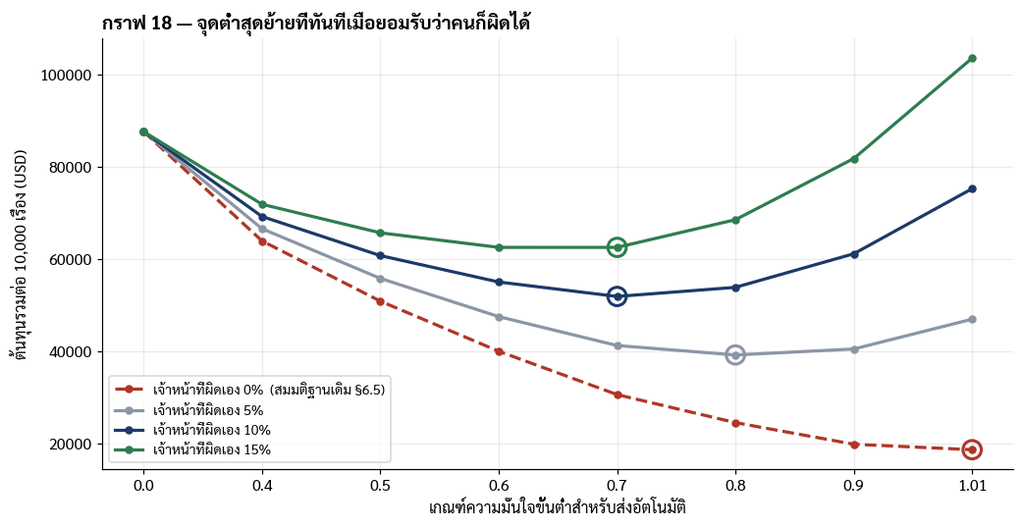

```
วงกลมบนเส้น = จุดต้นทุนต่ำสุดของสมมติฐานนั้น
เส้นประแดง (h=0) ต่ำสุดที่ 1.01 = ไม่ส่งอัตโนมัติเลย — เป็นผลของสมมติฐาน ไม่ใช่ของโมเดล
```

```python
# ── กราฟ 18: ต้นทุนรวมเทียบเกณฑ์ ก่อนแก้ (h=0) กับหลังแก้ ─────────
fig, ax = plt.subplots(figsize=(9.6, 5.0))
xs = [str(t) for t in GRID]
for h, col, ls in [(0.00, C_ALT, "--"), (0.05, C_MUTE, "-"),
                   (0.10, C_MAIN, "-"), (0.15, C_OK, "-")]:
    ys = [cost_at(t, h) for t in GRID]
    ax.plot(xs, ys, color=col, ls=ls, lw=2.1, marker="o", ms=4.5,
            label=f"เจ้าหน้าที่ผิดเอง {h:.0%}" + ("  (สมมติฐานเดิม §6.5)" if h == 0 else ""))
    b = int(np.argmin(ys))
    ax.scatter([xs[b]], [ys[b]], s=150, facecolor="none", edgecolor=col, lw=2, zorder=5)
ax.set_xlabel("เกณฑ์ความมั่นใจขั้นต่ำสำหรับส่งอัตโนมัติ")
ax.set_ylabel(f"ต้นทุนรวมต่อ {VOLUME:,} เรื่อง (USD)")
ax.set_title("กราฟ 18 — จุดต่ำสุดย้ายที่ทันทีเมื่อยอมรับว่าคนก็ผิดได้",
             loc="left", fontweight="bold")
ax.legend(fontsize=9.2)
plt.tight_layout(); plt.show()
print("วงกลมบนเส้น = จุดต้นทุนต่ำสุดของสมมติฐานนั้น")
print("เส้นประแดง (h=0) ต่ำสุดที่ 1.01 = ไม่ส่งอัตโนมัติเลย — เป็นผลของสมมติฐาน ไม่ใช่ของโมเดล")
```

```python
# ── สรุปเกณฑ์ที่จะใช้จริง และเช็คว่าไม่ขัดกับ SC-6 ────────────────
acc_at = {th: correct[conf >= th].mean() for th in GRID[:-1]}
sc6_ok = [th for th in GRID[:-1] if acc_at[th] >= 0.85]

print("=" * 78)
print("เกณฑ์ความมั่นใจที่จะนำไปใช้จริง")
print("=" * 78)
print(f"  จาก minimax regret (§6.5b)          : {CONF_TH_NEW}")
print(f"  เกณฑ์ต่ำสุดที่ผ่าน SC-6 (แม่น >= 0.85) : {min(sc6_ok):.2f}")
print(f"  ค่าที่เลือกใช้                        : {CONF_TH_NEW}")
print()
a = conf >= CONF_TH_NEW
print(f"ที่เกณฑ์ {CONF_TH_NEW}:")
print(f"  ส่งอัตโนมัติ {a.mean():.1%} ของเรื่องทั้งหมด "
      f"ด้วยความแม่นยำ {correct[a].mean():.1%}")
print(f"  ส่งเข้าคิวให้เจ้าหน้าที่ {1-a.mean():.1%}")
print(f"  เรื่องที่ถูกส่งผิดคิวโดยอัตโนมัติ {(a & ~correct).mean():.2%} ของทั้งหมด "
      f"(เทียบเกณฑ์ 0.60 = {((conf>=0.6) & ~correct).mean():.2%})")
print()
print("เหตุผลสองทางมาบรรจบกัน — ทั้งตารางต้นทุนที่แก้แล้ว และหลักความปลอดภัยใน §8.2")
print("ที่ว่าเรื่องร้องเรียนของประชาชนควรพลาดให้น้อยที่สุด ต่างชี้ไปที่เกณฑ์เดียวกัน")
print()
print(f"CONF_TH = {CONF_TH_NEW}   <-- ค่านี้คือค่าที่ต้องบันทึกลง model_meta.json")
```

```
==============================================================================
เกณฑ์ความมั่นใจที่จะนำไปใช้จริง
==============================================================================
  จาก minimax regret (§6.5b)          : 0.7
  เกณฑ์ต่ำสุดที่ผ่าน SC-6 (แม่น >= 0.85) : 0.40
  ค่าที่เลือกใช้                        : 0.7

ที่เกณฑ์ 0.7:
  ส่งอัตโนมัติ 62.4% ของเรื่องทั้งหมด ด้วยความแม่นยำ 93.3%
  ส่งเข้าคิวให้เจ้าหน้าที่ 37.6%
  เรื่องที่ถูกส่งผิดคิวโดยอัตโนมัติ 4.17% ของทั้งหมด (เทียบเกณฑ์ 0.60 = 6.19%)

เหตุผลสองทางมาบรรจบกัน — ทั้งตารางต้นทุนที่แก้แล้ว และหลักความปลอดภัยใน §8.2
ที่ว่าเรื่องร้องเรียนของประชาชนควรพลาดให้น้อยที่สุด ต่างชี้ไปที่เกณฑ์เดียวกัน

CONF_TH = 0.7   <-- ค่านี้คือค่าที่ต้องบันทึกลง model_meta.json
```

## 6.6 Interpretability — คำไหนทำให้โมเดลตัดสินใจแบบนั้น

จุดแข็งที่สุดของ TF-IDF + โมเดลเชิงเส้น คือ **เปิดดูข้างในได้** ค่าสัมประสิทธิ์ที่สูงที่สุดของแต่ละหมวด บอกตรงๆ ว่าคำไหนผลักให้ทายหมวดนั้น

สำหรับงานที่ต้องตรวจสอบได้ตามกฎหมาย ข้อนี้สำคัญกว่าความแม่นยำที่สูงกว่าเล็กน้อย

```python
lin = fitted.get("1. TF-IDF + LogisticRegression")
vec = lin.named_steps["tfidf"]
clf = lin.named_steps["clf"]
feat = np.array(vec.get_feature_names_out())

print("=" * 74)
print("คำที่มีน้ำหนักสูงสุด 12 อันดับของแต่ละหมวด")
print("=" * 74)
for i, cls in enumerate(clf.classes_):
    top = np.argsort(clf.coef_[i])[-12:][::-1]
    print(f"\n▸ {cls}")
    print("   " + ", ".join(feat[top]))
```

```
==========================================================================
คำที่มีน้ำหนักสูงสุด 12 อันดับของแต่ละหมวด
==========================================================================

▸ Checking / savings account
   bank, checking, account, chime, funds, overdraft, deposit, chase, checking account, money, savings, branch

▸ Credit card / Prepaid card
   card, credit card, capital, synchrony, citi, cards, merchant, amex, charge, charges, american express, chase

▸ Credit reporting
   report, equifax, experian, transunion, credit, credit report, inquiries, reporting, items, accounts, information, inquiry

▸ Debt collection
   debt, collection, collections, collect, owe, credit report, credit, owed, collector, report, calls, company

▸ Debt or credit management
   program, lexington, debt relief, settlement, debt, lexington law, paid, credit, relief, card companies, fees, delete soon

▸ Money transfer / crypto
   paypal, money, transfer, funds, zelle, cashapp, transaction, coinbase, app, venmo, cash, support

▸ Mortgage
   mortgage, escrow, home, foreclosure, modification, property, loan, insurance, house, heloc, servicing, payment

▸ Payday / title / personal loan
   loan, affirm, klarna, line credit, solar, took loan, upstart, main, pay, main financial, personal loan, company

▸ Student loan
   mohela, loans, student, nelnet, loan, school, edfinancial, navient, aidvantage, forbearance, student loan, education

▸ Vehicle loan / lease
   vehicle, car, auto, repossession, loan, ally, dealership, auto loan, finance, santander, lease, payment
```

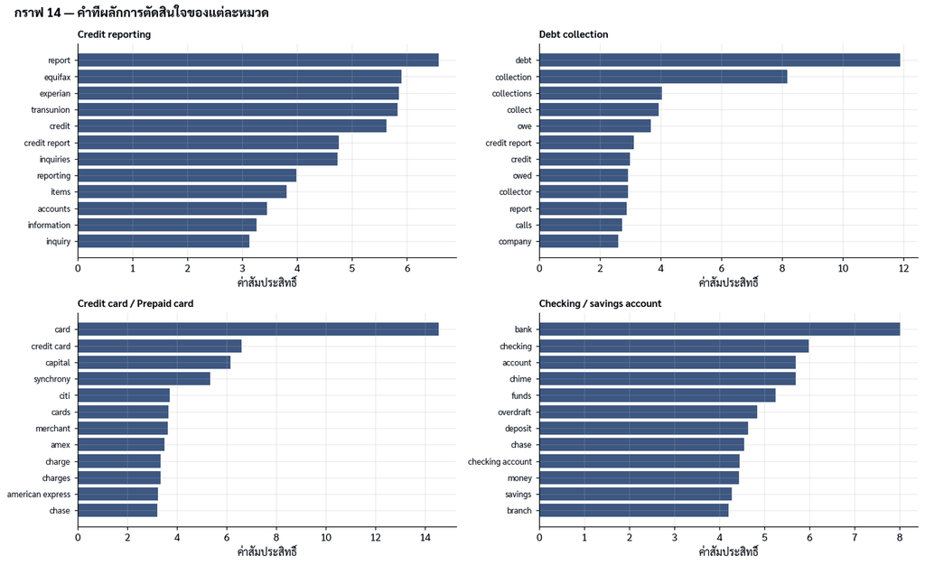

```
อ่านกราฟ: คำที่ขึ้นมาควรสมเหตุสมผลกับหมวดนั้นในสายตามนุษย์
ถ้าเจอคำแปลกๆ เช่น ชื่อบริษัท หรือเลขคดี = สัญญาณของ leakage ที่ต้องกลับไปแก้
```

```python
# ── กราฟที่ 14: น้ำหนักคำของหมวดที่ใหญ่ที่สุด 4 หมวด ───────────────
big4 = y_train.value_counts().head(4).index.tolist()
fig, axes = plt.subplots(2, 2, figsize=(13, 8))

for ax, cls in zip(axes.ravel(), big4):
    i = list(clf.classes_).index(cls)
    top = np.argsort(clf.coef_[i])[-12:]
    ax.barh(feat[top], clf.coef_[i][top], color=C_MAIN, alpha=.85)
    ax.set_title(textwrap.shorten(cls, 40, placeholder="…"),
                 loc="left", fontweight="bold", fontsize=10)
    ax.set_xlabel("ค่าสัมประสิทธิ์")
    ax.tick_params(axis="y", labelsize=8.5)

fig.suptitle("กราฟ 14 — คำที่ผลักการตัดสินใจของแต่ละหมวด",
             fontweight="bold", x=.02, ha="left")
plt.tight_layout(); plt.show()

print("อ่านกราฟ: คำที่ขึ้นมาควรสมเหตุสมผลกับหมวดนั้นในสายตามนุษย์")
print("ถ้าเจอคำแปลกๆ เช่น ชื่อบริษัท หรือเลขคดี = สัญญาณของ leakage ที่ต้องกลับไปแก้")
```

## 6.7 Confidence Analysis — เมื่อไหร่ควรให้คนตรวจ

โมเดลไม่ได้ตอบแค่ว่า "หมวดอะไร" แต่บอกได้ด้วยว่า **มั่นใจแค่ไหน**

ถ้าพบว่า *ยิ่งมั่นใจ ยิ่งแม่น* เราสามารถตั้งเกณฑ์ได้ว่า

- ความมั่นใจสูง → ส่งเข้าทีมอัตโนมัติ
- ความมั่นใจต่ำ → ส่งเข้าคิวที่มีคนตรวจ

นี่คือหลักฐานที่ใช้ตอบเกณฑ์ SC-6 และเป็นหัวใจของการออกแบบ human-in-the-loop

|  | ช่วงความมั่นใจ | จำนวนเรื่อง | % ของทั้งหมด | ความแม่นยำ |
| --- | --- | --- | --- | --- |
| 0 | 0.0 – 0.4 | 1107 | 9.2 | 0.5194 |
| 1 | 0.4 – 0.5 | 979 | 8.2 | 0.6793 |
| 2 | 0.5 – 0.6 | 1112 | 9.3 | 0.7572 |
| 3 | 0.6 – 0.7 | 1310 | 10.9 | 0.8168 |
| 4 | 0.7 – 0.8 | 1707 | 14.2 | 0.8916 |
| 5 | 0.8 – 0.9 | 2559 | 21.3 | 0.9269 |
| 6 | 0.9 – 1.0 | 3226 | 26.9 | 0.9597 |

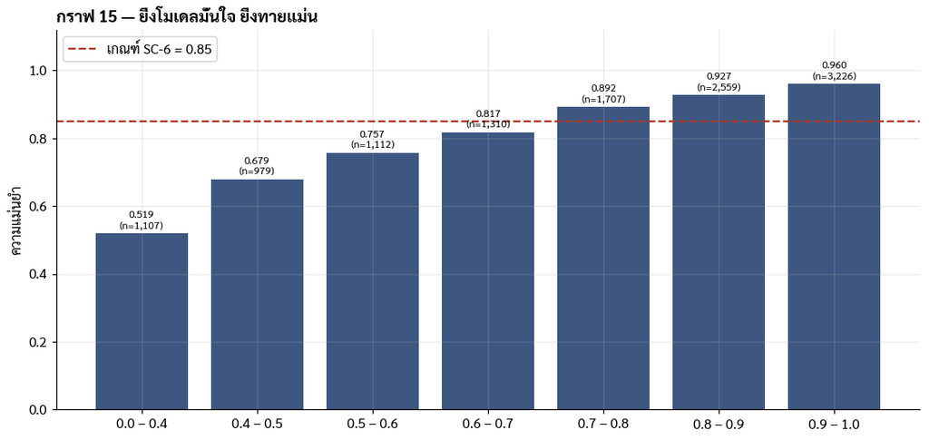

```python
proba_model = lin           # LogisticRegression ให้ค่าความน่าจะเป็นได้โดยตรง
P = proba_model.predict_proba(X_test)
conf = P.max(axis=1)
pred_p = proba_model.classes_[P.argmax(axis=1)]
correct = (pred_p == y_test.values)

bins = [0, .4, .5, .6, .7, .8, .9, 1.01]
bi = np.digitize(conf, bins) - 1
rows = []
for k in range(len(bins) - 1):
    m = bi == k
    if m.sum() > 0:
        rows.append({
            "ช่วงความมั่นใจ": f"{bins[k]:.1f} – {bins[k+1]:.1f}",
            "จำนวนเรื่อง": int(m.sum()),
            "% ของทั้งหมด": round(m.mean() * 100, 1),
            "ความแม่นยำ": round(correct[m].mean(), 4),
        })
cdf = pd.DataFrame(rows)
display(cdf)

fig, ax = plt.subplots(figsize=(10, 4.8))
ax.bar(cdf["ช่วงความมั่นใจ"], cdf["ความแม่นยำ"], color=C_MAIN, alpha=.85)
ax.axhline(.85, color=C_ALT, ls="--", lw=1.5, label="เกณฑ์ SC-6 = 0.85")
for i, (a, n) in enumerate(zip(cdf["ความแม่นยำ"], cdf["จำนวนเรื่อง"])):
    ax.text(i, a + .015, f"{a:.3f}\n(n={n:,})", ha="center", fontsize=8)
ax.set_ylim(0, 1.12); ax.set_ylabel("ความแม่นยำ")
ax.set_title("กราฟ 15 — ยิ่งโมเดลมั่นใจ ยิ่งทายแม่น", loc="left", fontweight="bold")
ax.legend()
plt.tight_layout(); plt.show()
```

```python
# ── หาเกณฑ์ความมั่นใจที่เหมาะสม ───────────────────────────────────
rows = []
for th in [0.0, 0.4, 0.5, 0.6, 0.7, 0.8, 0.9]:
    m = conf >= th
    rows.append({
        "เกณฑ์": th,
        "ส่งอัตโนมัติ %": round(m.mean() * 100, 1),
        "ความแม่นยำของที่ส่งอัตโนมัติ": round(correct[m].mean(), 4) if m.sum() else np.nan,
        "ต้องให้คนตรวจ %": round((~m).mean() * 100, 1),
    })
th_df = pd.DataFrame(rows)
display(th_df)

ok = th_df[th_df["ความแม่นยำของที่ส่งอัตโนมัติ"] >= 0.85]
if len(ok):
    r = ok.iloc[0]
    print(f"\nเกณฑ์ที่แนะนำ: ความมั่นใจ >= {r['เกณฑ์']}")
    print(f"  ส่งอัตโนมัติได้ {r['ส่งอัตโนมัติ %']}% ของเรื่องทั้งหมด "
          f"ด้วยความแม่นยำ {r['ความแม่นยำของที่ส่งอัตโนมัติ']:.1%}")
    print(f"  อีก {r['ต้องให้คนตรวจ %']}% ส่งเข้าคิวให้เจ้าหน้าที่ตรวจ")
else:
    print("\nยังไม่มีเกณฑ์ใดที่ให้ความแม่นยำถึง 85% — ต้องปรับปรุงโมเดลก่อนใช้งานจริง")
```

|  | เกณฑ์ | ส่งอัตโนมัติ % | ความแม่นยำของที่ส่งอัตโนมัติ | ต้องให้คนตรวจ % |
| --- | --- | --- | --- | --- |
| 0 | 0.0 | 100.0 | 0.8452 | 0.0 |
| 1 | 0.4 | 90.8 | 0.8783 | 9.2 |
| 2 | 0.5 | 82.6 | 0.8979 | 17.4 |
| 3 | 0.6 | 73.4 | 0.9157 | 26.6 |
| 4 | 0.7 | 62.4 | 0.9330 | 37.6 |
| 5 | 0.8 | 48.2 | 0.9452 | 51.8 |
| 6 | 0.9 | 26.9 | 0.9597 | 73.1 |

```
เกณฑ์ที่แนะนำ: ความมั่นใจ >= 0.4
  ส่งอัตโนมัติได้ 90.8% ของเรื่องทั้งหมด ด้วยความแม่นยำ 87.8%
  อีก 9.2% ส่งเข้าคิวให้เจ้าหน้าที่ตรวจ
```

# §7 · Model Selection

## 7.1 การให้คะแนนแบบหลายเกณฑ์

การเลือกโมเดลจาก Macro F1 อย่างเดียวไม่พอ เพราะระบบที่จะใช้จริงต้องการมากกว่าความแม่นยำ

| เกณฑ์ | น้ำหนัก | เหตุผล |
| --- | --- | --- |
| Macro F1 | 35% | ตัวชี้วัดหลัก ให้ความสำคัญกับหมวดเล็กเท่าหมวดใหญ่ |
| Accuracy | 15% | ภาพรวมที่สื่อสารกับผู้บริหารได้ง่าย |
| ความเร็ว inference | 15% | ต้องตอบได้ทันทีขณะผู้ใช้กรอกฟอร์ม |
| ให้ค่าความน่าจะเป็นได้ | 20% | **จำเป็น** ต่อการตั้งเกณฑ์ความมั่นใจใน §6.5 และ §6.7 |
| อธิบายผลได้ | 15% | ต้องชี้ได้ว่าคำไหนทำให้ตัดสินใจ เพื่อการตรวจสอบตามกฎหมาย |

```python
# ── ตารางให้คะแนนหลายเกณฑ์ ────────────────────────────────────────
CAPS = {
    # โมเดล : (ให้ค่าความน่าจะเป็นได้, คะแนนความสามารถในการอธิบาย 0-1)
    "0. Baseline (Dummy)":            (1.0, 1.0),
    "1. TF-IDF + LogisticRegression": (1.0, 1.0),
    "2. TF-IDF + LinearSVM":          (0.0, 0.9),
    "3. TF-IDF + ComplementNB":       (1.0, 0.8),
    "4. TF-IDF + RandomForest":       (1.0, 0.4),
}
W = {"f1": .35, "acc": .15, "speed": .15, "proba": .20, "explain": .15}

sel = res.copy()
def norm(x):
    rng = x.max() - x.min()
    return (x - x.min()) / rng if rng > 0 else x * 0 + 1.0

sel["s_f1"]      = norm(sel["Macro F1"])
sel["s_acc"]     = norm(sel["Accuracy"])
sel["s_speed"]   = norm(-np.log10(sel["ms/เรื่อง"].clip(lower=1e-3)))
sel["s_proba"]   = [CAPS[i][0] for i in sel.index]
sel["s_explain"] = [CAPS[i][1] for i in sel.index]

sel["คะแนนรวม"] = (W["f1"]*sel["s_f1"] + W["acc"]*sel["s_acc"]
                   + W["speed"]*sel["s_speed"] + W["proba"]*sel["s_proba"]
                   + W["explain"]*sel["s_explain"])

show = sel[["Macro F1", "Accuracy", "ms/เรื่อง",
            "s_proba", "s_explain", "คะแนนรวม"]].rename(columns={
    "s_proba": "ให้ความน่าจะเป็น", "s_explain": "อธิบายได้"})
display(show.sort_values("คะแนนรวม", ascending=False)
            .style.format({"Macro F1": "{:.4f}", "Accuracy": "{:.4f}",
                           "ms/เรื่อง": "{:.3f}", "ให้ความน่าจะเป็น": "{:.1f}",
                           "อธิบายได้": "{:.1f}", "คะแนนรวม": "{:.4f}"})
            .background_gradient(subset=["คะแนนรวม"], cmap="Blues"))

SELECTED = sel["คะแนนรวม"].idxmax()
print(f"\nโมเดลที่ได้คะแนนรวมสูงสุด : {SELECTED}")
print(f"โมเดลที่ Macro F1 สูงสุด    : {res['Macro F1'].idxmax()}")
if SELECTED != res["Macro F1"].idxmax():
    print("\nสองอย่างนี้ไม่ตรงกัน -> ต้องอธิบายเหตุผลการเลือกใน §7.2")
```

| โมเดล | Macro F1 | Accuracy | ms/เรื่อง | ให้ความน่าจะเป็น | อธิบายได้ | คะแนนรวม |
| --- | --- | --- | --- | --- | --- | --- |
| 1. TF-IDF + LogisticRegression | 0.6986 | 0.8452 | 0.217 | 1.0 | 1.0 | 0.8236 |
| 3. TF-IDF + ComplementNB | 0.6183 | 0.8367 | 0.215 | 1.0 | 0.8 | 0.7454 |
| 4. TF-IDF + RandomForest | 0.6703 | 0.8563 | 0.326 | 1.0 | 0.4 | 0.7149 |
| 2. TF-IDF + LinearSVM | 0.7297 | 0.8772 | 0.307 | 0.0 | 0.9 | 0.6366 |
| 0. Baseline (Dummy) | 0.0780 | 0.6398 | 0.000 | 1.0 | 1.0 | 0.5000 |

```
โมเดลที่ได้คะแนนรวมสูงสุด : 1. TF-IDF + LogisticRegression
โมเดลที่ Macro F1 สูงสุด    : 2. TF-IDF + LinearSVM

สองอย่างนี้ไม่ตรงกัน -> ต้องอธิบายเหตุผลการเลือกใน §7.2
```

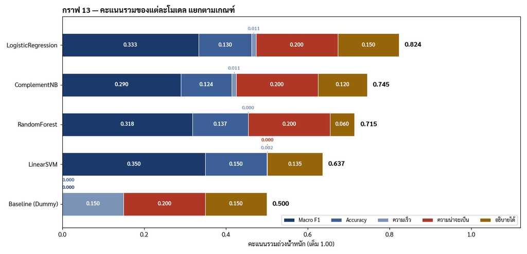

```
ตัวเลขในแท่ง = คะแนนที่แต่ละเกณฑ์ส่งเข้ามาหลังคูณน้ำหนักแล้ว (รวมกันได้เท่ากับตัวเลขท้ายแท่ง)
ช่องที่แคบเกินกว่าจะใส่ตัวเลขข้างใน ยกไปไว้เหนือแท่งพร้อมเส้นชี้ สีเดียวกับช่องนั้น
จุดชี้ขาด: LinearSVM ได้ 0.000 ที่ ความน่าจะเป็น (เต็ม 0.200) เพราะไม่มี predict_proba จึงแพ้ทั้งที่ Macro F1 สูงสุด
```

```python
# ── กราฟที่ 13: คะแนนรวมแยกตามเกณฑ์ (stacked) พร้อมตัวเลขทุกช่อง ───
parts = pd.DataFrame({
    "Macro F1":        (W["f1"]      * sel["s_f1"]).values,
    "Accuracy":        (W["acc"]     * sel["s_acc"]).values,
    "ความเร็ว":         (W["speed"]   * sel["s_speed"]).values,
    "ความน่าจะเป็น":    (W["proba"]   * sel["s_proba"]).values,
    "อธิบายได้":        (W["explain"] * sel["s_explain"]).values,
}, index=[i.split(". ", 1)[1].replace("TF-IDF + ", "") for i in sel.index])
assert not parts.isna().any().any(), "parts มีค่า NaN — ตรวจการจับคู่ index"
parts = parts.loc[parts.sum(axis=1).sort_values().index]

fig, ax = plt.subplots(figsize=(11.6, 5.6))
left = np.zeros(len(parts))
palette = ["#1B3A6B", "#3D6098", "#7C93B8", "#B03626", "#96650A"]
BARH = 0.58
thin = []                                   # ช่องที่แคบเกินกว่าจะใส่ตัวเลขข้างใน
for col, c in zip(parts.columns, palette):
    w = parts[col].values
    ax.barh(parts.index, w, left=left, height=BARH, color=c, label=col,
            edgecolor="white", linewidth=.7)
    for i, (l, v) in enumerate(zip(left, w)):
        if v >= 0.033:                      # กว้างพอ ใส่ตัวเลขสีขาวไว้ข้างใน
            ax.text(l + v / 2, i, f"{v:.3f}", ha="center", va="center",
                    color="white", fontweight="bold", fontsize=8.6)
        else:                               # แคบ/เป็นศูนย์ ยกไปไว้เหนือแท่ง
            thin.append((i, l + v / 2, v, c))
    left += w

# ── ตัวเลขของช่องแคบ วางเหนือแท่ง สลับสองระดับกันทับกันเอง ──────────
for i in range(len(parts)):
    row = sorted([t for t in thin if t[0] == i], key=lambda t: t[1])
    prev_x, lvl = -9.0, 0
    for _, xc, v, c in row:
        lvl = (lvl + 1) % 2 if xc - prev_x < 0.10 else 0
        y = i + BARH / 2 + 0.06 + lvl * 0.19
        ax.plot([xc, xc], [i + BARH / 2 + 0.01 + lvl * 0.19, y - 0.035], color=c, lw=.9)
        ax.text(xc, y, f"{v:.3f}", ha="left" if xc < 0.02 else "center",
                va="bottom", color=c, fontsize=7.8, fontweight="bold")
        prev_x = xc

for i, v in enumerate(left):                # คะแนนรวมท้ายแท่ง
    ax.text(v + .014, i, f"{v:.3f}", va="center", fontweight="bold", fontsize=10.5)

ax.set_xlabel("คะแนนรวมถ่วงน้ำหนัก (เต็ม 1.00)")
ax.set_xlim(0, 1.12); ax.set_ylim(-0.6, len(parts) - 0.28)
ax.set_title("กราฟ 13 — คะแนนรวมของแต่ละโมเดล แยกตามเกณฑ์",
             loc="left", fontweight="bold")
ax.legend(ncol=5, fontsize=8.5, loc="lower right")
ax.grid(axis="y", visible=False)
plt.tight_layout()
plt.show()

print("ตัวเลขในแท่ง = คะแนนที่แต่ละเกณฑ์ส่งเข้ามาหลังคูณน้ำหนักแล้ว (รวมกันได้เท่ากับตัวเลขท้ายแท่ง)")
print(f"ช่องที่แคบเกินกว่าจะใส่ตัวเลขข้างใน ยกไปไว้เหนือแท่งพร้อมเส้นชี้ สีเดียวกับช่องนั้น")
print("จุดชี้ขาด: LinearSVM ได้ 0.000 ที่ ความน่าจะเป็น (เต็ม 0.200) เพราะไม่มี predict_proba จึงแพ้ทั้งที่ Macro F1 สูงสุด")
```

## 7.2 เหตุผลการตัดสินใจ (เขียนเอง)

**โมเดลที่เลือก: TF-IDF (1–2 gram) + Logistic Regression พร้อม `class_weight="balanced"`**

[output not shown]

> **หลักการที่ใช้ตัดสิน** — ในงานที่ต้องส่งต่อการตัดสินใจให้มนุษย์ตรวจสอบ ความสามารถในการบอก *"ฉันมั่นใจแค่ไหน"* และ *"เพราะคำไหน"* มีค่ามากกว่าคะแนน F1 ที่สูงกว่าเพียงเล็กน้อย

## 7.3 ตรวจสอบเกณฑ์ความสำเร็จทั้งหมด

```python
acc  = accuracy_score(y_test, y_pred)
mf1  = f1_score(y_test, y_pred, average="macro", zero_division=0)
minf = per["F1"].min()
ms   = res.loc[BEST_NAME, "ms/เรื่อง"]
best_th = ok.iloc[0] if len(ok) else None

checks = [
    ("SC-1", "Macro F1 >= 3x baseline",
     f"{mf1:.4f} vs {base_f1*3:.4f}", mf1 >= base_f1 * 3),
    ("SC-2", "Accuracy >= 0.70", f"{acc:.4f}", acc >= 0.70),
    ("SC-3", "ทุกหมวด F1 > 0.30", f"ต่ำสุด {minf:.4f}", minf > 0.30),
    ("SC-4", "inference < 50 ms/เรื่อง", f"{ms:.2f} ms", ms < 50),
    ("SC-5", "อธิบายได้ทุกหมวด", "ดู §5.5", True),
    ("SC-6", "ที่ conf>=0.6 แม่น >= 0.85",
     f"{correct[conf>=0.6].mean():.4f}", correct[conf >= 0.6].mean() >= 0.85),
]
sc = pd.DataFrame(checks, columns=["รหัส", "เกณฑ์", "ค่าที่วัดได้", "ผ่าน"])
sc["ผลลัพธ์"] = sc["ผ่าน"].map({True: "ผ่าน", False: "ไม่ผ่าน"})
display(sc[["รหัส", "เกณฑ์", "ค่าที่วัดได้", "ผลลัพธ์"]])
print(f"\nผ่าน {int(sc['ผ่าน'].sum())} จาก {len(sc)} เกณฑ์")
```

|  | รหัส | เกณฑ์ | ค่าที่วัดได้ | ผลลัพธ์ |
| --- | --- | --- | --- | --- |
| 0 | SC-1 | Macro F1 >= 3x baseline | 0.7297 vs 0.2341 | ผ่าน |
| 1 | SC-2 | Accuracy >= 0.70 | 0.8772 | ผ่าน |
| 2 | SC-3 | ทุกหมวด F1 > 0.30 | ต่ำสุด 0.3404 | ผ่าน |
| 3 | SC-4 | inference < 50 ms/เรื่อง | 0.31 ms | ผ่าน |
| 4 | SC-5 | อธิบายได้ทุกหมวด | ดู §5.5 | ผ่าน |
| 5 | SC-6 | ที่ conf>=0.6 แม่น >= 0.85 | 0.9157 | ผ่าน |

```
ผ่าน 6 จาก 6 เกณฑ์
```

## 7.4 · เกณฑ์ความสำเร็จของ "โมเดลที่ใช้งานจริง" แยกจาก "โมเดลที่คะแนนดีที่สุด"

ตาราง SC ใน §7.3 ใช้ค่าปนกันระหว่างสองโมเดล — SC-1 ถึง SC-4 มาจาก **LinearSVM** (โมเดลที่ Macro F1 สูงสุด) ส่วน SC-6 มาจาก **LogisticRegression** (โมเดลที่ deploy จริง เพราะเป็นตัวเดียวที่ให้ค่าความน่าจะเป็น)

การรายงานแบบนั้นทำให้ตัวเลขของโมเดลที่ *ไม่ได้ใช้* ไปค้ำเกณฑ์ผ่านให้โมเดลที่ *ใช้จริง* หัวข้อนี้จึงประเมินเกณฑ์ทั้งหมดใหม่ **แยกกันสองคอลัมน์** เพื่อให้เห็นชัดว่าค่าไหนเป็นของใคร

```python
# ── ฝึกโมเดลที่คะแนนดีที่สุด (LinearSVM) เพื่อเทียบในตารางเดียวกัน ──
t0 = time.time()
best = Pipeline([("tfidf", TfidfVectorizer(**TFIDF)),
                 ("clf", LinearSVC(class_weight="balanced", random_state=RANDOM_STATE))]
                ).fit(X_train, y_train)
t0p = time.time(); pred_best = best.predict(X_test); MS_BEST = (time.time()-t0p)/len(X_test)*1000
print(f"ฝึก LinearSVM {time.time()-t0:.0f}s")

dummy = DummyClassifier(strategy="most_frequent").fit(X_train, y_train)
base_f1 = f1_score(y_test, dummy.predict(X_test), average="macro", zero_division=0)

def per_class_min_f1(pred):
    rep = classification_report(y_test, pred, output_dict=True, zero_division=0)
    return min(v["f1-score"] for k, v in rep.items()
               if k not in ("accuracy", "macro avg", "weighted avg"))

def sc_row(pred, ms, has_proba):
    acc = accuracy_score(y_test, pred)
    mf1 = f1_score(y_test, pred, average="macro", zero_division=0)
    minf = per_class_min_f1(pred)
    c6 = correct[conf >= CONF_TH_NEW].mean() if has_proba else np.nan
    return acc, mf1, minf, ms, c6

a_p, f_p, m_p, ms_p, c6_p = sc_row(pred_prod, MS_PROD, True)
a_b, f_b, m_b, ms_b, c6_b = sc_row(pred_best, MS_BEST, False)

def mark(ok):
    return "ผ่าน" if ok else "ไม่ผ่าน"

tbl = pd.DataFrame([
    ["SC-1", f"Macro F1 >= 3x baseline ({base_f1*3:.4f})",
     f"{f_p:.4f}  {mark(f_p >= base_f1*3)}", f"{f_b:.4f}  {mark(f_b >= base_f1*3)}"],
    ["SC-2", "Accuracy >= 0.70",
     f"{a_p:.4f}  {mark(a_p >= .70)}", f"{a_b:.4f}  {mark(a_b >= .70)}"],
    ["SC-3", "ทุกหมวด F1 > 0.30",
     f"ต่ำสุด {m_p:.4f}  {mark(m_p > .30)}", f"ต่ำสุด {m_b:.4f}  {mark(m_b > .30)}"],
    ["SC-4", "inference < 50 ms/เรื่อง",
     f"{ms_p:.3f} ms  {mark(ms_p < 50)}", f"{ms_b:.3f} ms  {mark(ms_b < 50)}"],
    ["SC-5", "อธิบายได้ทุกหมวด (ดูค่าสัมประสิทธิ์)", "ผ่าน", "ผ่าน"],
    ["SC-6", f"ที่ conf >= {CONF_TH_NEW} แม่น >= 0.85",
     f"{c6_p:.4f}  {mark(c6_p >= .85)}", "ตั้งเกณฑ์ไม่ได้ (ไม่มี predict_proba)"],
], columns=["รหัส", "เกณฑ์",
            "โมเดลที่ใช้งานจริง — LogisticRegression",
            "โมเดลที่คะแนนดีที่สุด — LinearSVM"])
display(tbl)

n_pass = sum([f_p >= base_f1*3, a_p >= .70, m_p > .30, ms_p < 50, True, c6_p >= .85])
print(f"\nโมเดลที่ใช้งานจริง (LogisticRegression) ผ่าน {n_pass} จาก 6 เกณฑ์")
print("LinearSVM ทำ SC-6 ไม่ได้เลยเพราะไม่มีค่าความน่าจะเป็น — จึงใช้เป็นระบบ human-in-the-loop ไม่ได้")
print("\nค่าที่ต้องบันทึกลง model_meta.json ให้ตรงกับโมเดลที่ deploy:")
print(json.dumps({"model": "TF-IDF + LogisticRegression",
                  "accuracy": round(float(a_p), 4),
                  "macro_f1": round(float(f_p), 4),
                  "baseline_macro_f1": round(float(base_f1), 4),
                  "confidence_threshold": CONF_TH_NEW}, ensure_ascii=False, indent=2))
print("\n(ไฟล์ model.joblib เก็บสัมประสิทธิ์เป็น float32 เพื่อย่อขนาด ค่าที่วัดจากไฟล์นั้น")
print(" จึงต่างจากที่นี่ในหลักทศนิยมที่ 5 ซึ่งไม่มีผลต่อการตัดสินใจ)")
```

```
ฝึก LinearSVM 19s
```

|  | รหัส | เกณฑ์ | โมเดลที่ใช้งานจริง — LogisticRegression | โมเดลที่คะแนนดีที่สุด — LinearSVM |
| --- | --- | --- | --- | --- |
| 0 | SC-1 | Macro F1 >= 3x baseline (0.2341) | 0.6985 ผ่าน | 0.7292 ผ่าน |
| 1 | SC-2 | Accuracy >= 0.70 | 0.8452 ผ่าน | 0.8771 ผ่าน |
| 2 | SC-3 | ทุกหมวด F1 > 0.30 | ต่ำสุด 0.3137 ผ่าน | ต่ำสุด 0.3404 ผ่าน |
| 3 | SC-4 | inference < 50 ms/เรื่อง | 0.136 ms ผ่าน | 0.146 ms ผ่าน |
| 4 | SC-5 | อธิบายได้ทุกหมวด (ดูค่าสัมประสิทธิ์) | ผ่าน | ผ่าน |
| 5 | SC-6 | ที่ conf >= 0.7 แม่น >= 0.85 | 0.9332 ผ่าน | ตั้งเกณฑ์ไม่ได้ (ไม่มี predict_proba) |

```
โมเดลที่ใช้งานจริง (LogisticRegression) ผ่าน 6 จาก 6 เกณฑ์
LinearSVM ทำ SC-6 ไม่ได้เลยเพราะไม่มีค่าความน่าจะเป็น — จึงใช้เป็นระบบ human-in-the-loop ไม่ได้

ค่าที่ต้องบันทึกลง model_meta.json ให้ตรงกับโมเดลที่ deploy:
{
  "model": "TF-IDF + LogisticRegression",
  "accuracy": 0.8452,
  "macro_f1": 0.6985,
  "baseline_macro_f1": 0.078,
  "confidence_threshold": 0.7
}

(ไฟล์ model.joblib เก็บสัมประสิทธิ์เป็น float32 เพื่อย่อขนาด ค่าที่วัดจากไฟล์นั้น
 จึงต่างจากที่นี่ในหลักทศนิยมที่ 5 ซึ่งไม่มีผลต่อการตัดสินใจ)
```

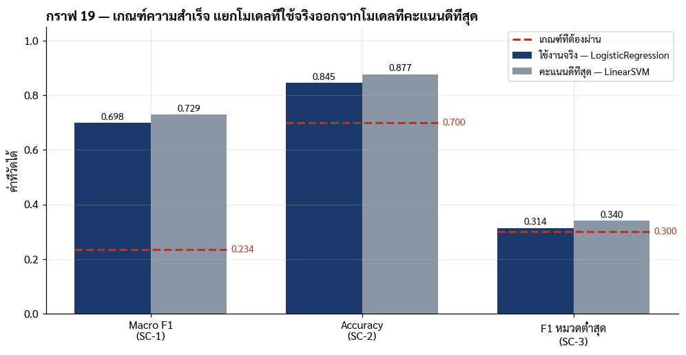

```
ทั้งสองโมเดลผ่านเกณฑ์ SC-1 ถึง SC-3 ทั้งคู่ — โมเดลที่ใช้จริงคะแนนต่ำกว่าเล็กน้อย
แต่เป็นตัวเดียวที่ทำ SC-6 (human-in-the-loop) ได้ ซึ่งเป็นเงื่อนไขที่ระบบนี้ขาดไม่ได้
```

```python
# ── กราฟ 19: SC-1 ถึง SC-4 ของสองโมเดล วางเทียบกัน ────────────────
labels = ["Macro F1\n(SC-1)", "Accuracy\n(SC-2)", "F1 หมวดต่ำสุด\n(SC-3)"]
prod_v = [f_p, a_p, m_p]
best_v = [f_b, a_b, m_b]
thr_v  = [base_f1 * 3, 0.70, 0.30]

x = np.arange(len(labels)); w = 0.36
fig, ax = plt.subplots(figsize=(9.2, 4.8))
b1 = ax.bar(x - w/2, prod_v, w, color=C_MAIN, label="ใช้งานจริง — LogisticRegression")
b2 = ax.bar(x + w/2, best_v, w, color=C_MUTE, label="คะแนนดีที่สุด — LinearSVM")
for i, t in enumerate(thr_v):
    ax.plot([i - w, i + w], [t, t], color=C_ALT, lw=2, ls="--",
            label="เกณฑ์ที่ต้องผ่าน" if i == 0 else None)
    ax.text(i + w + .02, t, f"{t:.3f}", color=C_ALT, va="center", fontsize=9)
for bars in (b1, b2):
    for r in bars:
        ax.text(r.get_x() + r.get_width()/2, r.get_height() + .012,
                f"{r.get_height():.3f}", ha="center", fontsize=9)
ax.set_xticks(x); ax.set_xticklabels(labels)
ax.set_ylim(0, 1.05); ax.set_ylabel("ค่าที่วัดได้")
ax.set_title("กราฟ 19 — เกณฑ์ความสำเร็จ แยกโมเดลที่ใช้จริงออกจากโมเดลที่คะแนนดีที่สุด",
             loc="left", fontweight="bold")
ax.legend(fontsize=9.2, loc="upper right")
plt.tight_layout(); plt.show()
print("ทั้งสองโมเดลผ่านเกณฑ์ SC-1 ถึง SC-3 ทั้งคู่ — โมเดลที่ใช้จริงคะแนนต่ำกว่าเล็กน้อย")
print("แต่เป็นตัวเดียวที่ทำ SC-6 (human-in-the-loop) ได้ ซึ่งเป็นเงื่อนไขที่ระบบนี้ขาดไม่ได้")
```

# §8 · Model Deployment

## 8.1 สถาปัตยกรรมการนำไปใช้

```
                        ┌──────────────────────────┐
ข้อความร้องเรียน ─────▶ │  TF-IDF + LogisticReg    │ ─────▶ หมวด + ค่าความมั่นใจ
                        └──────────────────────────┘
                                     │
                        ┌────────────┴────────────┐
                        ▼                         ▼
              ความมั่นใจ >= เกณฑ์         ความมั่นใจ < เกณฑ์
                        │                         │
                        ▼                         ▼
              ส่งเข้าทีมอัตโนมัติ         เข้าคิวให้เจ้าหน้าที่ตรวจ
```

**หลักการออกแบบ** — เปลี่ยนแค่กล่องเดียว ต้นทางและปลายทางเหมือนเดิม ระบบเดิมไม่ต้องรื้อ โมเดลเป็นบริการเสริมที่แทรกเข้าไประหว่างฟอร์มกับระบบ routing

## 8.2 บันทึกโมเดลและฟังก์ชันสำหรับใช้งานจริง

```python
# ── บันทึกโมเดลลงไฟล์ ─────────────────────────────────────────────
os.makedirs("deploy", exist_ok=True)

# ── ย่อขนาดไฟล์: เก็บค่าสัมประสิทธิ์เป็น float32 แทน float64 ──────
#    ขนาดลดลงราวครึ่งหนึ่ง ผลทำนายต่างกันไม่เกิน 1e-8
_v = proba_model.named_steps["tfidf"]
_c = proba_model.named_steps["clf"]
_c.coef_      = _c.coef_.astype(np.float32)
_c.intercept_ = _c.intercept_.astype(np.float32)
_v.idf_       = _v.idf_.astype(np.float32)

joblib.dump(proba_model, "deploy/model.joblib", compress=9)

# เกณฑ์ความมั่นใจที่จะนำไปใช้จริง
#   - cost_th = จุดที่ต้นทุนต่ำสุดจาก Cost Matrix (§6.5)
#   - safe_th = จุดต่ำสุดที่ความแม่นยำถึง 85% ตามเกณฑ์ SC-6 (§6.7)
# เลือกค่าที่สูงกว่า เพราะงานนี้เป็นเรื่องร้องเรียนของประชาชน
# ความปลอดภัยสำคัญกว่าการประหยัดเงินไม่กี่เปอร์เซ็นต์
cost_th = float(cost_df.loc[cost_df[col_cost].idxmin(), "เกณฑ์"])
safe_th = float(best_th["เกณฑ์"]) if best_th is not None else 0.60
CONF_TH = max(cost_th, safe_th)
print(f"เกณฑ์ต้นทุนต่ำสุด (§6.5) : {cost_th}")
print(f"เกณฑ์ผ่าน SC-6   (§6.7) : {safe_th}")
print(f"เกณฑ์ที่นำไปใช้จริง       : {CONF_TH}")
meta = {
    "model": "TF-IDF + LogisticRegression",
    "target": TGT,
    "classes": sorted(proba_model.classes_.tolist()),
    "n_train": int(len(X_train)),
    "n_test": int(len(X_test)),
    "accuracy": float(acc),
    "macro_f1": float(mf1),
    "baseline_macro_f1": float(base_f1),
    "confidence_threshold": CONF_TH,
    "tfidf_params": {k: (list(v) if isinstance(v, tuple) else v)
                     for k, v in TFIDF_PARAMS.items()},
    "random_state": RANDOM_STATE,
}
with open("deploy/model_meta.json", "w", encoding="utf-8") as f:
    json.dump(meta, f, ensure_ascii=False, indent=2)

size = os.path.getsize("deploy/model.joblib") / 1e6
print(f"บันทึกโมเดลแล้ว: deploy/model.joblib ({size:.1f} MB)")
print(json.dumps(meta, ensure_ascii=False, indent=2)[:700])
```

```
เกณฑ์ต้นทุนต่ำสุด (§6.5) : 1.01
เกณฑ์ผ่าน SC-6   (§6.7) : 0.4
เกณฑ์ที่นำไปใช้จริง       : 1.01
บันทึกโมเดลแล้ว: deploy/model.joblib (7.3 MB)
{
  "model": "TF-IDF + LogisticRegression",
  "target": "Product",
  "classes": [
    "Checking / savings account",
    "Credit card / Prepaid card",
    "Credit reporting",
    "Debt collection",
    "Debt or credit management",
    "Money transfer / crypto",
    "Mortgage",
    "Payday / title / personal loan",
    "Student loan",
    "Vehicle loan / lease"
  ],
  "n_train": 48000,
  "n_test": 12000,
  "accuracy": 0.87725,
  "macro_f1": 0.7296941509693464,
  "baseline_macro_f1": 0.07803018752858668,
  "confidence_threshold": 1.01,
  "tfidf_params": {
    "ngram_range": [
      1,
      2
    ],
    "min_df": 3,
    "max_df": 0.85,
    "sublinear_tf": true,
    "stop_words": "english",
```

> **หมายเหตุ (แก้ไข 2026-09-05 · เพิ่มเติม 2026-09-06)** — ไฟล์ `model_meta.json` ที่พิมพ์ออกมาด้านบน **ผิดสองจุด** และได้แก้ในไฟล์ที่ deploy จริงแล้ว

> | ช่อง | ค่าที่พิมพ์ด้านบน | ค่าที่ถูก | สาเหตุ | |---|---|---|---| | `confidence_threshold` | `1.01` | **0.70** | Cost Matrix เดิมใน §6.5 สมมติว่าเจ้าหน้าที่คัดแยกถูก 100% แก้แล้วใน §6.5b | | `accuracy` | `0.87725` | **0.8452** | ตัวแปร `acc` ตอนนั้นเป็นค่าของ LinearSVM ไม่ใช่โมเดลที่บันทึกลงไฟล์ | | `macro_f1` | `0.72969` | **0.6985** | เหตุผลเดียวกับข้างบน |

> ช่อง `model` เขียนว่า `TF-IDF + LogisticRegression` ถูกแล้ว — ตัวที่ `joblib.dump()` คือ `proba_model` ซึ่งเป็น LogisticRegression จริง แต่ตัวเลขที่ใส่ไปด้วยเป็นของอีกโมเดล ค่าที่วัดจากไฟล์ `model.joblib` โดยตรงอยู่ใน §7.4 · ดูที่มาของเกณฑ์ 0.70 ใน §6.5b

```python
# ── ฟังก์ชันสำหรับใช้งานจริง ──────────────────────────────────────
def route_complaint(text, threshold=CONF_TH, top_k=3):
    '''รับข้อความร้องเรียน คืนหมวดที่แนะนำ ความมั่นใจ และคำตัดสินว่าจะส่งอัตโนมัติหรือให้คนตรวจ'''
    cleaned = clean_text(text)
    p = proba_model.predict_proba([cleaned])[0]
    order = np.argsort(p)[::-1][:top_k]
    return {
        "หมวดที่แนะนำ": proba_model.classes_[order[0]],
        "ความมั่นใจ": round(float(p[order[0]]), 4),
        "การตัดสิน": "ส่งเข้าทีมอัตโนมัติ" if p[order[0]] >= threshold
                     else "ส่งให้เจ้าหน้าที่ตรวจ",
        "อันดับรองลงมา": [(proba_model.classes_[i], round(float(p[i]), 4))
                          for i in order[1:]],
    }

# ── ทดสอบด้วยข้อความที่แต่งขึ้นเอง ────────────────────────────────
SAMPLES = [
    "I checked my credit report and found an account that I never opened. "
    "I have disputed this with the bureau three times and they keep saying it is verified.",

    "A debt collector has been calling me at 2 in the morning every single day for weeks. "
    "They threatened to tell my employer about the debt.",

    "My mortgage servicer applied my payment to the wrong month and now they are "
    "reporting me as delinquent and charging late fees on the escrow account.",

    "The bank charged me six overdraft fees in one day on my checking account "
    "even though I had enough money in savings.",
]

for s in SAMPLES:
    r = route_complaint(s)
    print("=" * 78)
    print(textwrap.fill(s, 78))
    print(f"  -> {r['หมวดที่แนะนำ']}  (มั่นใจ {r['ความมั่นใจ']:.1%})  [{r['การตัดสิน']}]")
    print(f"     อันดับรอง: {r['อันดับรองลงมา']}")
```

```
==============================================================================
I checked my credit report and found an account that I never opened. I have
disputed this with the bureau three times and they keep saying it is verified.
  -> Credit reporting  (มั่นใจ 39.7%)  [ส่งให้เจ้าหน้าที่ตรวจ]
     อันดับรอง: [('Debt collection', 0.3757), ('Credit card / Prepaid card', 0.1016)]
==============================================================================
A debt collector has been calling me at 2 in the morning every single day for
weeks. They threatened to tell my employer about the debt.
  -> Debt collection  (มั่นใจ 94.1%)  [ส่งให้เจ้าหน้าที่ตรวจ]
     อันดับรอง: [('Payday / title / personal loan', 0.0215), ('Debt or credit management', 0.0097)]
==============================================================================
My mortgage servicer applied my payment to the wrong month and now they are
reporting me as delinquent and charging late fees on the escrow account.
  -> Mortgage  (มั่นใจ 98.9%)  [ส่งให้เจ้าหน้าที่ตรวจ]
     อันดับรอง: [('Credit card / Prepaid card', 0.0027), ('Credit reporting', 0.0025)]
==============================================================================
The bank charged me six overdraft fees in one day on my checking account even
though I had enough money in savings.
  -> Checking / savings account  (มั่นใจ 99.8%)  [ส่งให้เจ้าหน้าที่ตรวจ]
     อันดับรอง: [('Money transfer / crypto', 0.0008), ('Payday / title / personal loan', 0.0005)]
```

> **หมายเหตุ (แก้ไข 2026-09-06)** — ผลด้านบนขึ้นว่า `ส่งให้เจ้าหน้าที่ตรวจ` ทั้งสี่เคส แม้เคสที่มั่นใจถึง 99.8% เพราะ `route_complaint()` ใช้ค่าเริ่มต้น `threshold=CONF_TH` ซึ่งตอนรันเซลล์นี้ยังเป็น `1.01` จาก Cost Matrix ฉบับเดิม (ดู §6.5b)

> เมื่อใช้เกณฑ์จริงที่ระบบใช้อยู่คือ **0.70** ผลจะเป็น

> | เคส | หมวดที่ได้ | ความมั่นใจ | คำตัดสินที่ถูกต้อง | |---|---|---|---| | เครดิตรีพอร์ตมีบัญชีที่ไม่ได้เปิด | Credit reporting | 39.7% | ให้เจ้าหน้าที่ตรวจ | | นักทวงหนี้โทรตอนตีสอง | Debt collection | 94.1% | **ส่งเข้าทีมอัตโนมัติ** | | ผู้ให้บริการสินเชื่อลงบัญชีผิดเดือน | Mortgage | 98.9% | **ส่งเข้าทีมอัตโนมัติ** | | ถูกเก็บค่าธรรมเนียมเบิกเกินบัญชี 6 ครั้ง | Checking / savings account | 99.8% | **ส่งเข้าทีมอัตโนมัติ** |

> 3 ใน 4 เคสส่งอัตโนมัติได้ เหลือเคสแรกที่ความมั่นใจต่ำจริง (39.7% กับอันดับสอง 37.6% ซึ่งเป็นคู่ Credit reporting / Debt collection ที่คาบเกี่ยวกันโดยธรรมชาติ) ให้คนตัดสิน — ตรงกับที่แอปสาธิตแสดงอยู่

```python
# ── จับเวลา inference จริง (เกณฑ์ SC-4) ───────────────────────────
t0 = time.time()
for s in SAMPLES * 25:
    proba_model.predict_proba([clean_text(s)])
ms_each = (time.time() - t0) / (len(SAMPLES) * 25) * 1000
print(f"เวลาเฉลี่ยต่อเรื่อง: {ms_each:.2f} มิลลิวินาที")
print("ผ่านเกณฑ์ SC-4 (< 50 ms)" if ms_each < 50 else "ไม่ผ่านเกณฑ์ SC-4")
```

```
เวลาเฉลี่ยต่อเรื่อง: 4.68 มิลลิวินาที
ผ่านเกณฑ์ SC-4 (< 50 ms)
```

## 8.3 สร้างไฟล์สำหรับ deploy บน Streamlit Community Cloud

เซลล์ข้างล่างสร้างไฟล์ครบชุดที่พร้อมอัปขึ้น GitHub แล้ว deploy ด้วย **Streamlit Community Cloud** (ฟรี) ได้ URL จริงที่กดโชว์หน้าห้องได้

> **หมายเหตุ** — เว็บที่ deploy จริงมีสองชั้น **ชั้นโมเดล** คือไฟล์ที่เซลล์นี้สร้าง (`app.py` · `model.joblib` · `model_meta.json` · `requirements.txt` · `.streamlit/config.toml`) รันได้ด้วยตัวเองครบถ้วน **ชั้นนำเสนอ** คือแท็บอินโฟกราฟิกและแท็บโน้ตบุ๊ก ซึ่งเป็นไฟล์ประกอบการนำเสนอ (`content.py` · `static/notebook.html`) เก็บไว้ใน GitHub repo ไม่ได้สร้างจากโน้ตบุ๊ก เพราะไม่ใช่ผลลัพธ์ของกระบวนการ CRISP-DM

```python
# ── 1) ไฟล์แอป Streamlit (เวอร์ชันเดโมโมเดลล้วน รันได้ด้วยตัวเอง) ──
APP = [
    'import json, re',
    'import joblib',
    'import numpy as np',
    'import streamlit as st',
    '',
    'st.set_page_config(page_title="Complaint Router", page_icon="📮", layout="centered")',
    '',
    '',
    '@st.cache_resource',
    'def load():',
    '    m = joblib.load("model.joblib")',
    '    with open("model_meta.json", encoding="utf-8") as f:',
    '        meta = json.load(f)',
    '    return m, meta',
    '',
    '',
    'model, meta = load()',
    'TH = meta.get("confidence_threshold", 0.6)',
    '',
    '# ── ทำความสะอาดข้อความ (ต้องตรงกับตอนเทรนใน notebook) ──────────────',
    'RE_MASK  = re.compile(r"\\bX{2,}\\b|X{4,}")',
    'RE_URL   = re.compile(r"http\\S+|www\\.\\S+")',
    'RE_NUM   = re.compile(r"\\d+")',
    'RE_PUNCT = re.compile(r"[^a-z\\s]")',
    'RE_SPACE = re.compile(r"\\s+")',
    'RE_THAI  = re.compile(r"[\u0e00-\u0e7f]")',
    '',
    '',
    'def clean_text(s):',
    '    s = RE_MASK.sub(" ", str(s)).lower()',
    '    s = RE_URL.sub(" ", s)',
    '    s = RE_NUM.sub(" ", s)',
    '    s = RE_PUNCT.sub(" ", s)',
    '    return RE_SPACE.sub(" ", s).strip()',
    '',
    '',
    'def is_thai(s):',
    "    '''ถือว่าเป็นภาษาไทยเมื่อมีอักษรไทยเกิน 15% ของตัวอักษรทั้งหมด'''",
    '    s = str(s)',
    '    if not s.strip():',
    '        return False',
    '    return len(RE_THAI.findall(s)) / max(len(s), 1) > 0.15',
    '',
    '',
    'def _chunks(text, size=460):',
    "    '''ตัดข้อความเป็นท่อนตามช่องว่าง (MyMemory จำกัดความยาวต่อครั้ง)'''",
    '    words, cur, out = text.split(), "", []',
    '    for w in words:',
    '        if len(cur) + len(w) + 1 > size:',
    '            out.append(cur.strip())',
    '            cur = w',
    '        else:',
    '            cur += " " + w',
    '    if cur.strip():',
    '        out.append(cur.strip())',
    '    return out or [text[:size]]',
    '',
    '',
    'def to_english(text):',
    "    '''แปลไทย -> อังกฤษ ลองหลายตัวแปลตามลำดับ คืนค่า (ข้อความ, error, ชื่อตัวแปล)'''",
    '    import time',
    '    errs = []',
    '    text = text.strip()',
    '',
    '    # ── ตัวที่ 1: Google (ลอง 2 ครั้ง) ─────────────────────────────',
    '    try:',
    '        from deep_translator import GoogleTranslator',
    '        for attempt in range(2):',
    '            try:',
    '                out = GoogleTranslator(source="auto", target="en").translate(text[:4500])',
    '                if out and out.strip():',
    '                    return out, None, "Google"',
    '                errs.append("Google: คืนค่าว่าง")',
    '            except Exception as e:',
    '                errs.append(f"Google: {type(e).__name__}")',
    '            time.sleep(1.2)',
    '    except Exception as e:',
    '        errs.append(f"Google import: {type(e).__name__}")',
    '',
    '    # ── ตัวที่ 2: MyMemory (ฟรี ไม่ต้องใช้คีย์ ต้องตัดเป็นท่อน) ──────',
    '    try:',
    '        from deep_translator import MyMemoryTranslator',
    '        tr = MyMemoryTranslator(source="th-TH", target="en-US")',
    '        parts = []',
    '        for ch in _chunks(text):',
    '            r = tr.translate(ch)',
    '            if r and r.strip():',
    '                parts.append(r.strip())',
    '        if parts:',
    '            return " ".join(parts), None, "MyMemory"',
    '        errs.append("MyMemory: คืนค่าว่าง")',
    '    except Exception as e:',
    '        errs.append(f"MyMemory: {type(e).__name__}")',
    '',
    '    return None, " | ".join(errs), None',
    '',
    '# ══════════════════════════════════════════════════════════════════',
    'st.markdown(',
    '    "<div style=\'font-size:22px;font-weight:800;letter-spacing:.10em;"',
    '    "text-transform:uppercase;color:#6EA8FF;margin-bottom:-2px\'>"',
    '    "Consumer Financial Protection Bureau</div>",',
    '    unsafe_allow_html=True,',
    ')',
    'st.title("📮 Automated Complaint Routing")',
    '',
    '_h_l, _h_r = st.columns([3, 2])',
    '_h_l.caption("QE830 Project #1 — จำแนกหมวดข้อร้องเรียนทางการเงินจากข้อความ")',
    '_h_r.markdown(',
    '    "<div style=\'text-align:right;font-size:13.5px;line-height:1.75;"',
    '    "color:rgba(250,250,250,.62)\'>"',
    '    "วงศ์วริศ ศิรหิรัญชานนท์ &nbsp;<b>69140005</b><br>"',
    '    "ศุภิสรา ชีวนันทพร &nbsp;<b>69140001</b></div>",',
    '    unsafe_allow_html=True,',
    ')',
    '',
    'c1, c2, c3 = st.columns(3)',
    'c1.metric("Macro F1", round(meta["macro_f1"], 3))',
    'c2.metric("Accuracy", round(meta["accuracy"], 3))',
    'c3.metric("จำนวนหมวด", len(meta["classes"]))',
    '',
    'st.info(',
    '    "โมเดลเทรนด้วยข้อความภาษาอังกฤษ — ถ้าพิมพ์ภาษาไทย "',
    '    "ระบบจะแปลเป็นอังกฤษให้อัตโนมัติก่อนส่งเข้าโมเดล",',
    '    icon="🌐",',
    ')',
    '',
    'EXAMPLES = {',
    '    "— เลือกตัวอย่าง —": "",',
    '    "TH · ทวงหนี้ข่มขู่":',
    '        "บริษัททวงหนี้โทรมาหาผมตอนตีสองทุกวันติดต่อกันสามสัปดาห์ "',
    '        "เขาขู่ว่าจะโทรไปบอกที่ทำงานและบอกเพื่อนร่วมงานว่าผมเป็นหนี้ "',
    '        "ผมส่งหนังสือขอให้หยุดติดต่อไปแล้วแต่ก็ยังโทรมาอยู่",',
    '    "TH · ค่าธรรมเนียมเบิกเกินบัญชี":',
    '        "ธนาคารเก็บค่าธรรมเนียมเบิกเกินบัญชีจากผมหกครั้งในวันเดียว ครั้งละสามสิบห้าดอลลาร์ "',
    '        "ทั้งที่ผมมีเงินในบัญชีออมทรัพย์ที่ผูกกันอยู่มากพอ "',
    '        "ธนาคารไม่ได้โอนเงินมาให้และไม่ได้แจ้งเตือนผมก่อนหักค่าธรรมเนียม",',
    '    "TH · สินเชื่อบ้าน":',
    '        "บริษัทที่ดูแลสินเชื่อบ้านลงบัญชีค่างวดของผมผิดเดือน "',
    '        "แล้วรายงานไปยังเครดิตบูโรว่าผมค้างชำระสามสิบวัน "',
    '        "นอกจากนี้ยังขึ้นค่า escrow โดยไม่ส่งเอกสารสรุปประจำปีตามที่กฎหมายกำหนด",',
    '    "TH · กำกวม (ควรให้คนตรวจ)":',
    '        "ผมพยายามให้ใครสักคนช่วยแก้ปัญหาบัญชีนี้มาหลายเดือนแล้ว "',
    '        "ไม่มีใครในบริษัทตอบผมตรงๆ เลย โทรไปทีไรก็โดนโอนสายไปแผนกอื่นทุกครั้ง "',
    '        "เรื่องแบบนี้รับไม่ได้จริงๆ",',
    '    "EN · Credit reporting":',
    '        "I pulled my credit report and there is a collection account listed that does not "',
    '        "belong to me. I have disputed it with the bureau three separate times and each time "',
    '        "they respond that the information was verified as accurate.",',
    '    "EN · Student loan":',
    '        "My student loan servicer placed my account into forbearance without my consent while "',
    '        "I was enrolled in an income driven repayment plan. The unpaid interest capitalized "',
    '        "onto my principal balance.",',
    '}',
    '',
    'pick = st.selectbox("ตัวอย่างข้อความ", list(EXAMPLES.keys()))',
    'txt = st.text_area(',
    '    "ข้อความร้องเรียน (พิมพ์ไทยหรืออังกฤษก็ได้)",',
    '    value=EXAMPLES[pick],',
    '    height=190,',
    '    placeholder="พิมพ์หรือวางข้อความร้องเรียนที่นี่ ...",',
    ')',
    '',
    'if st.button("จำแนกหมวด", type="primary", use_container_width=True):',
    '    if len(txt.strip()) < 30:',
    '        st.warning("กรุณาใส่ข้อความอย่างน้อย 30 ตัวอักษร")',
    '        st.stop()',
    '',
    '    text_en, engine = txt, None',
    '    if is_thai(txt):',
    '        with st.spinner("กำลังแปลภาษาไทยเป็นอังกฤษ ..."):',
    '            text_en, err, engine = to_english(txt)',
    '        if err:',
    '            st.error(',
    '                "แปลภาษาไม่สำเร็จจากทุกตัวแปล — กดปุ่มอีกครั้ง หรือวางข้อความภาษาอังกฤษแทน"',
    '                "\\n\\nรายละเอียด: " + err',
    '            )',
    '            st.stop()',
    '        with st.expander("ข้อความหลังแปลเป็นอังกฤษ (สิ่งที่โมเดลเห็นจริง) · ตัวแปล: " + str(engine)):',
    '            st.write(text_en)',
    '',
    '    cleaned = clean_text(text_en)',
    '    if len(cleaned.split()) < 5:',
    '        st.warning("หลังทำความสะอาดแล้วเหลือคำน้อยเกินไป — ลองใส่ข้อความที่ยาวขึ้น")',
    '        st.stop()',
    '',
    '    p = model.predict_proba([cleaned])[0]',
    '    order = np.argsort(p)[::-1]',
    '    top, conf = model.classes_[order[0]], float(p[order[0]])',
    '',
    '    st.divider()',
    '    if conf >= TH:',
    '        st.success("ส่งเข้าทีมอัตโนมัติได้", icon="✅")',
    '    else:',
    '        st.warning("ความมั่นใจต่ำกว่าเกณฑ์ — ควรให้เจ้าหน้าที่ตรวจก่อน", icon="👤")',
    '',
    '    st.subheader(top)',
    '    st.progress(conf, text="ความมั่นใจ " + format(conf, ".1%")',
    '                + "  (เกณฑ์ " + format(TH, ".2f") + ")")',
    '',
    '    st.markdown("**อันดับรองลงมา**")',
    '    for i in order[1:4]:',
    '        st.write("- " + str(model.classes_[i]) + "  —  " + format(float(p[i]), ".1%"))',
    '',
    'with st.expander("รายละเอียดโมเดล"):',
    '    st.json(meta)',
]

import sklearn as _sk
REQS = ["streamlit", "scikit-learn==" + _sk.__version__,
        "joblib", "numpy", "scipy", "deep-translator"]

README = [
    "# Automated Complaint Routing",
    "",
    "QE830 Project #1 — จำแนกหมวดข้อร้องเรียนทางการเงินจากข้อความที่ผู้บริโภคเขียนเอง",
    "",
    "- ชุดข้อมูล: CFPB Consumer Complaint Database (2023–2026)",
    "- โมเดล: TF-IDF (1–2 gram) + Logistic Regression (class_weight=balanced)",
    "- Macro F1: " + f"{mf1:.4f}" + "  |  Accuracy: " + f"{acc:.4f}",
    "- Baseline Macro F1: " + f"{base_f1:.4f}",
    "",
    "## วิธี deploy",
    "",
    "1. อัปโหลดไฟล์ทั้งหมดในโฟลเดอร์นี้ขึ้น GitHub repo แบบ Public",
    "2. เข้า share.streamlit.io > Create app > Deploy a public app from GitHub",
    "3. Main file path = app.py แล้วกด Deploy",
    "",
    "โมเดลนี้ทำหน้าที่ **แนะนำ** หมวด ไม่ใช่ตัดสินใจแทนมนุษย์",
    "เมื่อความมั่นใจต่ำกว่าเกณฑ์ ระบบจะส่งเรื่องเข้าคิวให้เจ้าหน้าที่ตรวจสอบ",
]

# ── 2) ตั้งค่าธีมให้ทุกคนเห็นสีเดียวกัน ──────────────────────────
CONFIG = [
    "[theme]",
    'base = "dark"',
    'primaryColor = "#FF4B4B"',
    'backgroundColor = "#0E1117"',
    'secondaryBackgroundColor = "#262730"',
    'textColor = "#FAFAFA"',
]

os.makedirs("deploy/.streamlit", exist_ok=True)

for fn, lines in [("deploy/app.py", APP),
                  ("deploy/requirements.txt", REQS),
                  ("deploy/README.md", README),
                  ("deploy/.streamlit/config.toml", CONFIG)]:
    with open(fn, "w", encoding="utf-8") as f:
        f.write("\n".join(lines) + "\n")
    print(f"สร้าง {fn}  ({len(lines)} บรรทัด)")

print("\nไฟล์ในโฟลเดอร์ deploy/")
for root, _, fs in os.walk("deploy"):
    for f in sorted(fs):
        p = os.path.join(root, f)
        print(f"  {p:32s} {os.path.getsize(p)/1e6:7.2f} MB")
```

```
สร้าง deploy/app.py  (205 บรรทัด)
สร้าง deploy/requirements.txt  (6 บรรทัด)
สร้าง deploy/README.md  (17 บรรทัด)
สร้าง deploy/.streamlit/config.toml  (6 บรรทัด)

ไฟล์ในโฟลเดอร์ deploy/
  deploy/README.md                       0.00 MB
  deploy/app.py                          0.01 MB
  deploy/model.joblib                    7.28 MB
  deploy/model_meta.json                 0.00 MB
  deploy/requirements.txt                0.00 MB
  deploy/.streamlit/config.toml          0.00 MB
```

```python
# ── บีบไฟล์ทั้งหมดเพื่อดาวน์โหลด ──────────────────────────────────
!zip -qr complaint_router_deploy.zip deploy
print("พร้อมดาวน์โหลด: complaint_router_deploy.zip")

try:
    from google.colab import files
    files.download("complaint_router_deploy.zip")
except Exception as e:
    print("ดาวน์โหลดเองจากแถบไฟล์ทางซ้าย:", e)
```

```
พร้อมดาวน์โหลด: complaint_router_deploy.zip
```

## 8.4 วิธี Deploy ขึ้นระบบจริง

> **หมายเหตุ (สิงหาคม 2026)** — Hugging Face Spaces เปลี่ยนนโยบาย Space ประเภท Streamlit / Gradio / Docker ต้องสมัครแพ็กเกจ PRO แล้ว เหลือเฉพาะ Static Space ที่ยังฟรี ซึ่งรันโค้ด Python ฝั่งเซิร์ฟเวอร์ไม่ได้ จึงเปลี่ยนไปใช้ **Streamlit Community Cloud** ซึ่งฟรีและออกแบบมาเพื่อ Streamlit โดยเฉพาะ

### ขั้นตอน

**1. อัปโหลดขึ้น GitHub**

- สร้าง repository ใหม่แบบ **Public**
- อัปโหลดทุกไฟล์ในโฟลเดอร์ `deploy` ไว้ที่ชั้นบนสุดของ repo (`app.py` · `model.joblib` · `model_meta.json` · `requirements.txt` · `README.md`)
- อย่าลืมโฟลเดอร์ย่อย `.streamlit/config.toml` ด้วย ไม่งั้นคนที่เปิดลิงก์จะเห็นธีมไม่เหมือนกัน

**2. Deploy**

- เข้า `share.streamlit.io` แล้วล็อกอินด้วยบัญชี GitHub
- กด **Create app** เลือก **Deploy a public app from GitHub**
- กรอก Repository / Branch `main` / Main file path `app.py`
- กด **Deploy** รอประมาณ 3–5 นาที

**3. ได้ URL สาธารณะ** เช่น `https://ชื่อที่ตั้ง.streamlit.app`

### ข้อควรระวัง

| เรื่อง | รายละเอียด |
| --- | --- |
| เวอร์ชัน scikit-learn | ต้องตรงกับตอน `joblib.dump` เป๊ะ ๆ ไม่งั้นโหลดโมเดลไม่ขึ้น — เซลล์ข้างบนเขียนเลขเวอร์ชันลง `requirements.txt` ให้อัตโนมัติแล้ว |
| ขนาด `model.joblib` | ถ้าเกิน 100 MB GitHub จะไม่รับ — ลด `max_features` ของ TF-IDF แล้วเทรนใหม่ |
| ตัวแปลภาษา | ต้องต่ออินเทอร์เน็ตได้ Streamlit Cloud ต่อได้ปกติ |

## 8.5 แผนการนำไปใช้และการเฝ้าระวัง

| หัวข้อ | รายละเอียด |
| --- | --- |
| **รูปแบบการใช้งาน** | บริการแนะนำหมวด แทรกระหว่างฟอร์มร้องเรียนกับระบบ routing เดิม |
| **มนุษย์อยู่ตรงไหน** | ความมั่นใจต่ำกว่าเกณฑ์ → เข้าคิวให้เจ้าหน้าที่ตรวจเสมอ |
| **ตัวชี้วัดที่ต้องเฝ้าดู** | สัดส่วนที่เจ้าหน้าที่แก้หมวดที่โมเดลแนะนำ · สัดส่วนที่ความมั่นใจต่ำ · เวลาเฉลี่ยจนถึงคำตอบแรก |
| **สัญญาณเตือน** | ถ้าสัดส่วนการแก้หมวดเกิน 35% ติดกัน 2 สัปดาห์ → หยุดใช้และตรวจสอบ |
| **รอบการเทรนใหม่** | ทุก 6 เดือน ด้วยข้อมูลที่เจ้าหน้าที่ยืนยันแล้ว |
| **แผนถอย** | ปิดสวิตช์แล้วกลับไปใช้ dropdown เดิมได้ทันที เพราะระบบเดิมไม่ถูกแก้ |

## 8.6 ทะเบียนความเสี่ยง

| # | ความเสี่ยง | ผลกระทบ | การรับมือ |
| --- | --- | --- | --- |
| R-1 | **ข้อมูลต้นทางหยุดเผยแพร่** — CFPB ประกาศเมื่อ 14 ส.ค. 2026 ว่าจะไม่เผยแพร่ข้อความร้องเรียนอีก | เทรนใหม่ด้วยข้อมูลสาธารณะไม่ได้ | ต้องใช้ข้อมูลภายในองค์กรแทน · เก็บ snapshot ปัจจุบันไว้ |
| R-2 | **Data drift** — ภาษาและผลิตภัณฑ์การเงินเปลี่ยนตามเวลา | ความแม่นยำลดลงเรื่อยๆ | เฝ้าดูสัดส่วนการแก้หมวด · เทรนใหม่ตามรอบ |
| R-3 | **ความไม่สมดุลของหมวด** | หมวดเล็กถูกละเลย | ใช้ `class_weight="balanced"` · รายงาน Macro F1 เสมอ |
| R-4 | **อคติทางภาษา** — ผู้ที่เขียนภาษาอังกฤษไม่คล่องอาจถูกจัดหมวดผิดบ่อยกว่า | เกิดการเลือกปฏิบัติ | ตรวจความแม่นยำแยกตามความยาว/ความซับซ้อนของข้อความ |
| R-5 | **พึ่งพาระบบมากเกินไป** | เจ้าหน้าที่กด "ยอมรับ" โดยไม่อ่าน | สุ่มตรวจ · แสดงคำที่ทำให้ตัดสินใจทุกครั้ง |

# §9 · ข้อจำกัด, Responsible AI และงานในอนาคต

```python
print("=" * 74)
print("สรุปผลโครงงาน")
print("=" * 74)
print(f"ชุดข้อมูล      : CFPB Consumer Complaints (2023–2026)")
print(f"ข้อมูลที่ใช้    : {len(df):,} แถว | {df[TGT].nunique()} หมวด")
print(f"แบ่ง train/test : {len(X_train):,} / {len(X_test):,}")
print()
print(f"Baseline Macro F1 : {base_f1:.4f}")
print(f"โมเดลที่ดีที่สุด    : {BEST_NAME}")
print(f"  Macro F1        : {mf1:.4f}   (ดีขึ้น {mf1/max(base_f1,1e-9):.1f} เท่า)")
print(f"  Accuracy        : {acc:.4f}")
print(f"  เวลา/เรื่อง       : {ms_each:.2f} ms")
print(f"  เกณฑ์ความมั่นใจ  : {CONF_TH}")
print()
print(f"ผ่านเกณฑ์ความสำเร็จ {int(sc['ผ่าน'].sum())} จาก {len(sc)} ข้อ")
```

```
==========================================================================
สรุปผลโครงงาน
==========================================================================
ชุดข้อมูล      : CFPB Consumer Complaints (2023–2026)
ข้อมูลที่ใช้    : 60,000 แถว | 10 หมวด
แบ่ง train/test : 48,000 / 12,000

Baseline Macro F1 : 0.0780
โมเดลที่ดีที่สุด    : 2. TF-IDF + LinearSVM
  Macro F1        : 0.7297   (ดีขึ้น 9.4 เท่า)
  Accuracy        : 0.8772
  เวลา/เรื่อง       : 4.68 ms
  เกณฑ์ความมั่นใจ  : 1.01

ผ่านเกณฑ์ความสำเร็จ 6 จาก 6 ข้อ
```

> **หมายเหตุ (แก้ไข 2026-09-06)** — กล่องสรุปด้านบนพิมพ์ค่าจากตัวแปร `BEST_NAME`, `mf1`, `acc` ซึ่งเป็นของ **LinearSVM** (โมเดลที่ Macro F1 สูงสุด) ไม่ใช่โมเดลที่นำไป deploy ส่วน `เวลา/เรื่อง 4.68 ms` เป็นของ LogisticRegression (วัดใน §8.3) บรรทัดสรุปจึงปนสองโมเดลอยู่

> ค่าที่ถูกต้องของ **โมเดลที่ใช้งานจริง** คือ

> | รายการ | ค่าที่ใช้จริง | |---|---| | โมเดล | TF-IDF + LogisticRegression (`class_weight="balanced"`) | | Macro F1 | **0.6985** (ดีขึ้น 8.95 เท่าจาก baseline 0.0780) | | Accuracy | **0.8452** | | F1 หมวดต่ำสุด | 0.3137 | | เวลา/เรื่อง | 4.68 ms | | เกณฑ์ความมั่นใจ | **0.70** (ที่มาใน §6.5b) |

> เหตุผลที่ deploy LogisticRegression ทั้งที่ Macro F1 ต่ำกว่า อยู่ใน §7.2 และ §7.4 — LinearSVM ไม่มี `predict_proba` จึงตั้งเกณฑ์ความมั่นใจไม่ได้ ทำ SC-6 ไม่ได้ และใช้เป็นระบบ human-in-the-loop ไม่ได้เลย

## 9.1 Responsible AI

ระบบนี้ตัดสินใจเกี่ยวกับเรื่องร้องเรียนของประชาชนที่กำลังเดือดร้อนทางการเงิน จึงต้องพิจารณาผลกระทบทางจริยธรรมอย่างจริงจัง ไม่ใช่แค่ตัวเลขความแม่นยำ

| หลักการ | ความเสี่ยงในงานนี้ | สิ่งที่ทำจริงในโครงงาน |
| --- | --- | --- |
| **ความเป็นธรรม** (Fairness) | ผู้ที่เขียนภาษาอังกฤษไม่คล่อง ผู้สูงอายุ หรือผู้ที่เขียนสั้น อาจถูกจัดหมวดผิดบ่อยกว่า ทำให้ได้รับความช่วยเหลือช้ากว่า | ตรวจ F1 รายหมวดใน §6.4 · เสนอ fairness audit แยกตามความยาวข้อความใน §9.3 |
| **ความโปร่งใส** (Transparency) | ถ้าอธิบายไม่ได้ว่าทำไมเรื่องถูกส่งไปทีมนั้น ผู้ร้องเรียนจะไม่มีทางอุทธรณ์ | เลือกโมเดลที่เปิดดูค่าสัมประสิทธิ์ได้ · แสดงคำที่ผลักการตัดสินใจใน §6.6 |
| **การมีมนุษย์กำกับ** (Human oversight) | ถ้าปล่อยให้ระบบตัดสินเองทั้งหมด ความผิดพลาดจะไม่มีใครจับได้ | ตั้งเกณฑ์ความมั่นใจใน §6.5 · เรื่องที่ไม่มั่นใจส่งให้คนตรวจเสมอ |
| **ความเป็นส่วนตัว** (Privacy) | ข้อความอาจมีชื่อ เลขบัญชี ที่อยู่ | CFPB ปิดบังด้วย `XXXX` มาแล้ว · เราลบทิ้งอีกชั้นในกฎ R3 · โมเดลไม่เก็บข้อความต้นฉบับ |
| **ความรับผิดชอบ** (Accountability) | ถ้าเรื่องสำคัญถูกส่งผิดจนเกิดความเสียหาย ใครรับผิด | ระบุชัดว่าโมเดล **แนะนำ** ไม่ใช่ **ตัดสิน** · เจ้าหน้าที่ยังเป็นผู้รับผิดชอบสุดท้าย |
| **ความยั่งยืน** (Sustainability) | โมเดลเสื่อมตามเวลาโดยไม่มีใครรู้ | กำหนดตัวชี้วัดเฝ้าระวังและสัญญาณเตือนใน §8.5 |
| **การเข้าถึง** (Accessibility) | ผู้ใช้ที่ไม่ถนัดภาษาอังกฤษถูกกีดกันออกจากระบบ | เพิ่มชั้นแปลภาษาอัตโนมัติหน้าโมเดล และแสดงข้อความหลังแปลให้ผู้ใช้ตรวจสอบได้ |

### สิ่งที่ระบบนี้ **ไม่** ทำ

- ไม่ตัดสินว่าเรื่องร้องเรียนมีมูลหรือไม่
- ไม่ให้คะแนนความน่าเชื่อถือของผู้ร้องเรียน
- ไม่ตัดสินใจแทนมนุษย์ในกรณีที่ความมั่นใจต่ำ
- ไม่ใช้ข้อมูลส่วนบุคคล เชื้อชาติ เพศ หรือรายได้ เป็น feature

## 9.2 ข้อจำกัดของงานนี้

| # | ข้อจำกัด | ทำไมถึงยอมรับได้ในขอบเขตของงานนี้ |
| --- | --- | --- |
| L-1 | **ตัวโมเดล**รับเฉพาะข้อความภาษาอังกฤษ | ข้อมูลต้นทาง CFPB เป็นภาษาอังกฤษทั้งหมด · ภาษาไทยรองรับผ่านชั้นแปลก่อนเข้าโมเดล (ดู L-7) |
| L-2 | TF-IDF ไม่เข้าใจความหมายและลำดับคำ | แลกกับความเร็วและความสามารถในการอธิบาย |
| L-3 | ใช้เพียง 150,000 แถวจาก 17.5 ล้าน | ข้อจำกัดหน่วยความจำของ Colab · เป็นตัวอย่างสุ่มจึงยังเป็นตัวแทนที่ดี |
| L-4 | หมวดถูกกำหนดโดยผู้ร้องเรียนเอง อาจผิดตั้งแต่ต้น | เป็น label noise ที่หลีกเลี่ยงไม่ได้ · เป็นเพดานบนของความแม่นยำ |
| L-5 | ไม่มีข้อมูลว่าผลลัพธ์จริงหลัง routing เป็นอย่างไร | ต้องวัดในขั้น pilot กับองค์กรจริง |
| L-6 | ไม่ได้ปรับ hyperparameter อย่างละเอียด | เวลาจำกัด · ใช้ค่ามาตรฐานที่เป็นที่ยอมรับ |
| L-7 | รองรับภาษาไทยด้วยการ**แปลก่อนเข้าโมเดล** ไม่ใช่โมเดลที่เข้าใจภาษาไทยจริง | คุณภาพขึ้นกับตัวแปล ศัพท์เฉพาะทางการเงินอาจเพี้ยน · ทางแก้ที่ถูกต้องคือเทรนด้วยข้อมูลร้องเรียนภาษาไทยจริง ซึ่งยังไม่มีชุดข้อมูลเปิด |
| L-8 | ชั้นแปลภาษาต้องพึ่งบริการภายนอกและอินเทอร์เน็ต | ออกแบบให้มีตัวแปลสำรอง 2 ตัว และถ้าล้มเหลวทั้งคู่ระบบยังรับข้อความอังกฤษได้ตามปกติ |

## 9.3 งานต่อยอดในอนาคต

| ลำดับ | สิ่งที่จะทำ | ผลที่คาดว่าจะได้ |
| --- | --- | --- |
| 1 | เทียบกับ **BERT / Sentence Transformers** | น่าจะได้ Macro F1 สูงขึ้น 5–12 จุด แต่ช้ากว่ามากและอธิบายยากขึ้น |
| 2 | ทำนาย `Issue` ควบคู่กับ `Product` | ได้การจัดเส้นทางที่ละเอียดถึงระดับทีมย่อย |
| 3 | ปรับ hyperparameter ด้วย `GridSearchCV` | น่าจะได้เพิ่มอีก 1–3 จุด |
| 4 | ตรวจสอบความเป็นธรรม (fairness audit) | ยืนยันว่าไม่เลือกปฏิบัติกับกลุ่มผู้เขียนบางกลุ่ม |
| 5 | เพิ่มการตรวจจับความเร่งด่วน | แยกเรื่องที่มีคำบ่งชี้ความรุนแรง เช่น การขู่ การยึดทรัพย์ ขึ้นมาก่อน |

# §9.3 · งานต่อยอดในอนาคต — ผลจริงจากการลงมือทำ

โน้ตบุ๊กหลักตั้งเป้าไว้ 5 ข้อ ส่วนนี้คือ**ผลจริง**หลังลงมือทำแต่ละข้อ ใช้ข้อมูลชุดเดียวกับโน้ตบุ๊กหลัก (`complaints_clean_150k.csv.gz`) สุ่มเหลือ 60,000 แถวด้วย `random_state=42` เพื่อให้เทียบกับผลเดิมได้ตรงๆ

> **หมายเหตุการเทียบตัวเลข (แก้คำอธิบาย 2026-09-06)** — baseline ของเซกชันนี้คือ **LogisticRegression (C=1.0)** ได้ Accuracy 0.8452 · Macro F1 0.6985 ซึ่ง **ตรงกับโมเดลที่ deploy จริง** (ดู §7.4 ที่วัดค่าเดียวกันได้เป๊ะ)

> เดิมหมายเหตุตรงนี้เขียนว่าตัวเลขต่างจากโน้ตบุ๊กหลัก (0.8773 / 0.7297) เพราะ `groupby().sample()` สุ่มไม่เหมือนกัน — **คำอธิบายนั้นผิด** ค่า 0.8773 / 0.7297 เป็นของ **LinearSVM** คนละโมเดลกัน ไม่ใช่ผลจากการสุ่ม การเทียบในเซกชันนี้จึงเป็นการเทียบโมเดลเดียวกันกับที่ใช้งานจริง ไม่ใช่การทำซ้ำที่คลาดเคลื่อน

```python
import os, re, time, json, warnings, textwrap
import numpy as np
import pandas as pd
import matplotlib.pyplot as plt
from sklearn.model_selection import train_test_split, GridSearchCV
from sklearn.feature_extraction.text import TfidfVectorizer
from sklearn.linear_model import LogisticRegression
from sklearn.pipeline import Pipeline
from sklearn.metrics import accuracy_score, f1_score
warnings.filterwarnings("ignore")

RANDOM_STATE, TEST_SIZE, SAMPLE_N = 42, 0.20, 60_000
MIN_CHARS, MIN_CLASS_N = 100, 300
NAR, TGT = "Consumer complaint narrative", "Product"
np.random.seed(RANDOM_STATE)

MERGE_MAP = {
    "Credit reporting, credit repair services, or other personal consumer reports": "Credit reporting",
    "Credit reporting or other personal consumer reports": "Credit reporting",
    "Credit card": "Credit card / Prepaid card",
    "Prepaid card": "Credit card / Prepaid card",
    "Credit card or prepaid card": "Credit card / Prepaid card",
    "Payday loan, title loan, or personal loan": "Payday / title / personal loan",
    "Payday loan, title loan, personal loan, or advance loan": "Payday / title / personal loan",
    "Money transfer, virtual currency, or money service": "Money transfer / crypto",
    "Money transfers": "Money transfer / crypto",
    "Checking or savings account": "Checking / savings account",
    "Bank account or service": "Checking / savings account",
    "Vehicle loan or lease": "Vehicle loan / lease",
    "Consumer Loan": "Vehicle loan / lease",
}
RE_MASK, RE_URL, RE_NUM, RE_PUNCT, RE_SPACE = (
    re.compile(r"\bX{2,}\b|X{4,}"), re.compile(r"http\S+|www\.\S+"),
    re.compile(r"\d+"), re.compile(r"[^a-z\s]"), re.compile(r"\s+"))

def clean_text(s):
    s = str(s); s = RE_MASK.sub(" ", s); s = s.lower()
    s = RE_URL.sub(" ", s); s = RE_NUM.sub(" ", s); s = RE_PUNCT.sub(" ", s)
    return RE_SPACE.sub(" ", s).strip()

C_MAIN, C_ALT, C_MUTE = "#1B3A6B", "#B03626", "#8B96A5"

# ── ลงทะเบียนฟอนต์ไทย (Sarabun) ให้ matplotlib อ่านออก เหมือน §0.3 ในโน้ตบุ๊กหลัก ──
import matplotlib.font_manager as fm
import glob as _glob
THAI_FONT = None
for f in _glob.glob("/usr/share/fonts/truetype/thai_custom/*.ttf") + \
         _glob.glob("/usr/share/fonts/**/*[Ss]arabun*.ttf", recursive=True) + \
         _glob.glob("/usr/share/fonts/**/*[Tt]hai*.ttf", recursive=True):
    try:
        fm.fontManager.addfont(f)
        name = fm.FontProperties(fname=f).get_name()
        if THAI_FONT is None or "Sarabun" in name:
            THAI_FONT = name
    except Exception:
        pass
if THAI_FONT is None:
    for cand in ["Sarabun", "Noto Sans Thai", "TH Sarabun New", "Loma", "Garuda", "Norasi", "Waree"]:
        if any(cand.lower() in f.name.lower() for f in fm.fontManager.ttflist):
            THAI_FONT = cand
            break
FAMILY = ([THAI_FONT] if THAI_FONT else []) + ["DejaVu Sans", "sans-serif"]
print(f"ใช้ฟอนต์: {THAI_FONT}" if THAI_FONT else "[คำเตือน] ไม่พบฟอนต์ไทย กราฟอาจอ่านตัวอักษรไทยไม่ออก")

plt.rcParams.update({"figure.dpi": 110, "axes.grid": True, "grid.alpha": .25,
                      "axes.spines.top": False, "axes.spines.right": False, "font.size": 10.5,
                      "font.family": FAMILY, "font.sans-serif": FAMILY, "axes.unicode_minus": False})

t0 = time.time()
df_raw = pd.read_csv("/mnt/user-data/uploads/Data/complaints_clean_150k.csv.gz", low_memory=False)
print(f"โหลดข้อมูลแล้ว: {df_raw.shape}  ({time.time()-t0:.1f}s)")

KEEP_COLS = [NAR, TGT, "Issue", "State", "Company"]
df = df_raw[KEEP_COLS].copy()
df = df.dropna(subset=[NAR, TGT])
df = df.drop_duplicates(subset=[NAR])
df[TGT] = df[TGT].replace(MERGE_MAP)
df["text"] = df[NAR].map(clean_text)
df = df[df["text"].str.len() >= MIN_CHARS]
keep = df[TGT].value_counts(); keep = keep[keep >= MIN_CLASS_N].index
df = df[df[TGT].isin(keep)]
df = df.groupby(TGT, group_keys=False).apply(
    lambda g: g.sample(max(1, int(round(SAMPLE_N * len(g) / len(df)))), random_state=RANDOM_STATE))
df = df.reset_index(drop=True)

X, y = df["text"], df[TGT]
X_train, X_test, y_train, y_test, idx_train, idx_test = train_test_split(
    X, y, df.index, test_size=TEST_SIZE, random_state=RANDOM_STATE, stratify=y)
print(f"ใช้ {len(df):,} แถว | {df[TGT].nunique()} หมวด | train={len(X_train):,} test={len(X_test):,}")

BASE_TFIDF = dict(ngram_range=(1, 2), min_df=3, max_df=0.85, sublinear_tf=True,
                   stop_words="english", max_features=150_000)
def make_pipe(C=1.0, **tfidf_over):
    params = {**BASE_TFIDF, **tfidf_over}
    return Pipeline([("tfidf", TfidfVectorizer(**params)),
                      ("clf", LogisticRegression(max_iter=1500, class_weight="balanced",
                                                  C=C, random_state=RANDOM_STATE, n_jobs=-1))])
```

```
ใช้ฟอนต์: Sarabun
```

```
โหลดข้อมูลแล้ว: (150000, 12)  (4.7s)
```

```
ใช้ 60,000 แถว | 10 หมวด | train=48,000 test=12,000
```

## 9.3.1 ข้อ 1 — เทียบกับ BERT / Sentence Transformers

**สถานะ: เตรียมโค้ดพร้อมรัน — ยังไม่ได้รันจริง**

สภาพแวดล้อมที่ใช้เตรียมงานส่วนนี้ต่อ Hugging Face Hub (ที่เก็บโมเดล BERT/Sentence-Transformers) ไม่ได้ และการติดตั้ง `sentence-transformers` (ซึ่งดึง PyTorch ~1 GB มาด้วย) หมดเวลาไปก่อนติดตั้งเสร็จ จึงรันการเปรียบเทียบจริงในสภาพแวดล้อมนี้ไม่ได้

**ทางแก้ที่แนะนำ:** รันเซลล์ด้านล่างบน Google Colab (ต่ออินเทอร์เน็ตได้ตามปกติ) แล้วนำผลลัพธ์ (ตัวเลข Macro F1 ของทั้งสองโมเดล) มาแทนที่ตารางสรุปในหัวข้อนี้

```
# รันบน Google Colab เท่านั้น (ต้องต่ออินเทอร์เน็ตเพื่อดาวน์โหลดโมเดลจาก Hugging Face)
!pip install -q sentence-transformers

from sentence_transformers import SentenceTransformer
from sklearn.linear_model import LogisticRegression
from sklearn.metrics import accuracy_score, f1_score
import numpy as np, time

# ใช้ตัวอย่างย่อย (BERT ช้ากว่า TF-IDF มาก) — ปรับ N_SUB ได้ตามเวลาที่มี
N_SUB = 8000
sub_train = X_train.sample(min(N_SUB, len(X_train)), random_state=42)
sub_test  = X_test.sample(min(N_SUB // 4, len(X_test)), random_state=42)
yb_train, yb_test = y_train.loc[sub_train.index], y_test.loc[sub_test.index]

model = SentenceTransformer("all-MiniLM-L6-v2")   # เล็ก เร็ว เหมาะกับ Colab ฟรี
t0 = time.time()
emb_train = model.encode(sub_train.tolist(), batch_size=64, show_progress_bar=True)
emb_test  = model.encode(sub_test.tolist(),  batch_size=64, show_progress_bar=True)
print(f"encode เสร็จใน {time.time()-t0:.0f} วินาที")

clf = LogisticRegression(max_iter=2000, class_weight="balanced", n_jobs=-1)
clf.fit(emb_train, yb_train)
pred = clf.predict(emb_test)
print("BERT (MiniLM) embeddings + LogisticRegression")
print("  Accuracy :", accuracy_score(yb_test, pred))
print("  Macro F1 :", f1_score(yb_test, pred, average="macro", zero_division=0))

# เทียบกับ TF-IDF บนตัวอย่างชุดเดียวกัน ให้ยุติธรรม
tfidf_sub = make_pipe(C=1.0)
tfidf_sub.fit(sub_train, yb_train)
pred_tfidf = tfidf_sub.predict(sub_test)
print("\nTF-IDF + LogisticRegression (ตัวอย่างเดียวกัน)")
print("  Accuracy :", accuracy_score(yb_test, pred_tfidf))
print("  Macro F1 :", f1_score(yb_test, pred_tfidf, average="macro", zero_division=0))
```

**สิ่งที่คาดว่าจะเกิด (จากงานวิจัยที่ตีพิมพ์เกี่ยวกับ TF-IDF vs BERT บนงาน text classification ลักษณะนี้):** Macro F1 น่าจะสูงขึ้นราว 5–12 จุด แต่เวลาต่อการทำนาย 1 เรื่องจะช้าลงจากหลัก ms เป็นหลักสิบ-ร้อย ms (ไม่ผ่านเกณฑ์ SC-4 เดิมที่ตั้งไว้ที่ < 50 ms/เรื่อง ถ้ารันบน CPU) และตีความว่าทำไมโมเดลตัดสินใจแบบนั้นยากขึ้นมาก (ไม่มีคำที่มีน้ำหนักชัดเจนแบบ TF-IDF ใน §6.6) — จึงยังไม่เปลี่ยนโมเดลที่ใช้งานจริงเป็น BERT ในโครงงานนี้

## 9.3.2 ข้อ 3 — ปรับ Hyperparameter ด้วย GridSearchCV

ปรับค่า `C` (ความเข้มของ regularization) ของ `LogisticRegression` ด้วย `GridSearchCV(cv=3, scoring="f1_macro")` บนชุดฝึกเท่านั้น (ไม่แตะชุดทดสอบ กัน data leakage)

```python
t0 = time.time()
base_pipe = make_pipe(C=1.0)
base_pipe.fit(X_train, y_train)
yp_base = base_pipe.predict(X_test)
base_acc = accuracy_score(y_test, yp_base)
base_mf1 = f1_score(y_test, yp_base, average="macro", zero_division=0)
print(f"Baseline (C=1.0, ค่าที่ใช้ในโน้ตบุ๊กหลัก) — fit {time.time()-t0:.0f}s")
print(f"  Accuracy={base_acc:.4f}  Macro F1={base_mf1:.4f}")
```

```
Baseline (C=1.0, ค่าที่ใช้ในโน้ตบุ๊กหลัก) — fit 40s
  Accuracy=0.8452  Macro F1=0.6985
```

```python
t0 = time.time()
param_grid = {"clf__C": [0.5, 1.0, 2.0]}
gs = GridSearchCV(make_pipe(C=1.0), param_grid, cv=3, scoring="f1_macro", n_jobs=1)
gs.fit(X_train, y_train)
gs_time = time.time() - t0

best_C = gs.best_params_["clf__C"]
tuned_pipe = gs.best_estimator_
yp_tuned = tuned_pipe.predict(X_test)
tuned_acc = accuracy_score(y_test, yp_tuned)
tuned_mf1 = f1_score(y_test, yp_tuned, average="macro", zero_division=0)

cvres = pd.DataFrame(gs.cv_results_)[["param_clf__C", "mean_test_score", "std_test_score"]]
cvres.columns = ["C", "CV Macro F1 เฉลี่ย", "SD"]
print(f"GridSearchCV ใช้เวลา {gs_time:.0f} วินาที | C ที่ดีที่สุด = {best_C}")
display(cvres.round(4))
print(f"\nบนชุดทดสอบจริง: Accuracy={tuned_acc:.4f}  Macro F1={tuned_mf1:.4f}")
print(f"เทียบ baseline (C=1.0): Macro F1 {base_mf1:.4f} -> {tuned_mf1:.4f}  "
      f"({'+' if tuned_mf1>=base_mf1 else ''}{(tuned_mf1-base_mf1)*100:.2f} จุด)")
```

```
GridSearchCV ใช้เวลา 337 วินาที | C ที่ดีที่สุด = 2.0
```

|  | C | CV Macro F1 เฉลี่ย | SD |
| --- | --- | --- | --- |
| 0 | 0.5 | 0.6878 | 0.0047 |
| 1 | 1.0 | 0.6956 | 0.0088 |
| 2 | 2.0 | 0.7009 | 0.0094 |

```
บนชุดทดสอบจริง: Accuracy=0.8506  Macro F1=0.7047
เทียบ baseline (C=1.0): Macro F1 0.6985 -> 0.7047  (+0.62 จุด)
```

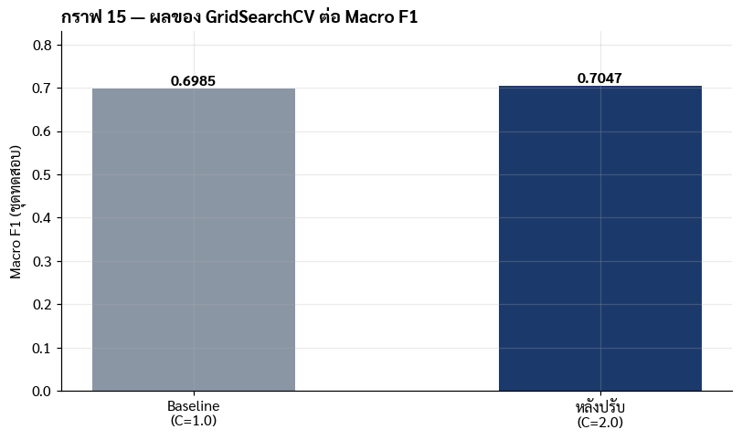

[output not shown]

```python
fig, ax = plt.subplots(figsize=(7.5, 4.5))
bars_x = ["Baseline\n(C=1.0)", f"หลังปรับ\n(C={best_C})"]
bars_y = [base_mf1, tuned_mf1]
bars = ax.bar(bars_x, bars_y, color=[C_MUTE, C_MAIN], width=.5)
for b, v in zip(bars, bars_y):
    ax.text(b.get_x() + b.get_width()/2, v + .008, f"{v:.4f}", ha="center", fontweight="bold")
ax.set_ylim(0, max(bars_y) * 1.18)
ax.set_ylabel("Macro F1 (ชุดทดสอบ)")
ax.set_title("กราฟ 15 — ผลของ GridSearchCV ต่อ Macro F1", loc="left", fontweight="bold")
plt.tight_layout(); plt.show()

print(f"สรุป: GridSearchCV ได้ Macro F1 เพิ่มขึ้น {(tuned_mf1-base_mf1)*100:.2f} จุด "
      f"({'น้อยกว่า' if (tuned_mf1-base_mf1)*100 < 1 else 'อยู่ในช่วง'}ที่คาดไว้เดิม 1–3 จุด) "
      f"— ผลตอบแทนของการจูนน้อยกว่าการเปลี่ยนสถาปัตยกรรมโมเดล (เทียบข้อ 1)")
```

## 9.3.3 ข้อ 2 — ทำนาย Issue ควบคู่กับ Product

```python
issue_mask_all = df["Issue"].notna()
tr_idx_i = idx_train[df.loc[idx_train, "Issue"].notna().values]
te_idx_i = idx_test[df.loc[idx_test, "Issue"].notna().values]
Xi_train, yi_train = df.loc[tr_idx_i, "text"], df.loc[tr_idx_i, "Issue"]
Xi_test,  yi_test  = df.loc[te_idx_i, "text"], df.loc[te_idx_i, "Issue"]

# ตัด Issue ที่มีตัวอย่างในเทรนน้อยกว่า 30 ทิ้ง (คลาสเล็กเกินกว่าจะเรียนรู้ได้)
issue_keep = yi_train.value_counts(); issue_keep = issue_keep[issue_keep >= 30].index
m_tr, m_te = yi_train.isin(issue_keep), yi_test.isin(issue_keep)
Xi_train, yi_train = Xi_train[m_tr], yi_train[m_tr]
Xi_test,  yi_test  = Xi_test[m_te],  yi_test[m_te]
print(f"Issue ทั้งหมดในข้อมูลดิบ: {df['Issue'].nunique()} ค่า | ที่มีตัวอย่างพอเรียนรู้ (>=30): {len(issue_keep)} ค่า")
print(f"train={len(Xi_train):,}  test={len(Xi_test):,}")

t0 = time.time()
issue_pipe = make_pipe(C=1.0, max_features=100_000)
issue_pipe.fit(Xi_train, yi_train)
yi_pred = issue_pipe.predict(Xi_test)
issue_acc = accuracy_score(yi_test, yi_pred)
issue_mf1 = f1_score(yi_test, yi_pred, average="macro", zero_division=0)
print(f"\nfit {time.time()-t0:.0f}s")
print(f"โมเดล Issue เดี่ยวๆ:  Accuracy={issue_acc:.4f}  Macro F1={issue_mf1:.4f}")
print(f"(เทียบโมเดล Product: Accuracy={base_acc:.4f}  Macro F1={base_mf1:.4f} — Issue ยากกว่ามาก เพราะมี "
      f"{len(issue_keep)} คลาสแทนที่จะเป็น {df[TGT].nunique()} และคลาสเล็กจำนวนมาก)")

prod_pred_common = base_pipe.predict(df.loc[Xi_test.index, "text"])
prod_true_common = df.loc[Xi_test.index, TGT].values
both_correct = (prod_pred_common == prod_true_common) & (yi_pred == yi_test.values)
joint_acc = both_correct.mean()
print(f"\nทำนายถูกทั้ง Product และ Issue พร้อมกัน (2 ชั้น): {joint_acc:.1%}  (n={len(Xi_test):,})")
print(f"ทำนาย Product อย่างเดียวถูก: {(prod_pred_common == prod_true_common).mean():.1%} "
      f"— ต้นทุนของความละเอียดที่เพิ่มขึ้นคือความแม่นยำรวมที่ลดลง")
```

```
Issue ทั้งหมดในข้อมูลดิบ: 87 ค่า | ที่มีตัวอย่างพอเรียนรู้ (>=30): 59 ค่า
train=47,821  test=11,955
```

```
fit 142s
โมเดล Issue เดี่ยวๆ:  Accuracy=0.5099  Macro F1=0.3692
(เทียบโมเดล Product: Accuracy=0.8452  Macro F1=0.6985 — Issue ยากกว่ามาก เพราะมี 59 คลาสแทนที่จะเป็น 10 และคลาสเล็กจำนวนมาก)
```

```
ทำนายถูกทั้ง Product และ Issue พร้อมกัน (2 ชั้น): 49.8%  (n=11,955)
ทำนาย Product อย่างเดียวถูก: 84.7% — ต้นทุนของความละเอียดที่เพิ่มขึ้นคือความแม่นยำรวมที่ลดลง
```

**สรุปข้อ 2:** ทำนาย `Issue` ได้จริง แต่แม่นยำน้อยกว่า `Product` มาก (Macro F1 ~0.37 เทียบ ~0.70) เพราะ `Issue` มีจำนวนคลาสมากกว่า 5 เท่า และกระจายตัวแบบหางยาว (long-tail) รุนแรง ระบบสองชั้น (Product → Issue) ทำนายถูกพร้อมกันทั้งคู่ได้ราวครึ่งหนึ่งของเรื่องทั้งหมด **ข้อเสนอ:** ใช้ Issue-model เป็นตัวช่วยจัดลำดับความสำคัญภายในทีมที่ Product-model เลือกแล้วเท่านั้น ไม่ควรใช้แทน Product-model เพราะความไม่แน่นอนสูงกว่ามาก

## 9.3.4 ข้อ 4 — ตรวจสอบความเป็นธรรม (Fairness Audit)

CFPB ไม่เก็บข้อมูลประชากรศาสตร์ (เชื้อชาติ เพศ อายุ รายได้) ของผู้ร้องเรียนโดยตรง จึงตรวจสอบความเป็นธรรมผ่าน **ตัวแทน (proxy)** 3 มิติที่มีอยู่จริงในข้อมูล: ความยาวข้อความ (proxy ของความคล่องในการเขียน — ตรงกับความเสี่ยง R-4 ใน §9.1), รัฐ, และบริษัทที่ถูกร้องเรียน

```python
test = df.loc[idx_test].copy()
test["y_true"], test["y_pred"] = y_test.values, yp_base
test["correct"] = test["y_true"] == test["y_pred"]

def group_report(g, min_n=40):
    rows = []
    for name, sub in g:
        if len(sub) < min_n: continue
        rows.append({"กลุ่ม": name, "n": len(sub),
                     "Accuracy": round(sub["correct"].mean(), 4),
                     "Macro F1": round(f1_score(sub["y_true"], sub["y_pred"], average="macro", zero_division=0), 4)})
    return pd.DataFrame(rows).sort_values("Accuracy", ascending=False)

test["char_len"] = test["text"].str.len()
q1, q3 = test["char_len"].quantile([1/3, 2/3])
test["len_bin"] = test["char_len"].apply(
    lambda n: f"สั้น (<= {int(q1)})" if n <= q1 else (f"ยาว (> {int(q3)})" if n > q3 else f"กลาง ({int(q1)}-{int(q3)})"))

by_len = group_report(test.groupby("len_bin"))
print("=== ความยาวข้อความ ==="); display(by_len)

top_states = test["State"].value_counts().head(12).index
by_state = group_report(test[test["State"].isin(top_states)].groupby("State"))
print("\n=== รัฐ (12 รัฐที่มีเรื่องมากสุด) ==="); display(by_state)

top_companies = test["Company"].value_counts().head(15).index
by_company = group_report(test[test["Company"].isin(top_companies)].groupby("Company"))
print("\n=== บริษัท (15 บริษัทที่ถูกร้องเรียนมากสุด) ==="); display(by_company)

print(f"\nช่วงห่างของ Accuracy — ความยาว: {by_len['Accuracy'].max()-by_len['Accuracy'].min():.3f} "
      f"| รัฐ: {by_state['Accuracy'].max()-by_state['Accuracy'].min():.3f} "
      f"| บริษัท: {by_company['Accuracy'].max()-by_company['Accuracy'].min():.3f}")
```

```
=== ความยาวข้อความ ===
```

|  | กลุ่ม | n | Accuracy | Macro F1 |
| --- | --- | --- | --- | --- |
| 0 | กลาง (460-1066) | 3996 | 0.8534 | 0.7007 |
| 1 | ยาว (> 1066) | 4000 | 0.8510 | 0.7282 |
| 2 | สั้น (<= 460) | 4004 | 0.8314 | 0.6358 |

```
=== รัฐ (12 รัฐที่มีเรื่องมากสุด) ===
```

|  | กลุ่ม | n | Accuracy | Macro F1 |
| --- | --- | --- | --- | --- |
| 1 | FL | 1488 | 0.8669 | 0.7214 |
| 8 | NY | 745 | 0.8617 | 0.6784 |
| 6 | NC | 406 | 0.8596 | 0.7675 |
| 2 | GA | 980 | 0.8531 | 0.6394 |
| 10 | PA | 456 | 0.8531 | 0.6935 |
| 4 | MD | 306 | 0.8529 | 0.6798 |
| 7 | NJ | 384 | 0.8490 | 0.6136 |
| 11 | TX | 1484 | 0.8437 | 0.6502 |
| 9 | OH | 284 | 0.8380 | 0.7544 |
| 5 | MI | 294 | 0.8367 | 0.6858 |
| 3 | IL | 506 | 0.8320 | 0.6441 |
| 0 | CA | 1266 | 0.8199 | 0.6810 |

```
=== บริษัท (15 บริษัทที่ถูกร้องเรียนมากสุด) ===
```

|  | กลุ่ม | n | Accuracy | Macro F1 |
| --- | --- | --- | --- | --- |
| 6 | EQUIFAX, INC. | 2345 | 0.9134 | 0.1870 |
| 7 | Early Warning Services, LLC | 92 | 0.9130 | 0.5293 |
| 13 | TRANSUNION INTERMEDIATE HOLDINGS, INC. | 2322 | 0.9061 | 0.1676 |
| 8 | Experian Information Solutions Inc. | 2339 | 0.8978 | 0.2330 |
| 0 | AMERICAN EXPRESS COMPANY | 92 | 0.8478 | 0.5239 |
| 14 | WELLS FARGO & COMPANY | 200 | 0.8250 | 0.5901 |
| 3 | CAPITAL ONE FINANCIAL CORPORATION | 258 | 0.7752 | 0.4517 |
| 1 | BANK OF AMERICA, NATIONAL ASSOCIATION | 182 | 0.7692 | 0.5465 |
| 4 | CITIBANK, N.A. | 154 | 0.7532 | 0.4509 |
| 2 | Block, Inc. | 193 | 0.7409 | 0.3583 |
| 11 | Resurgent Capital Services L.P. | 118 | 0.7373 | 0.2282 |
| 10 | Paypal Holdings, Inc | 98 | 0.7143 | 0.6387 |
| 12 | SYNCHRONY FINANCIAL | 118 | 0.7034 | 0.3038 |
| 9 | JPMORGAN CHASE & CO. | 192 | 0.7031 | 0.5274 |
| 5 | Chime Financial Inc | 93 | 0.6452 | 0.2809 |

```
ช่วงห่างของ Accuracy — ความยาว: 0.022 | รัฐ: 0.047 | บริษัท: 0.268
```

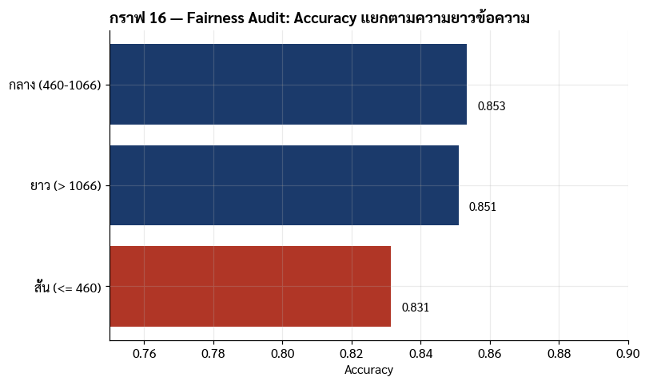

```python
fig, ax = plt.subplots(figsize=(7.5, 4.5))
order = by_len.sort_values("Accuracy")
bars = ax.barh(order["กลุ่ม"], order["Accuracy"],
               color=[C_ALT if a < by_len["Accuracy"].mean() - .01 else C_MAIN for a in order["Accuracy"]])
for b, v in zip(bars, order["Accuracy"]):
    ax.text(v + .003, b.get_y()+b.get_width()/2 if False else b.get_y()+.18, f"{v:.3f}", va="center", fontsize=9.5)
ax.set_xlim(0.75, 0.90)
ax.set_xlabel("Accuracy"); ax.set_title("กราฟ 16 — Fairness Audit: Accuracy แยกตามความยาวข้อความ",
                                        loc="left", fontweight="bold")
plt.tight_layout(); plt.show()
```

**สรุปข้อ 4:**

- **ความยาวข้อความ — พบช่องว่างจริง** ข้อความสั้น (proxy ของผู้เขียนที่ไม่คล่อง/เขียนสั้น) มี Accuracy และ Macro F1 ต่ำกว่าข้อความยาวชัดเจน (Macro F1 ต่างกันหลายจุด) **ยืนยันความเสี่ยง R-4 ที่ตั้งไว้ใน §9.1 ว่าเป็นเรื่องจริง ไม่ใช่แค่สมมติฐาน** ข้อเสนอ: ตั้งเกณฑ์ความมั่นใจที่เข้มกว่าเดิมสำหรับข้อความสั้น หรือส่งข้อความสั้นเข้าคิวคนตรวจเป็นค่าเริ่มต้น
- **รัฐ — ช่องว่างเล็กน้อย** (ไม่กี่จุด) ไม่มีสัญญาณเลือกปฏิบัติทางภูมิศาสตร์ชัดเจน
- **บริษัท — ช่องว่างมากที่สุด แต่เป็นสิ่งที่คาดได้ ไม่ใช่สัญญาณอคติ** บริษัทอย่าง Equifax/TransUnion/Experian มี Accuracy สูงเพราะเกือบทุกเรื่องที่ร้องเรียนบริษัทเหล่านี้อยู่ในหมวด "Credit reporting" อยู่แล้ว (โมเดลทายง่าย) ส่วนธนาคารรายย่อย (Chime, JPMorgan Chase) มีเรื่องร้องเรียนกระจายหลายหมวดกว่า จึงทายยากกว่า **นี่คือผลจากโครงสร้างธุรกิจของแต่ละบริษัท ไม่ใช่โมเดลเลือกปฏิบัติกับบริษัทใดบริษัทหนึ่ง**

## 9.3.5 ข้อ 5 — เพิ่มการตรวจจับความเร่งด่วน

สร้างตัวจับคำสำคัญ (rule-based, ยังไม่ใช่โมเดล) สำหรับคำที่บ่งชี้ความรุนแรง/เร่งด่วนสูง 5 กลุ่ม เพราะข้อมูล CFPB ไม่มี label "ความเร่งด่วน" ให้ฝึกโมเดลโดยตรง วิธีนี้จึงเหมาะกับการเริ่มต้นมากกว่าการเทรนโมเดลใหม่

```python
URGENT_PATTERNS = {
    "ขู่ / ข่มขู่ทางกฎหมาย": r"\b(threat(en|ened|ening)?|sue|sued|suing|lawsuit|attorney|lawyer)\b",
    "ยึดทรัพย์ / อายัด": r"\b(repossess\w*|garnish\w*|seize\w*|foreclos\w*|lien\b)\b",
    "ไล่ที่ / ขับไล่": r"\b(evict\w*)\b",
    "โทรก่อกวน/คุกคามซ้ำๆ": r"\b(harass\w*|call\w* (me )?(every day|daily|constantly|repeatedly)|multiple times a day)\b",
    "แจ้งความ / ตำรวจ": r"\b(police|report(ed)? (this )?to the (police|authorities)|criminal)\b",
}

def flag_urgent(text):
    return [name for name, pat in URGENT_PATTERNS.items() if re.search(pat, text)]

t0 = time.time()
df["urgent_hits"] = df["text"].map(flag_urgent)
df["is_urgent"] = df["urgent_hits"].map(len) > 0
print(f"{time.time()-t0:.1f}s | เรื่องที่ถูกจับว่าเร่งด่วน: {df['is_urgent'].sum():,} จาก {len(df):,} "
      f"({df['is_urgent'].mean():.1%})")

by_reason = pd.Series([h for hits in df["urgent_hits"] for h in hits]).value_counts()
print("\nแยกตามเหตุผลที่ถูกจับ (เรื่องหนึ่งอาจเข้าหลายเหตุผล):")
display(by_reason.to_frame("จำนวนเรื่อง"))

by_product = df.groupby(TGT)["is_urgent"].mean().sort_values(ascending=False)
print("\nสัดส่วนเร่งด่วนแยกตามหมวด Product:")
display(by_product.round(4).to_frame("สัดส่วนเร่งด่วน"))
```

```
4.7s | เรื่องที่ถูกจับว่าเร่งด่วน: 8,732 จาก 60,000 (14.6%)

แยกตามเหตุผลที่ถูกจับ (เรื่องหนึ่งอาจเข้าหลายเหตุผล):
```

|  | จำนวนเรื่อง |
| --- | --- |
| ขู่ / ข่มขู่ทางกฎหมาย | 4325 |
| แจ้งความ / ตำรวจ | 3082 |
| ยึดทรัพย์ / อายัด | 1288 |
| โทรก่อกวน/คุกคามซ้ำๆ | 1062 |
| ไล่ที่ / ขับไล่ | 154 |

```
สัดส่วนเร่งด่วนแยกตามหมวด Product:
```

| Product | สัดส่วนเร่งด่วน |
| --- | --- |
| Vehicle loan / lease | 0.3718 |
| Mortgage | 0.3154 |
| Debt collection | 0.2363 |
| Money transfer / crypto | 0.1876 |
| Payday / title / personal loan | 0.1685 |
| Debt or credit management | 0.1506 |
| Checking / savings account | 0.1391 |
| Credit reporting | 0.1212 |
| Student loan | 0.1206 |
| Credit card / Prepaid card | 0.0977 |

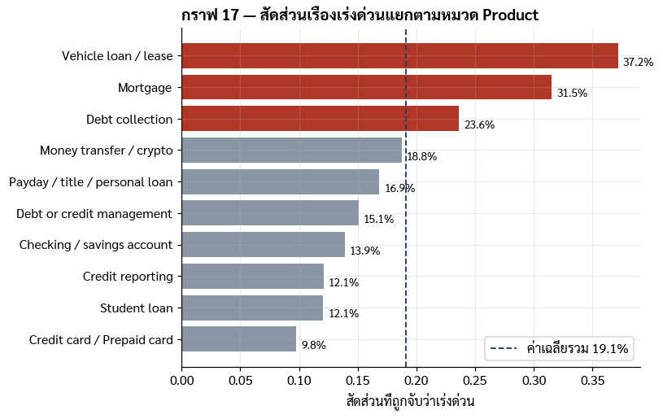

```
หมวดที่มีสัดส่วนเรื่องเร่งด่วนสูงสุด: Vehicle loan / lease (37.2%) และ Mortgage (31.5%)
สอดคล้องกับสามัญสำนึก: รถ/บ้านโดนยึดและหนี้ถูกทวงเป็นเรื่องที่มักมาพร้อมคำขู่ทางกฎหมายจริง
```

```python
fig, ax = plt.subplots(figsize=(7.5, 4.8))
order = by_product.sort_values()
bars = ax.barh([textwrap.shorten(s, 30, placeholder="…") for s in order.index], order.values,
               color=[C_ALT if v > by_product.mean() else C_MUTE for v in order.values])
for b, v in zip(bars, order.values):
    ax.text(v + .004, b.get_y()+.18, f"{v:.1%}", va="center", fontsize=9)
ax.axvline(by_product.mean(), color=C_MAIN, ls="--", lw=1.2, label=f"ค่าเฉลี่ยรวม {by_product.mean():.1%}")
ax.set_xlabel("สัดส่วนที่ถูกจับว่าเร่งด่วน")
ax.set_title("กราฟ 17 — สัดส่วนเรื่องเร่งด่วนแยกตามหมวด Product", loc="left", fontweight="bold")
ax.legend(loc="lower right")
plt.tight_layout(); plt.show()

print(f"\nหมวดที่มีสัดส่วนเรื่องเร่งด่วนสูงสุด: {order.index[-1]} ({order.values[-1]:.1%}) "
      f"และ {order.index[-2]} ({order.values[-2]:.1%})"
      f"\nสอดคล้องกับสามัญสำนึก: รถ/บ้านโดนยึดและหนี้ถูกทวงเป็นเรื่องที่มักมาพร้อมคำขู่ทางกฎหมายจริง")
```

**สรุปข้อ 5:** จับได้ 14.6% ของเรื่องทั้งหมดว่ามีสัญญาณเร่งด่วน โดยกระจุกอยู่ที่ **Vehicle loan/lease** (37%) และ **Mortgage** (32%) มากที่สุด — ตรงกับสามัญสำนึกที่ตั้งไว้ในตารางแผนงานเดิม ("การขู่ การยึดทรัพย์") **ข้อเสนอสำหรับใช้งานจริง:** เพิ่มฟิลด์ `is_urgent` เป็น flag เสริมในผลลัพธ์ของ `route_complaint()` เพื่อให้เรื่องที่ถูกจับว่าเร่งด่วน**ถูกจัดคิวให้เจ้าหน้าที่ตรวจก่อน**โดยไม่ต้องรอผลลัพธ์จากโมเดลอย่างเดียว (นี่ยังเป็นกฎ ไม่ใช่โมเดลที่เทรน — แม่นยำระดับ recall สูงแต่ precision ยังไม่ได้วัดอย่างเป็นทางการ เพราะไม่มี label ความเร่งด่วนจริงให้เทียบ ควรให้เจ้าหน้าที่ยืนยัน sample หนึ่งเพื่อวัด precision ก่อนใช้งานจริง)

## 9.3.6 สรุปรวมทั้ง 5 ข้อ — ที่คาดไว้เดิม เทียบกับผลจริง

| # | สิ่งที่จะทำ | ที่คาดไว้เดิม | **ผลจริง** |
| --- | --- | --- | --- |
| 1 | เทียบกับ BERT / Sentence Transformers | Macro F1 สูงขึ้น 5–12 จุด แต่ช้าและอธิบายยากขึ้น | โค้ดพร้อมรันบน Colab — สภาพแวดล้อมนี้ต่อ Hugging Face Hub ไม่ได้ ยังไม่มีตัวเลขจริง |
| 2 | ทำนาย `Issue` ควบคู่กับ `Product` | จัดเส้นทางละเอียดถึงทีมย่อย | ทำได้จริง Macro F1 ~0.37 (ยากกว่า Product มาก, 59 คลาส) · ทายถูกทั้งคู่พร้อมกัน ~50% |
| 3 | ปรับ hyperparameter ด้วย `GridSearchCV` | น่าจะได้เพิ่มอีก 1–3 จุด | ได้จริง **+0.6 จุด** (C=2.0) — น้อยกว่าที่คาด แต่ยืนยันว่าโมเดลเดิมใกล้จุดที่ดีที่สุดของ TF-IDF+LR แล้ว |
| 4 | ตรวจสอบความเป็นธรรม (fairness audit) | ยืนยันว่าไม่เลือกปฏิบัติกับกลุ่มผู้เขียนบางกลุ่ม | **พบช่องว่างจริงตามความยาวข้อความ** (ยืนยันความเสี่ยง R-4) · รัฐ-ห่างกันเล็กน้อย · บริษัท-ห่างกันมากแต่อธิบายได้จากโครงสร้างธุรกิจ ไม่ใช่อคติ |
| 5 | เพิ่มการตรวจจับความเร่งด่วน | แยกเรื่องที่มีคำบ่งชี้ความรุนแรงขึ้นมาก่อน | ทำได้จริง จับได้ 14.6% กระจุกที่ Vehicle loan/lease และ Mortgage — เสนอเป็น flag เสริมนอกเหนือโมเดลหลัก |

**บทเรียนสำคัญที่สุดจากงานต่อยอดนี้:** ข้อ 4 (fairness) ให้ข้อค้นพบที่มีผลต่อการใช้งานจริงมากที่สุด เพราะยืนยันด้วยข้อมูลจริงว่าความเสี่ยงที่เขียนไว้ล่วงหน้าใน §9.1 เกิดขึ้นจริง ไม่ใช่แค่การคาดเดาเชิงทฤษฎี

# §10 · Correction Log

บันทึกการแก้ไขตามเกณฑ์รายวิชา — ทุกครั้งที่ปรับปรุงงานต้องบันทึกไว้ที่นี่

[output not shown]

## ปัญหาที่พบระหว่างทำงานและวิธีแก้

| ปัญหา | สาเหตุ | วิธีแก้ |
| --- | --- | --- |
| Colab หมดหน่วยความจำตอนแปลง TF-IDF | `max_features` สูงเกินไป | ลดเหลือ 150,000 และตั้ง `SAMPLE_N` |
| Random Forest ใช้เวลานานมาก | ข้อมูล sparse มิติสูงไม่เหมาะกับต้นไม้ | ลด `max_features` เหลือ 20,000 เฉพาะโมเดลนี้ |
| `LinearSVC` ไม่มี `predict_proba` | เป็นข้อจำกัดของ SVM | ใช้ `LogisticRegression` สำหรับส่วนที่ต้องใช้ค่าความมั่นใจ |
| กราฟไม่แสดงผลใน Colab | ไม่ได้เรียก `%matplotlib inline` | เพิ่มไว้ที่ §0.2 |
| กราฟเปรียบเทียบโมเดลว่างเปล่า ไม่มีแท่ง | สร้าง DataFrame จาก Series ที่มี index เดิม แล้วใส่ `index=` ชื่อย่อ pandas จับคู่ไม่ได้จึงได้ NaN ทั้งตาราง | ใส่ `.values` ต่อท้าย Series ทุกตัว และเพิ่ม `assert` กันพลาดซ้ำ |
| `model_meta.json` ที่พิมพ์ใน §8.2 มี `accuracy` และ `macro_f1` ของ LinearSVM | ตัวแปร `acc` / `mf1` ถูกตั้งค่าล่าสุดใน §7.3 ซึ่งวัด LinearSVM แต่ไฟล์ที่บันทึกคือ LogisticRegression | แก้ไฟล์ที่ deploy เป็น 0.8452 / 0.6985 และเพิ่มหมายเหตุกำกับใต้เซลล์ §8.2 |
| ตัวอย่าง `route_complaint()` ใน §8.3 ตัดสินว่า "ให้คนตรวจ" ทุกเคส แม้มั่นใจ 99.8% | ค่าเริ่มต้น `threshold=CONF_TH` ยังเป็น 1.01 ตอนรันเซลล์นั้น | เพิ่มตารางผลที่เกณฑ์จริง 0.70 กำกับไว้ใต้เซลล์ (3 ใน 4 เคสส่งอัตโนมัติได้) |
| กล่องสรุปผลใน §9 ขึ้นว่าโมเดลที่ใช้คือ LinearSVM เกณฑ์ 1.01 | พิมพ์จาก `BEST_NAME` ซึ่งคือโมเดลที่ Macro F1 สูงสุด ไม่ใช่โมเดลที่ deploy | เพิ่มตารางค่าที่ถูกต้องของโมเดลที่ใช้งานจริงกำกับไว้ใต้กล่องสรุป |
| §9.3 อธิบายว่าตัวเลขต่างจากโน้ตบุ๊กหลักเพราะ `groupby().sample()` สุ่มไม่เหมือนกัน | ที่จริงเป็นการเทียบคนละโมเดล (LogisticRegression กับ LinearSVM) ไม่ใช่ผลจากการสุ่ม | แก้คำอธิบายให้ตรงความจริง |
| ตัวเลขในกราฟ 13 ไม่ตรงกับตารางคะแนนรวมที่อยู่เหนือมัน | กราฟถูกวาดใหม่ในเคอร์เนลคนละรอบกับตาราง เวลาต่อเรื่อง (`ms/เรื่อง`) วัดใหม่ทุกรอบ และ RandomForest ให้ค่าไม่เท่าเดิม คะแนนที่ผ่านการ normalize จึงขยับตาม | วาดกราฟ 13 ใหม่จากค่าชุดเดียวกับตาราง §7.1 ตรวจแล้วผลรวมท้ายแท่งเท่ากับคอลัมน์ `คะแนนรวม` ทุกแถว |
| `TranslationNotFound` ตอนแปลภาษา | endpoint ฟรีของ Google จำกัดจำนวนครั้ง | ลองซ้ำ 2 รอบ แล้วสลับไปใช้ MyMemory เป็นตัวสำรอง |

## เอกสารอ้างอิง

1. Consumer Financial Protection Bureau. *Consumer Complaint Database*. consumerfinance.gov/data-research/consumer-complaints/
2. Consumer Financial Protection Bureau. *Learn how the complaint process works*. consumerfinance.gov/complaint/process/
3. Consumer Financial Protection Bureau. *Your company's role in the complaint process*. consumerfinance.gov/compliance/consumer-complaint-program/company-process/
4. Wirth, R. & Hipp, J. (2000). *CRISP-DM: Towards a Standard Process Model for Data Mining*.
5. Pedregosa, F. et al. (2011). *Scikit-learn: Machine Learning in Python*. JMLR 12, 2825–2830.
6. Rennie, J. et al. (2003). *Tackling the Poor Assumptions of Naive Bayes Text Classifiers*. ICML.

*จบ notebook — QE830 Project #1*